# PROJET ECOMMERCE

## ToC

**1. Preparation et Nettoyage**

- Chargement des données
- Les données manquantes
- Les données dupliquées
- Types de données
- Fonction de nettoyage
- Creation du master

**2. Analyse Exploratoire**

**3. Feature Engineering**

**4. Transformation pour ML**

- 4.1. PCA sur product category
- 4.2. Scaling des features numériques
- 4.3. Export

**5. Machine Learning**

- 5.1. K-Means Analysis
- 5.2. t-SNE Visualisation
- 5.3. DBScan
- 5.4. Cluster Characteristics
- 5.5. Etude de Sensibilité temporelle

# Chargement des données

```python
import pandas as pd
import seaborn as sns
import matplotlib.pyplot as plt
import folium
from random import sample
from folium.plugins import HeatMap
from EDA_utils import *
from matplotlib.gridspec import GridSpec
pd.options.mode.chained_assignment = None  # default='warn'
pd.set_option('display.max_columns', None)
```

```python
filepath_1 = "/Users/efkanturedi/Corteze/my_py3/03_E_commerce/Input/olist_customers_dataset.csv"
filepath_2 = "/Users/efkanturedi/Corteze/my_py3/03_E_commerce/Input/olist_geolocation_dataset.csv"
filepath_3 = "/Users/efkanturedi/Corteze/my_py3/03_E_commerce/Input/olist_order_items_dataset.csv"
filepath_4 = "/Users/efkanturedi/Corteze/my_py3/03_E_commerce/Input/olist_order_payments_dataset.csv"
filepath_5 = "/Users/efkanturedi/Corteze/my_py3/03_E_commerce/Input/olist_order_reviews_dataset.csv"
filepath_6 = "/Users/efkanturedi/Corteze/my_py3/03_E_commerce/Input/olist_orders_dataset.csv"
filepath_7 = "/Users/efkanturedi/Corteze/my_py3/03_E_commerce/Input/olist_products_dataset.csv"
filepath_8 = "/Users/efkanturedi/Corteze/my_py3/03_E_commerce/Input/olist_sellers_dataset.csv"
filepath_9 = "/Users/efkanturedi/Corteze/my_py3/03_E_commerce/Input/product_category_name_translation.csv"


#filepath_1 = "/home/et/Mytest/my_py3/03_E_commerce/Input/olist_customers_dataset.csv"
#filepath_2 = "/home/et/Mytest/my_py3/03_E_commerce/Input/olist_geolocation_dataset.csv"
#filepath_3 = "/home/et/Mytest/my_py3/03_E_commerce/Input/olist_order_items_dataset.csv"
#filepath_4 = "/home/et/Mytest/my_py3/03_E_commerce/Input/olist_order_payments_dataset.csv"
#filepath_5 = "/home/et/Mytest/my_py3/03_E_commerce/Input/olist_order_reviews_dataset.csv"
#filepath_6 = "/home/et/Mytest/my_py3/03_E_commerce/Input/olist_orders_dataset.csv"
#filepath_7 = "/home/et/Mytest/my_py3/03_E_commerce/Input/olist_products_dataset.csv"
#filepath_8 = "/home/et/Mytest/my_py3/03_E_commerce/Input/olist_sellers_dataset.csv"
#filepath_9 = "/home/et/Mytest/my_py3/03_E_commerce/Input/product_category_name_translation.csv"
```

```python
customers = pd.read_csv(filepath_1);
geolocation = pd.read_csv(filepath_2)
order_items = pd.read_csv(filepath_3);
order_payments = pd.read_csv(filepath_4)
order_reviews = pd.read_csv(filepath_5)
orders = pd.read_csv(filepath_6)
products = pd.read_csv(filepath_7)
sellers = pd.read_csv(filepath_8)
product_category_name_translation = pd.read_csv(filepath_9)
```

```python
customersX = customers.copy(deep=True);
geolocationX = geolocation.copy(deep=True)
order_itemsX = order_items.copy(deep=True)
order_paymentsX = order_payments.copy(deep=True)
order_reviewsX = order_reviews.copy(deep=True)
ordersX = orders.copy(deep=True)
productsX = products.copy(deep=True)
sellersX = sellers.copy(deep=True)
product_category_name_translationX = product_category_name_translation.copy(deep=True)
```

```python
customers
```

|  | customer_id | customer_unique_id | customer_zip_code_prefix | customer_city | customer_state |
| --- | --- | --- | --- | --- | --- |
| 0 | 06b8999e2fba1a1fbc88172c00ba8bc7 | 861eff4711a542e4b93843c6dd7febb0 | 14409 | franca | SP |
| 1 | 18955e83d337fd6b2def6b18a428ac77 | 290c77bc529b7ac935b93aa66c333dc3 | 9790 | sao bernardo do campo | SP |
| 2 | 4e7b3e00288586ebd08712fdd0374a03 | 060e732b5b29e8181a18229c7b0b2b5e | 1151 | sao paulo | SP |
| 3 | b2b6027bc5c5109e529d4dc6358b12c3 | 259dac757896d24d7702b9acbbff3f3c | 8775 | mogi das cruzes | SP |
| 4 | 4f2d8ab171c80ec8364f7c12e35b23ad | 345ecd01c38d18a9036ed96c73b8d066 | 13056 | campinas | SP |
| ... | ... | ... | ... | ... | ... |
| 99436 | 17ddf5dd5d51696bb3d7c6291687be6f | 1a29b476fee25c95fbafc67c5ac95cf8 | 3937 | sao paulo | SP |
| 99437 | e7b71a9017aa05c9a7fd292d714858e8 | d52a67c98be1cf6a5c84435bd38d095d | 6764 | taboao da serra | SP |
| 99438 | 5e28dfe12db7fb50a4b2f691faecea5e | e9f50caf99f032f0bf3c55141f019d99 | 60115 | fortaleza | CE |
| 99439 | 56b18e2166679b8a959d72dd06da27f9 | 73c2643a0a458b49f58cea58833b192e | 92120 | canoas | RS |
| 99440 | 274fa6071e5e17fe303b9748641082c8 | 84732c5050c01db9b23e19ba39899398 | 6703 | cotia | SP |

99441 rows × 5 columns

```python
geolocation
```

|  | geolocation_zip_code_prefix | geolocation_lat | geolocation_lng | geolocation_city | geolocation_state |
| --- | --- | --- | --- | --- | --- |
| 0 | 1037 | -23.545621 | -46.639292 | sao paulo | SP |
| 1 | 1046 | -23.546081 | -46.644820 | sao paulo | SP |
| 2 | 1046 | -23.546129 | -46.642951 | sao paulo | SP |
| 3 | 1041 | -23.544392 | -46.639499 | sao paulo | SP |
| 4 | 1035 | -23.541578 | -46.641607 | sao paulo | SP |
| ... | ... | ... | ... | ... | ... |
| 1000158 | 99950 | -28.068639 | -52.010705 | tapejara | RS |
| 1000159 | 99900 | -27.877125 | -52.224882 | getulio vargas | RS |
| 1000160 | 99950 | -28.071855 | -52.014716 | tapejara | RS |
| 1000161 | 99980 | -28.388932 | -51.846871 | david canabarro | RS |
| 1000162 | 99950 | -28.070104 | -52.018658 | tapejara | RS |

1000163 rows × 5 columns

```python
len(geolocation[['geolocation_lng','geolocation_lat']])
```

```
1000163
```

```python
order_items
```

|  | order_id | order_item_id | product_id | seller_id | shipping_limit_date | price | freight_value |
| --- | --- | --- | --- | --- | --- | --- | --- |
| 0 | 00010242fe8c5a6d1ba2dd792cb16214 | 1 | 4244733e06e7ecb4970a6e2683c13e61 | 48436dade18ac8b2bce089ec2a041202 | 2017-09-19 09:45:35 | 58.90 | 13.29 |
| 1 | 00018f77f2f0320c557190d7a144bdd3 | 1 | e5f2d52b802189ee658865ca93d83a8f | dd7ddc04e1b6c2c614352b383efe2d36 | 2017-05-03 11:05:13 | 239.90 | 19.93 |
| 2 | 000229ec398224ef6ca0657da4fc703e | 1 | c777355d18b72b67abbeef9df44fd0fd | 5b51032eddd242adc84c38acab88f23d | 2018-01-18 14:48:30 | 199.00 | 17.87 |
| 3 | 00024acbcdf0a6daa1e931b038114c75 | 1 | 7634da152a4610f1595efa32f14722fc | 9d7a1d34a5052409006425275ba1c2b4 | 2018-08-15 10:10:18 | 12.99 | 12.79 |
| 4 | 00042b26cf59d7ce69dfabb4e55b4fd9 | 1 | ac6c3623068f30de03045865e4e10089 | df560393f3a51e74553ab94004ba5c87 | 2017-02-13 13:57:51 | 199.90 | 18.14 |
| ... | ... | ... | ... | ... | ... | ... | ... |
| 112645 | fffc94f6ce00a00581880bf54a75a037 | 1 | 4aa6014eceb682077f9dc4bffebc05b0 | b8bc237ba3788b23da09c0f1f3a3288c | 2018-05-02 04:11:01 | 299.99 | 43.41 |
| 112646 | fffcd46ef2263f404302a634eb57f7eb | 1 | 32e07fd915822b0765e448c4dd74c828 | f3c38ab652836d21de61fb8314b69182 | 2018-07-20 04:31:48 | 350.00 | 36.53 |
| 112647 | fffce4705a9662cd70adb13d4a31832d | 1 | 72a30483855e2eafc67aee5dc2560482 | c3cfdc648177fdbbbb35635a37472c53 | 2017-10-30 17:14:25 | 99.90 | 16.95 |
| 112648 | fffe18544ffabc95dfada21779c9644f | 1 | 9c422a519119dcad7575db5af1ba540e | 2b3e4a2a3ea8e01938cabda2a3e5cc79 | 2017-08-21 00:04:32 | 55.99 | 8.72 |
| 112649 | fffe41c64501cc87c801fd61db3f6244 | 1 | 350688d9dc1e75ff97be326363655e01 | f7ccf836d21b2fb1de37564105216cc1 | 2018-06-12 17:10:13 | 43.00 | 12.79 |

112650 rows × 7 columns

```python
order_payments
```

|  | order_id | payment_sequential | payment_type | payment_installments | payment_value |
| --- | --- | --- | --- | --- | --- |
| 0 | b81ef226f3fe1789b1e8b2acac839d17 | 1 | credit_card | 8 | 99.33 |
| 1 | a9810da82917af2d9aefd1278f1dcfa0 | 1 | credit_card | 1 | 24.39 |
| 2 | 25e8ea4e93396b6fa0d3dd708e76c1bd | 1 | credit_card | 1 | 65.71 |
| 3 | ba78997921bbcdc1373bb41e913ab953 | 1 | credit_card | 8 | 107.78 |
| 4 | 42fdf880ba16b47b59251dd489d4441a | 1 | credit_card | 2 | 128.45 |
| ... | ... | ... | ... | ... | ... |
| 103881 | 0406037ad97740d563a178ecc7a2075c | 1 | boleto | 1 | 363.31 |
| 103882 | 7b905861d7c825891d6347454ea7863f | 1 | credit_card | 2 | 96.80 |
| 103883 | 32609bbb3dd69b3c066a6860554a77bf | 1 | credit_card | 1 | 47.77 |
| 103884 | b8b61059626efa996a60be9bb9320e10 | 1 | credit_card | 5 | 369.54 |
| 103885 | 28bbae6599b09d39ca406b747b6632b1 | 1 | boleto | 1 | 191.58 |

103886 rows × 5 columns

```python
order_reviews
```

|  | review_id | order_id | review_score | review_comment_title | review_comment_message | review_creation_date | review_answer_timestamp |
| --- | --- | --- | --- | --- | --- | --- | --- |
| 0 | 7bc2406110b926393aa56f80a40eba40 | 73fc7af87114b39712e6da79b0a377eb | 4 | NaN | NaN | 2018-01-18 00:00:00 | 2018-01-18 21:46:59 |
| 1 | 80e641a11e56f04c1ad469d5645fdfde | a548910a1c6147796b98fdf73dbeba33 | 5 | NaN | NaN | 2018-03-10 00:00:00 | 2018-03-11 03:05:13 |
| 2 | 228ce5500dc1d8e020d8d1322874b6f0 | f9e4b658b201a9f2ecdecbb34bed034b | 5 | NaN | NaN | 2018-02-17 00:00:00 | 2018-02-18 14:36:24 |
| 3 | e64fb393e7b32834bb789ff8bb30750e | 658677c97b385a9be170737859d3511b | 5 | NaN | Recebi bem antes do prazo estipulado. | 2017-04-21 00:00:00 | 2017-04-21 22:02:06 |
| 4 | f7c4243c7fe1938f181bec41a392bdeb | 8e6bfb81e283fa7e4f11123a3fb894f1 | 5 | NaN | Parabéns lojas lannister adorei comprar pela I... | 2018-03-01 00:00:00 | 2018-03-02 10:26:53 |
| ... | ... | ... | ... | ... | ... | ... | ... |
| 99995 | f3897127253a9592a73be9bdfdf4ed7a | 22ec9f0669f784db00fa86d035cf8602 | 5 | NaN | NaN | 2017-12-09 00:00:00 | 2017-12-11 20:06:42 |
| 99996 | b3de70c89b1510c4cd3d0649fd302472 | 55d4004744368f5571d1f590031933e4 | 5 | NaN | Excelente mochila, entrega super rápida. Super... | 2018-03-22 00:00:00 | 2018-03-23 09:10:43 |
| 99997 | 1adeb9d84d72fe4e337617733eb85149 | 7725825d039fc1f0ceb7635e3f7d9206 | 4 | NaN | NaN | 2018-07-01 00:00:00 | 2018-07-02 12:59:13 |
| 99998 | be360f18f5df1e0541061c87021e6d93 | f8bd3f2000c28c5342fedeb5e50f2e75 | 1 | NaN | Solicitei a compra de uma capa de retrovisor c... | 2017-12-15 00:00:00 | 2017-12-16 01:29:43 |
| 99999 | efe49f1d6f951dd88b51e6ccd4cc548f | 90531360ecb1eec2a1fbb265a0db0508 | 1 | NaN | meu produto chegou e ja tenho que devolver, po... | 2017-07-03 00:00:00 | 2017-07-03 21:01:49 |

100000 rows × 7 columns

```python
orders
```

|  | order_id | customer_id | order_status | order_purchase_timestamp | order_approved_at | order_delivered_carrier_date | order_delivered_customer_date | order_estimated_delivery_date |
| --- | --- | --- | --- | --- | --- | --- | --- | --- |
| 0 | e481f51cbdc54678b7cc49136f2d6af7 | 9ef432eb6251297304e76186b10a928d | delivered | 2017-10-02 10:56:33 | 2017-10-02 11:07:15 | 2017-10-04 19:55:00 | 2017-10-10 21:25:13 | 2017-10-18 00:00:00 |
| 1 | 53cdb2fc8bc7dce0b6741e2150273451 | b0830fb4747a6c6d20dea0b8c802d7ef | delivered | 2018-07-24 20:41:37 | 2018-07-26 03:24:27 | 2018-07-26 14:31:00 | 2018-08-07 15:27:45 | 2018-08-13 00:00:00 |
| 2 | 47770eb9100c2d0c44946d9cf07ec65d | 41ce2a54c0b03bf3443c3d931a367089 | delivered | 2018-08-08 08:38:49 | 2018-08-08 08:55:23 | 2018-08-08 13:50:00 | 2018-08-17 18:06:29 | 2018-09-04 00:00:00 |
| 3 | 949d5b44dbf5de918fe9c16f97b45f8a | f88197465ea7920adcdbec7375364d82 | delivered | 2017-11-18 19:28:06 | 2017-11-18 19:45:59 | 2017-11-22 13:39:59 | 2017-12-02 00:28:42 | 2017-12-15 00:00:00 |
| 4 | ad21c59c0840e6cb83a9ceb5573f8159 | 8ab97904e6daea8866dbdbc4fb7aad2c | delivered | 2018-02-13 21:18:39 | 2018-02-13 22:20:29 | 2018-02-14 19:46:34 | 2018-02-16 18:17:02 | 2018-02-26 00:00:00 |
| ... | ... | ... | ... | ... | ... | ... | ... | ... |
| 99436 | 9c5dedf39a927c1b2549525ed64a053c | 39bd1228ee8140590ac3aca26f2dfe00 | delivered | 2017-03-09 09:54:05 | 2017-03-09 09:54:05 | 2017-03-10 11:18:03 | 2017-03-17 15:08:01 | 2017-03-28 00:00:00 |
| 99437 | 63943bddc261676b46f01ca7ac2f7bd8 | 1fca14ff2861355f6e5f14306ff977a7 | delivered | 2018-02-06 12:58:58 | 2018-02-06 13:10:37 | 2018-02-07 23:22:42 | 2018-02-28 17:37:56 | 2018-03-02 00:00:00 |
| 99438 | 83c1379a015df1e13d02aae0204711ab | 1aa71eb042121263aafbe80c1b562c9c | delivered | 2017-08-27 14:46:43 | 2017-08-27 15:04:16 | 2017-08-28 20:52:26 | 2017-09-21 11:24:17 | 2017-09-27 00:00:00 |
| 99439 | 11c177c8e97725db2631073c19f07b62 | b331b74b18dc79bcdf6532d51e1637c1 | delivered | 2018-01-08 21:28:27 | 2018-01-08 21:36:21 | 2018-01-12 15:35:03 | 2018-01-25 23:32:54 | 2018-02-15 00:00:00 |
| 99440 | 66dea50a8b16d9b4dee7af250b4be1a5 | edb027a75a1449115f6b43211ae02a24 | delivered | 2018-03-08 20:57:30 | 2018-03-09 11:20:28 | 2018-03-09 22:11:59 | 2018-03-16 13:08:30 | 2018-04-03 00:00:00 |

99441 rows × 8 columns

```python
products
```

|  | product_id | product_category_name | product_name_lenght | product_description_lenght | product_photos_qty | product_weight_g | product_length_cm | product_height_cm | product_width_cm |
| --- | --- | --- | --- | --- | --- | --- | --- | --- | --- |
| 0 | 1e9e8ef04dbcff4541ed26657ea517e5 | perfumaria | 40.0 | 287.0 | 1.0 | 225.0 | 16.0 | 10.0 | 14.0 |
| 1 | 3aa071139cb16b67ca9e5dea641aaa2f | artes | 44.0 | 276.0 | 1.0 | 1000.0 | 30.0 | 18.0 | 20.0 |
| 2 | 96bd76ec8810374ed1b65e291975717f | esporte_lazer | 46.0 | 250.0 | 1.0 | 154.0 | 18.0 | 9.0 | 15.0 |
| 3 | cef67bcfe19066a932b7673e239eb23d | bebes | 27.0 | 261.0 | 1.0 | 371.0 | 26.0 | 4.0 | 26.0 |
| 4 | 9dc1a7de274444849c219cff195d0b71 | utilidades_domesticas | 37.0 | 402.0 | 4.0 | 625.0 | 20.0 | 17.0 | 13.0 |
| ... | ... | ... | ... | ... | ... | ... | ... | ... | ... |
| 32946 | a0b7d5a992ccda646f2d34e418fff5a0 | moveis_decoracao | 45.0 | 67.0 | 2.0 | 12300.0 | 40.0 | 40.0 | 40.0 |
| 32947 | bf4538d88321d0fd4412a93c974510e6 | construcao_ferramentas_iluminacao | 41.0 | 971.0 | 1.0 | 1700.0 | 16.0 | 19.0 | 16.0 |
| 32948 | 9a7c6041fa9592d9d9ef6cfe62a71f8c | cama_mesa_banho | 50.0 | 799.0 | 1.0 | 1400.0 | 27.0 | 7.0 | 27.0 |
| 32949 | 83808703fc0706a22e264b9d75f04a2e | informatica_acessorios | 60.0 | 156.0 | 2.0 | 700.0 | 31.0 | 13.0 | 20.0 |
| 32950 | 106392145fca363410d287a815be6de4 | cama_mesa_banho | 58.0 | 309.0 | 1.0 | 2083.0 | 12.0 | 2.0 | 7.0 |

32951 rows × 9 columns

```python
sellers
```

|  | seller_id | seller_zip_code_prefix | seller_city | seller_state |
| --- | --- | --- | --- | --- |
| 0 | 3442f8959a84dea7ee197c632cb2df15 | 13023 | campinas | SP |
| 1 | d1b65fc7debc3361ea86b5f14c68d2e2 | 13844 | mogi guacu | SP |
| 2 | ce3ad9de960102d0677a81f5d0bb7b2d | 20031 | rio de janeiro | RJ |
| 3 | c0f3eea2e14555b6faeea3dd58c1b1c3 | 4195 | sao paulo | SP |
| 4 | 51a04a8a6bdcb23deccc82b0b80742cf | 12914 | braganca paulista | SP |
| ... | ... | ... | ... | ... |
| 3090 | 98dddbc4601dd4443ca174359b237166 | 87111 | sarandi | PR |
| 3091 | f8201cab383e484733266d1906e2fdfa | 88137 | palhoca | SC |
| 3092 | 74871d19219c7d518d0090283e03c137 | 4650 | sao paulo | SP |
| 3093 | e603cf3fec55f8697c9059638d6c8eb5 | 96080 | pelotas | RS |
| 3094 | 9e25199f6ef7e7c347120ff175652c3b | 12051 | taubate | SP |

3095 rows × 4 columns

```python
product_category_name_translation
```

|  | product_category_name | product_category_name_english |
| --- | --- | --- |
| 0 | beleza_saude | health_beauty |
| 1 | informatica_acessorios | computers_accessories |
| 2 | automotivo | auto |
| 3 | cama_mesa_banho | bed_bath_table |
| 4 | moveis_decoracao | furniture_decor |
| ... | ... | ... |
| 66 | flores | flowers |
| 67 | artes_e_artesanato | arts_and_craftmanship |
| 68 | fraldas_higiene | diapers_and_hygiene |
| 69 | fashion_roupa_infanto_juvenil | fashion_childrens_clothes |
| 70 | seguros_e_servicos | security_and_services |

71 rows × 2 columns

Mettons nos données dans une liste afin de pouvoir faire des loop par dessus

```python
liste_db = [
  customersX,
  geolocationX,
  order_itemsX,
  order_paymentsX,
  order_reviewsX,
  ordersX,
  productsX,
  sellersX,
  product_category_name_translationX
]
```

# Les données Manquantes

Regardons le nombre de NaNs dans nos fichiers CSV

```python
for item in liste_db:
  print(item.isna().sum().sum())
```

```
0
0
0
0
146532
4908
2448
0
0
```

3 de nos fichiers ont des NaNs: *order_reviews*, *orders* et *products*

Regardons plus attentivement les sources de ces données manquantes dans chacuns de ces fichiers

```python
order_reviewsX.isna().sum()
```

```
review_id                      0
order_id                       0
review_score                   0
review_comment_title       88285
review_comment_message     58247
review_creation_date           0
review_answer_timestamp        0
dtype: int64
```

```python
ordersX.isna().sum()
```

```
order_id                            0
customer_id                         0
order_status                        0
order_purchase_timestamp            0
order_approved_at                 160
order_delivered_carrier_date     1783
order_delivered_customer_date    2965
order_estimated_delivery_date       0
dtype: int64
```

```python
productsX.isna().sum()
```

```
product_id                      0
product_category_name         610
product_name_lenght           610
product_description_lenght    610
product_photos_qty            610
product_weight_g                2
product_length_cm               2
product_height_cm               2
product_width_cm                2
dtype: int64
```

# Les données dupliquées

```python
for item in liste_db:
  print(item.duplicated().sum())
```

```
0
261831
0
0
0
0
0
0
0
```

```python
geolocationX[geolocationX.duplicated()].sample(10)
```

|  | geolocation_zip_code_prefix | geolocation_lat | geolocation_lng | geolocation_city | geolocation_state |
| --- | --- | --- | --- | --- | --- |
| 216335 | 8773 | -23.511058 | -46.182245 | mogi das cruzes | SP |
| 725689 | 57081 | -9.577804 | -35.766689 | maceio | AL |
| 759562 | 65393 | -4.313711 | -46.460505 | buriticupu | MA |
| 947422 | 91215 | -30.031753 | -51.138580 | porto alegre | RS |
| 368177 | 17048 | -22.372381 | -49.037917 | bauru | SP |
| 843458 | 80010 | -25.434042 | -49.270760 | curitiba | PR |
| 292832 | 13146 | -22.728628 | -47.175779 | paulinia | SP |
| 103107 | 4726 | -23.636080 | -46.713686 | sao paulo | SP |
| 609679 | 36080 | -21.741757 | -43.374271 | juiz de fora | MG |
| 471716 | 24230 | -22.907403 | -43.102362 | niteroi | RJ |

Pas de quoi s'inquiéter sur ce côté là

# Types des données

```python
df_titles = [
  'customers',
  'geolocation',
  'order_items',
  'order_payments',
  'order_reviews',
  'orders',
  'products',
  'sellers',
  'product_category_name_translation'
]
```

```python
idxes = []
cols = []
types = []
uniques = []
counter=0
for df in liste_db:
    for col in df.columns:
        idxes.append(df_titles[counter])
        cols.append(col)
        types.append(df[col].dtype)
        uniques.append(df[col].nunique())
    counter+=1
full_data_labels = pd.DataFrame([idxes,
                            cols,
                            types,
                            uniques]
                          ).T
full_data_labels.columns=['Indexes', 'Columns', 'Types', 'Unique vals']
full_data_labels
```

|  | Indexes | Columns | Types | Unique vals |
| --- | --- | --- | --- | --- |
| 0 | customers | customer_id | object | 99441 |
| 1 | customers | customer_unique_id | object | 96096 |
| 2 | customers | customer_zip_code_prefix | int64 | 14994 |
| 3 | customers | customer_city | object | 4119 |
| 4 | customers | customer_state | object | 27 |
| 5 | geolocation | geolocation_zip_code_prefix | int64 | 19015 |
| 6 | geolocation | geolocation_lat | float64 | 717360 |
| 7 | geolocation | geolocation_lng | float64 | 717613 |
| 8 | geolocation | geolocation_city | object | 8011 |
| 9 | geolocation | geolocation_state | object | 27 |
| 10 | order_items | order_id | object | 98666 |
| 11 | order_items | order_item_id | int64 | 21 |
| 12 | order_items | product_id | object | 32951 |
| 13 | order_items | seller_id | object | 3095 |
| 14 | order_items | shipping_limit_date | object | 93318 |
| 15 | order_items | price | float64 | 5968 |
| 16 | order_items | freight_value | float64 | 6999 |
| 17 | order_payments | order_id | object | 99440 |
| 18 | order_payments | payment_sequential | int64 | 29 |
| 19 | order_payments | payment_type | object | 5 |
| 20 | order_payments | payment_installments | int64 | 24 |
| 21 | order_payments | payment_value | float64 | 29077 |
| 22 | order_reviews | review_id | object | 99173 |
| 23 | order_reviews | order_id | object | 99441 |
| 24 | order_reviews | review_score | int64 | 5 |
| 25 | order_reviews | review_comment_title | object | 4600 |
| 26 | order_reviews | review_comment_message | object | 36921 |
| 27 | order_reviews | review_creation_date | object | 637 |
| 28 | order_reviews | review_answer_timestamp | object | 99010 |
| 29 | orders | order_id | object | 99441 |
| 30 | orders | customer_id | object | 99441 |
| 31 | orders | order_status | object | 8 |
| 32 | orders | order_purchase_timestamp | object | 98875 |
| 33 | orders | order_approved_at | object | 90733 |
| 34 | orders | order_delivered_carrier_date | object | 81018 |
| 35 | orders | order_delivered_customer_date | object | 95664 |
| 36 | orders | order_estimated_delivery_date | object | 459 |
| 37 | products | product_id | object | 32951 |
| 38 | products | product_category_name | object | 73 |
| 39 | products | product_name_lenght | float64 | 66 |
| 40 | products | product_description_lenght | float64 | 2960 |
| 41 | products | product_photos_qty | float64 | 19 |
| 42 | products | product_weight_g | float64 | 2204 |
| 43 | products | product_length_cm | float64 | 99 |
| 44 | products | product_height_cm | float64 | 102 |
| 45 | products | product_width_cm | float64 | 95 |
| 46 | sellers | seller_id | object | 3095 |
| 47 | sellers | seller_zip_code_prefix | int64 | 2246 |
| 48 | sellers | seller_city | object | 611 |
| 49 | sellers | seller_state | object | 23 |
| 50 | product_category_name_translation | product_category_name | object | 71 |
| 51 | product_category_name_translation | product_category_name_english | object | 71 |

# Fonctions utils pour nettoyage

```python
ordersX['order_approved_at'].fillna('N/A', inplace=True)
ordersX['order_delivered_carrier_date'].fillna('N/A', inplace=True)
ordersX['order_delivered_customer_date'].fillna('N/A', inplace=True)
```

```python
ordersX.duplicated().sum()
```

```
0
```

```python
geolocationX.drop_duplicates(inplace=True)
geolocationX['customer_zip_code_prefix'] = geolocationX['geolocation_zip_code_prefix']
```

```python
order_reviewsX['review_comment_title'].fillna('None',inplace=True)
order_reviewsX['review_comment_message'].fillna('None',inplace=True)
```

```python
productsX['product_category_name'].fillna('Unknown',inplace=True)
productsX['product_name_lenght'].fillna(0, inplace=True)
productsX['product_description_lenght'].fillna(0,inplace=True)
productsX['product_photos_qty'].fillna(0, inplace=True)
productsX['product_weight_g'].fillna(0, inplace=True)
productsX['product_length_cm'].fillna(0, inplace=True)
productsX['product_height_cm'].fillna(0, inplace=True)
productsX['product_width_cm'].fillna(0, inplace=True)
```

```python
order_itemsX['shipping_limit_date'] = order_itemsX['shipping_limit_date'].astype('datetime64')
ordersX['order_purchase_timestamp'] = ordersX['order_purchase_timestamp'].astype('datetime64')
ordersX['order_approved_at'] = pd.to_datetime(ordersX['order_approved_at'], errors='coerce')
ordersX['order_delivered_carrier_date'] = pd.to_datetime(ordersX['order_delivered_carrier_date'], errors='coerce')
ordersX['order_delivered_customer_date'] = pd.to_datetime(ordersX['order_delivered_customer_date'], errors='coerce')
ordersX['order_estimated_delivery_date'] = ordersX['order_estimated_delivery_date'].astype('datetime64')
```

```python
products_local = pd.merge(productsX, product_category_name_translationX).drop(['product_category_name'], axis=1)
```

```python
for item in liste_db:
  print(item.isna().sum().sum())
```

```
0
0
0
0
0
4908
0
0
0
```

# Creation d'un fichier master

On va essayer de résoudre notre problème de jointure via Pandas. L'idée est de créer une grande base de données utilisable.

```python
master_df = ordersX.merge(order_itemsX,on='order_id',how='left')
master_df
```

|  | order_id | customer_id | order_status | order_purchase_timestamp | order_approved_at | order_delivered_carrier_date | order_delivered_customer_date | order_estimated_delivery_date | order_item_id | product_id | seller_id | shipping_limit_date | price | freight_value |
| --- | --- | --- | --- | --- | --- | --- | --- | --- | --- | --- | --- | --- | --- | --- |
| 0 | e481f51cbdc54678b7cc49136f2d6af7 | 9ef432eb6251297304e76186b10a928d | delivered | 2017-10-02 10:56:33 | 2017-10-02 11:07:15 | 2017-10-04 19:55:00 | 2017-10-10 21:25:13 | 2017-10-18 | 1.0 | 87285b34884572647811a353c7ac498a | 3504c0cb71d7fa48d967e0e4c94d59d9 | 2017-10-06 11:07:15 | 29.99 | 8.72 |
| 1 | 53cdb2fc8bc7dce0b6741e2150273451 | b0830fb4747a6c6d20dea0b8c802d7ef | delivered | 2018-07-24 20:41:37 | 2018-07-26 03:24:27 | 2018-07-26 14:31:00 | 2018-08-07 15:27:45 | 2018-08-13 | 1.0 | 595fac2a385ac33a80bd5114aec74eb8 | 289cdb325fb7e7f891c38608bf9e0962 | 2018-07-30 03:24:27 | 118.70 | 22.76 |
| 2 | 47770eb9100c2d0c44946d9cf07ec65d | 41ce2a54c0b03bf3443c3d931a367089 | delivered | 2018-08-08 08:38:49 | 2018-08-08 08:55:23 | 2018-08-08 13:50:00 | 2018-08-17 18:06:29 | 2018-09-04 | 1.0 | aa4383b373c6aca5d8797843e5594415 | 4869f7a5dfa277a7dca6462dcf3b52b2 | 2018-08-13 08:55:23 | 159.90 | 19.22 |
| 3 | 949d5b44dbf5de918fe9c16f97b45f8a | f88197465ea7920adcdbec7375364d82 | delivered | 2017-11-18 19:28:06 | 2017-11-18 19:45:59 | 2017-11-22 13:39:59 | 2017-12-02 00:28:42 | 2017-12-15 | 1.0 | d0b61bfb1de832b15ba9d266ca96e5b0 | 66922902710d126a0e7d26b0e3805106 | 2017-11-23 19:45:59 | 45.00 | 27.20 |
| 4 | ad21c59c0840e6cb83a9ceb5573f8159 | 8ab97904e6daea8866dbdbc4fb7aad2c | delivered | 2018-02-13 21:18:39 | 2018-02-13 22:20:29 | 2018-02-14 19:46:34 | 2018-02-16 18:17:02 | 2018-02-26 | 1.0 | 65266b2da20d04dbe00c5c2d3bb7859e | 2c9e548be18521d1c43cde1c582c6de8 | 2018-02-19 20:31:37 | 19.90 | 8.72 |
| ... | ... | ... | ... | ... | ... | ... | ... | ... | ... | ... | ... | ... | ... | ... |
| 113420 | 63943bddc261676b46f01ca7ac2f7bd8 | 1fca14ff2861355f6e5f14306ff977a7 | delivered | 2018-02-06 12:58:58 | 2018-02-06 13:10:37 | 2018-02-07 23:22:42 | 2018-02-28 17:37:56 | 2018-03-02 | 1.0 | f1d4ce8c6dd66c47bbaa8c6781c2a923 | 1f9ab4708f3056ede07124aad39a2554 | 2018-02-12 13:10:37 | 174.90 | 20.10 |
| 113421 | 83c1379a015df1e13d02aae0204711ab | 1aa71eb042121263aafbe80c1b562c9c | delivered | 2017-08-27 14:46:43 | 2017-08-27 15:04:16 | 2017-08-28 20:52:26 | 2017-09-21 11:24:17 | 2017-09-27 | 1.0 | b80910977a37536adeddd63663f916ad | d50d79cb34e38265a8649c383dcffd48 | 2017-09-05 15:04:16 | 205.99 | 65.02 |
| 113422 | 11c177c8e97725db2631073c19f07b62 | b331b74b18dc79bcdf6532d51e1637c1 | delivered | 2018-01-08 21:28:27 | 2018-01-08 21:36:21 | 2018-01-12 15:35:03 | 2018-01-25 23:32:54 | 2018-02-15 | 1.0 | d1c427060a0f73f6b889a5c7c61f2ac4 | a1043bafd471dff536d0c462352beb48 | 2018-01-12 21:36:21 | 179.99 | 40.59 |
| 113423 | 11c177c8e97725db2631073c19f07b62 | b331b74b18dc79bcdf6532d51e1637c1 | delivered | 2018-01-08 21:28:27 | 2018-01-08 21:36:21 | 2018-01-12 15:35:03 | 2018-01-25 23:32:54 | 2018-02-15 | 2.0 | d1c427060a0f73f6b889a5c7c61f2ac4 | a1043bafd471dff536d0c462352beb48 | 2018-01-12 21:36:21 | 179.99 | 40.59 |
| 113424 | 66dea50a8b16d9b4dee7af250b4be1a5 | edb027a75a1449115f6b43211ae02a24 | delivered | 2018-03-08 20:57:30 | 2018-03-09 11:20:28 | 2018-03-09 22:11:59 | 2018-03-16 13:08:30 | 2018-04-03 | 1.0 | 006619bbed68b000c8ba3f8725d5409e | ececbfcff9804a2d6b40f589df8eef2b | 2018-03-15 10:55:42 | 68.50 | 18.36 |

113425 rows × 14 columns

```python
master_df.isna().sum()
```

```
order_id                            0
customer_id                         0
order_status                        0
order_purchase_timestamp            0
order_approved_at                 161
order_delivered_carrier_date     1968
order_delivered_customer_date    3229
order_estimated_delivery_date       0
order_item_id                     775
product_id                        775
seller_id                         775
shipping_limit_date               775
price                             775
freight_value                     775
dtype: int64
```

```python
master_df = order_paymentsX.merge(master_df,on='order_id',how='left')
master_df
```

|  | order_id | payment_sequential | payment_type | payment_installments | payment_value | customer_id | order_status | order_purchase_timestamp | order_approved_at | order_delivered_carrier_date | order_delivered_customer_date | order_estimated_delivery_date | order_item_id | product_id | seller_id | shipping_limit_date | price | freight_value |
| --- | --- | --- | --- | --- | --- | --- | --- | --- | --- | --- | --- | --- | --- | --- | --- | --- | --- | --- |
| 0 | b81ef226f3fe1789b1e8b2acac839d17 | 1 | credit_card | 8 | 99.33 | 0a8556ac6be836b46b3e89920d59291c | delivered | 2018-04-25 22:01:49 | 2018-04-25 22:15:09 | 2018-05-02 15:20:00 | 2018-05-09 17:36:51 | 2018-05-22 | 1.0 | af74cc53dcffc8384b29e7abfa41902b | 213b25e6f54661939f11710a6fddb871 | 2018-05-02 22:15:09 | 79.80 | 19.53 |
| 1 | a9810da82917af2d9aefd1278f1dcfa0 | 1 | credit_card | 1 | 24.39 | f2c7fc58a9de810828715166c672f10a | delivered | 2018-06-26 11:01:38 | 2018-06-26 11:18:58 | 2018-06-28 14:18:00 | 2018-06-29 20:32:09 | 2018-07-16 | 1.0 | a630cc320a8c872f9de830cf121661a3 | eaf6d55068dea77334e8477d3878d89e | 2018-07-02 11:18:58 | 17.00 | 7.39 |
| 2 | 25e8ea4e93396b6fa0d3dd708e76c1bd | 1 | credit_card | 1 | 65.71 | 25b14b69de0b6e184ae6fe2755e478f9 | delivered | 2017-12-12 11:19:55 | 2017-12-14 09:52:34 | 2017-12-15 20:13:22 | 2017-12-18 17:24:41 | 2018-01-04 | 1.0 | 2028bf1b01cafb2d2b1901fca4083222 | cc419e0650a3c5ba77189a1882b7556a | 2017-12-26 09:52:34 | 56.99 | 8.72 |
| 3 | ba78997921bbcdc1373bb41e913ab953 | 1 | credit_card | 8 | 107.78 | 7a5d8efaaa1081f800628c30d2b0728f | delivered | 2017-12-06 12:04:06 | 2017-12-06 12:13:20 | 2017-12-07 20:28:28 | 2017-12-21 01:35:51 | 2018-01-04 | 1.0 | 548e5bfe28edceab6b51fa707cc9556f | da8622b14eb17ae2831f4ac5b9dab84a | 2017-12-12 12:13:20 | 89.90 | 17.88 |
| 4 | 42fdf880ba16b47b59251dd489d4441a | 1 | credit_card | 2 | 128.45 | 15fd6fb8f8312dbb4674e4518d6fa3b3 | delivered | 2018-05-21 13:59:17 | 2018-05-21 16:14:41 | 2018-05-22 11:46:00 | 2018-06-01 21:44:53 | 2018-06-13 | 1.0 | 386486367c1f9d4f587a8864ccb6902b | cca3071e3e9bb7d12640c9fbe2301306 | 2018-05-31 16:14:41 | 113.57 | 14.88 |
| ... | ... | ... | ... | ... | ... | ... | ... | ... | ... | ... | ... | ... | ... | ... | ... | ... | ... | ... |
| 118426 | 0406037ad97740d563a178ecc7a2075c | 1 | boleto | 1 | 363.31 | 5d576cb2dfa3bc05612c392a1ee9c654 | delivered | 2018-03-08 16:57:23 | 2018-03-10 03:55:25 | 2018-03-12 18:19:36 | 2018-03-16 13:09:51 | 2018-04-04 | 1.0 | 1302fd16bdfe85e523940c846370ef2c | a369d693961cb93b61ca2cc518872a85 | 2018-03-15 03:55:25 | 297.00 | 66.31 |
| 118427 | 7b905861d7c825891d6347454ea7863f | 1 | credit_card | 2 | 96.80 | 2079230c765a88530822a34a4cec2aa0 | delivered | 2017-08-18 09:45:35 | 2017-08-18 10:04:56 | 2017-08-18 18:04:24 | 2017-08-23 22:25:56 | 2017-09-12 | 1.0 | fb55982be901439613a95940feefd9ee | 3d871de0142ce09b7081e2b9d1733cb1 | 2017-08-24 10:04:56 | 79.00 | 17.80 |
| 118428 | 32609bbb3dd69b3c066a6860554a77bf | 1 | credit_card | 1 | 47.77 | e4abb5057ec8cfda9759c0dc415a8188 | invoiced | 2017-11-18 17:27:14 | 2017-11-18 17:46:05 | NaT | NaT | 2017-12-05 | 1.0 | 848ef0a103ee21407d1fbd0f7e7ae179 | 3d621842b2ed28e2b474132480edac3c | 2017-11-27 17:46:05 | 39.99 | 7.78 |
| 118429 | b8b61059626efa996a60be9bb9320e10 | 1 | credit_card | 5 | 369.54 | 5d719b0d300663188169c6560e243f27 | delivered | 2018-08-07 23:26:13 | 2018-08-07 23:45:00 | 2018-08-09 11:46:00 | 2018-08-21 22:41:46 | 2018-08-24 | 1.0 | e9c1abcc7126360336d8f56d49041a8c | 679769a98cfcc6da877c8486ff1c13f3 | 2018-08-13 23:45:00 | 349.00 | 20.54 |
| 118430 | 28bbae6599b09d39ca406b747b6632b1 | 1 | boleto | 1 | 191.58 | 4c7f868f43b5cff577b0becb8c8b7860 | delivered | 2017-12-05 08:18:35 | 2017-12-06 02:50:09 | 2017-12-08 00:51:47 | 2018-02-05 14:59:09 | 2017-12-29 | 1.0 | 1cdfaf0cc5abd6063d3a10ae3318f345 | da8622b14eb17ae2831f4ac5b9dab84a | 2017-12-12 02:50:09 | 169.90 | 21.68 |

118431 rows × 18 columns

```python
master_df.isna().sum()
```

```
order_id                            0
payment_sequential                  0
payment_type                        0
payment_installments                0
payment_value                       0
customer_id                         0
order_status                        0
order_purchase_timestamp            0
order_approved_at                 176
order_delivered_carrier_date     2074
order_delivered_customer_date    3397
order_estimated_delivery_date       0
order_item_id                     830
product_id                        830
seller_id                         830
shipping_limit_date               830
price                             830
freight_value                     830
dtype: int64
```

```python
master_df = master_df.merge(order_reviewsX, on='order_id',how='left')
master_df
```

|  | order_id | payment_sequential | payment_type | payment_installments | payment_value | customer_id | order_status | order_purchase_timestamp | order_approved_at | order_delivered_carrier_date | order_delivered_customer_date | order_estimated_delivery_date | order_item_id | product_id | seller_id | shipping_limit_date | price | freight_value | review_id | review_score | review_comment_title | review_comment_message | review_creation_date | review_answer_timestamp |
| --- | --- | --- | --- | --- | --- | --- | --- | --- | --- | --- | --- | --- | --- | --- | --- | --- | --- | --- | --- | --- | --- | --- | --- | --- |
| 0 | b81ef226f3fe1789b1e8b2acac839d17 | 1 | credit_card | 8 | 99.33 | 0a8556ac6be836b46b3e89920d59291c | delivered | 2018-04-25 22:01:49 | 2018-04-25 22:15:09 | 2018-05-02 15:20:00 | 2018-05-09 17:36:51 | 2018-05-22 | 1.0 | af74cc53dcffc8384b29e7abfa41902b | 213b25e6f54661939f11710a6fddb871 | 2018-05-02 22:15:09 | 79.80 | 19.53 | 4ce650e117a5b292bf5ea980a61eb61e | 1 | Não recomendo | Produto com qualidade ruim, amassado e descasc... | 2018-05-10 00:00:00 | 2018-05-15 23:38:00 |
| 1 | a9810da82917af2d9aefd1278f1dcfa0 | 1 | credit_card | 1 | 24.39 | f2c7fc58a9de810828715166c672f10a | delivered | 2018-06-26 11:01:38 | 2018-06-26 11:18:58 | 2018-06-28 14:18:00 | 2018-06-29 20:32:09 | 2018-07-16 | 1.0 | a630cc320a8c872f9de830cf121661a3 | eaf6d55068dea77334e8477d3878d89e | 2018-07-02 11:18:58 | 17.00 | 7.39 | ad2036caca61484fc435d7e673c020f2 | 5 | None | None | 2018-06-30 00:00:00 | 2018-07-03 11:23:16 |
| 2 | 25e8ea4e93396b6fa0d3dd708e76c1bd | 1 | credit_card | 1 | 65.71 | 25b14b69de0b6e184ae6fe2755e478f9 | delivered | 2017-12-12 11:19:55 | 2017-12-14 09:52:34 | 2017-12-15 20:13:22 | 2017-12-18 17:24:41 | 2018-01-04 | 1.0 | 2028bf1b01cafb2d2b1901fca4083222 | cc419e0650a3c5ba77189a1882b7556a | 2017-12-26 09:52:34 | 56.99 | 8.72 | bcddfa0f7d2e54cfc74bae4f01b84d92 | 5 | None | Aprovada | 2017-12-19 00:00:00 | 2017-12-22 17:55:30 |
| 3 | ba78997921bbcdc1373bb41e913ab953 | 1 | credit_card | 8 | 107.78 | 7a5d8efaaa1081f800628c30d2b0728f | delivered | 2017-12-06 12:04:06 | 2017-12-06 12:13:20 | 2017-12-07 20:28:28 | 2017-12-21 01:35:51 | 2018-01-04 | 1.0 | 548e5bfe28edceab6b51fa707cc9556f | da8622b14eb17ae2831f4ac5b9dab84a | 2017-12-12 12:13:20 | 89.90 | 17.88 | c37a0e51e5df82bdb55d38ff0ffb6af3 | 5 | None | None | 2017-12-21 00:00:00 | 2017-12-21 21:42:31 |
| 4 | ba78997921bbcdc1373bb41e913ab953 | 1 | credit_card | 8 | 107.78 | 7a5d8efaaa1081f800628c30d2b0728f | delivered | 2017-12-06 12:04:06 | 2017-12-06 12:13:20 | 2017-12-07 20:28:28 | 2017-12-21 01:35:51 | 2018-01-04 | 1.0 | 548e5bfe28edceab6b51fa707cc9556f | da8622b14eb17ae2831f4ac5b9dab84a | 2017-12-12 12:13:20 | 89.90 | 17.88 | 5bc7680443b4ef765fec11a8201eeb0c | 5 | None | None | 2017-12-21 00:00:00 | 2017-12-22 01:10:39 |
| ... | ... | ... | ... | ... | ... | ... | ... | ... | ... | ... | ... | ... | ... | ... | ... | ... | ... | ... | ... | ... | ... | ... | ... | ... |
| 119143 | 0406037ad97740d563a178ecc7a2075c | 1 | boleto | 1 | 363.31 | 5d576cb2dfa3bc05612c392a1ee9c654 | delivered | 2018-03-08 16:57:23 | 2018-03-10 03:55:25 | 2018-03-12 18:19:36 | 2018-03-16 13:09:51 | 2018-04-04 | 1.0 | 1302fd16bdfe85e523940c846370ef2c | a369d693961cb93b61ca2cc518872a85 | 2018-03-15 03:55:25 | 297.00 | 66.31 | 9f402e937d15b4664948410079ab687d | 5 | None | Tudo certo! | 2018-03-17 00:00:00 | 2018-03-20 15:17:08 |
| 119144 | 7b905861d7c825891d6347454ea7863f | 1 | credit_card | 2 | 96.80 | 2079230c765a88530822a34a4cec2aa0 | delivered | 2017-08-18 09:45:35 | 2017-08-18 10:04:56 | 2017-08-18 18:04:24 | 2017-08-23 22:25:56 | 2017-09-12 | 1.0 | fb55982be901439613a95940feefd9ee | 3d871de0142ce09b7081e2b9d1733cb1 | 2017-08-24 10:04:56 | 79.00 | 17.80 | f78d2909c6c202d3cabb8bac3fc00e75 | 5 | None | None | 2017-08-24 00:00:00 | 2017-08-25 19:38:31 |
| 119145 | 32609bbb3dd69b3c066a6860554a77bf | 1 | credit_card | 1 | 47.77 | e4abb5057ec8cfda9759c0dc415a8188 | invoiced | 2017-11-18 17:27:14 | 2017-11-18 17:46:05 | NaT | NaT | 2017-12-05 | 1.0 | 848ef0a103ee21407d1fbd0f7e7ae179 | 3d621842b2ed28e2b474132480edac3c | 2017-11-27 17:46:05 | 39.99 | 7.78 | 2cdb88f8dce688bb85e20a5cf069e589 | 1 | None | None | 2017-12-07 00:00:00 | 2017-12-07 09:00:59 |
| 119146 | b8b61059626efa996a60be9bb9320e10 | 1 | credit_card | 5 | 369.54 | 5d719b0d300663188169c6560e243f27 | delivered | 2018-08-07 23:26:13 | 2018-08-07 23:45:00 | 2018-08-09 11:46:00 | 2018-08-21 22:41:46 | 2018-08-24 | 1.0 | e9c1abcc7126360336d8f56d49041a8c | 679769a98cfcc6da877c8486ff1c13f3 | 2018-08-13 23:45:00 | 349.00 | 20.54 | 6c698e5d193ab18db7615ea75a28866e | 5 | None | None | 2018-08-22 00:00:00 | 2018-08-23 15:29:34 |
| 119147 | 28bbae6599b09d39ca406b747b6632b1 | 1 | boleto | 1 | 191.58 | 4c7f868f43b5cff577b0becb8c8b7860 | delivered | 2017-12-05 08:18:35 | 2017-12-06 02:50:09 | 2017-12-08 00:51:47 | 2018-02-05 14:59:09 | 2017-12-29 | 1.0 | 1cdfaf0cc5abd6063d3a10ae3318f345 | da8622b14eb17ae2831f4ac5b9dab84a | 2017-12-12 02:50:09 | 169.90 | 21.68 | fa9bd3a24482e2dfd0c776446baec09f | 1 | None | Ja passou do prazo e eu ainda nao recebi o pro... | 2018-01-04 00:00:00 | 2018-01-04 10:00:40 |

119148 rows × 24 columns

```python
master_df = master_df.merge(customersX, on='customer_id',how='left')
master_df
```

|  | order_id | payment_sequential | payment_type | payment_installments | payment_value | customer_id | order_status | order_purchase_timestamp | order_approved_at | order_delivered_carrier_date | order_delivered_customer_date | order_estimated_delivery_date | order_item_id | product_id | seller_id | shipping_limit_date | price | freight_value | review_id | review_score | review_comment_title | review_comment_message | review_creation_date | review_answer_timestamp | customer_unique_id | customer_zip_code_prefix | customer_city | customer_state |
| --- | --- | --- | --- | --- | --- | --- | --- | --- | --- | --- | --- | --- | --- | --- | --- | --- | --- | --- | --- | --- | --- | --- | --- | --- | --- | --- | --- | --- |
| 0 | b81ef226f3fe1789b1e8b2acac839d17 | 1 | credit_card | 8 | 99.33 | 0a8556ac6be836b46b3e89920d59291c | delivered | 2018-04-25 22:01:49 | 2018-04-25 22:15:09 | 2018-05-02 15:20:00 | 2018-05-09 17:36:51 | 2018-05-22 | 1.0 | af74cc53dcffc8384b29e7abfa41902b | 213b25e6f54661939f11710a6fddb871 | 2018-05-02 22:15:09 | 79.80 | 19.53 | 4ce650e117a5b292bf5ea980a61eb61e | 1 | Não recomendo | Produto com qualidade ruim, amassado e descasc... | 2018-05-10 00:00:00 | 2018-05-15 23:38:00 | 708ab75d2a007f0564aedd11139c7708 | 39801 | teofilo otoni | MG |
| 1 | a9810da82917af2d9aefd1278f1dcfa0 | 1 | credit_card | 1 | 24.39 | f2c7fc58a9de810828715166c672f10a | delivered | 2018-06-26 11:01:38 | 2018-06-26 11:18:58 | 2018-06-28 14:18:00 | 2018-06-29 20:32:09 | 2018-07-16 | 1.0 | a630cc320a8c872f9de830cf121661a3 | eaf6d55068dea77334e8477d3878d89e | 2018-07-02 11:18:58 | 17.00 | 7.39 | ad2036caca61484fc435d7e673c020f2 | 5 | None | None | 2018-06-30 00:00:00 | 2018-07-03 11:23:16 | a8b9d3a27068454b1c98cc67d4e31e6f | 2422 | sao paulo | SP |
| 2 | 25e8ea4e93396b6fa0d3dd708e76c1bd | 1 | credit_card | 1 | 65.71 | 25b14b69de0b6e184ae6fe2755e478f9 | delivered | 2017-12-12 11:19:55 | 2017-12-14 09:52:34 | 2017-12-15 20:13:22 | 2017-12-18 17:24:41 | 2018-01-04 | 1.0 | 2028bf1b01cafb2d2b1901fca4083222 | cc419e0650a3c5ba77189a1882b7556a | 2017-12-26 09:52:34 | 56.99 | 8.72 | bcddfa0f7d2e54cfc74bae4f01b84d92 | 5 | None | Aprovada | 2017-12-19 00:00:00 | 2017-12-22 17:55:30 | 6f70c0b2f7552832ba46eb57b1c5651e | 2652 | sao paulo | SP |
| 3 | ba78997921bbcdc1373bb41e913ab953 | 1 | credit_card | 8 | 107.78 | 7a5d8efaaa1081f800628c30d2b0728f | delivered | 2017-12-06 12:04:06 | 2017-12-06 12:13:20 | 2017-12-07 20:28:28 | 2017-12-21 01:35:51 | 2018-01-04 | 1.0 | 548e5bfe28edceab6b51fa707cc9556f | da8622b14eb17ae2831f4ac5b9dab84a | 2017-12-12 12:13:20 | 89.90 | 17.88 | c37a0e51e5df82bdb55d38ff0ffb6af3 | 5 | None | None | 2017-12-21 00:00:00 | 2017-12-21 21:42:31 | 87695ed086ebd36f20404c82d20fca87 | 36060 | juiz de fora | MG |
| 4 | ba78997921bbcdc1373bb41e913ab953 | 1 | credit_card | 8 | 107.78 | 7a5d8efaaa1081f800628c30d2b0728f | delivered | 2017-12-06 12:04:06 | 2017-12-06 12:13:20 | 2017-12-07 20:28:28 | 2017-12-21 01:35:51 | 2018-01-04 | 1.0 | 548e5bfe28edceab6b51fa707cc9556f | da8622b14eb17ae2831f4ac5b9dab84a | 2017-12-12 12:13:20 | 89.90 | 17.88 | 5bc7680443b4ef765fec11a8201eeb0c | 5 | None | None | 2017-12-21 00:00:00 | 2017-12-22 01:10:39 | 87695ed086ebd36f20404c82d20fca87 | 36060 | juiz de fora | MG |
| ... | ... | ... | ... | ... | ... | ... | ... | ... | ... | ... | ... | ... | ... | ... | ... | ... | ... | ... | ... | ... | ... | ... | ... | ... | ... | ... | ... | ... |
| 119143 | 0406037ad97740d563a178ecc7a2075c | 1 | boleto | 1 | 363.31 | 5d576cb2dfa3bc05612c392a1ee9c654 | delivered | 2018-03-08 16:57:23 | 2018-03-10 03:55:25 | 2018-03-12 18:19:36 | 2018-03-16 13:09:51 | 2018-04-04 | 1.0 | 1302fd16bdfe85e523940c846370ef2c | a369d693961cb93b61ca2cc518872a85 | 2018-03-15 03:55:25 | 297.00 | 66.31 | 9f402e937d15b4664948410079ab687d | 5 | None | Tudo certo! | 2018-03-17 00:00:00 | 2018-03-20 15:17:08 | b6027ac07fb76ebca8c97b1887865aee | 12954 | atibaia | SP |
| 119144 | 7b905861d7c825891d6347454ea7863f | 1 | credit_card | 2 | 96.80 | 2079230c765a88530822a34a4cec2aa0 | delivered | 2017-08-18 09:45:35 | 2017-08-18 10:04:56 | 2017-08-18 18:04:24 | 2017-08-23 22:25:56 | 2017-09-12 | 1.0 | fb55982be901439613a95940feefd9ee | 3d871de0142ce09b7081e2b9d1733cb1 | 2017-08-24 10:04:56 | 79.00 | 17.80 | f78d2909c6c202d3cabb8bac3fc00e75 | 5 | None | None | 2017-08-24 00:00:00 | 2017-08-25 19:38:31 | 53b30ca78efb2b7efcd3f9e461587eb2 | 30210 | belo horizonte | MG |
| 119145 | 32609bbb3dd69b3c066a6860554a77bf | 1 | credit_card | 1 | 47.77 | e4abb5057ec8cfda9759c0dc415a8188 | invoiced | 2017-11-18 17:27:14 | 2017-11-18 17:46:05 | NaT | NaT | 2017-12-05 | 1.0 | 848ef0a103ee21407d1fbd0f7e7ae179 | 3d621842b2ed28e2b474132480edac3c | 2017-11-27 17:46:05 | 39.99 | 7.78 | 2cdb88f8dce688bb85e20a5cf069e589 | 1 | None | None | 2017-12-07 00:00:00 | 2017-12-07 09:00:59 | d3c7da954a324253814096bcaf240e4e | 1519 | sao paulo | SP |
| 119146 | b8b61059626efa996a60be9bb9320e10 | 1 | credit_card | 5 | 369.54 | 5d719b0d300663188169c6560e243f27 | delivered | 2018-08-07 23:26:13 | 2018-08-07 23:45:00 | 2018-08-09 11:46:00 | 2018-08-21 22:41:46 | 2018-08-24 | 1.0 | e9c1abcc7126360336d8f56d49041a8c | 679769a98cfcc6da877c8486ff1c13f3 | 2018-08-13 23:45:00 | 349.00 | 20.54 | 6c698e5d193ab18db7615ea75a28866e | 5 | None | None | 2018-08-22 00:00:00 | 2018-08-23 15:29:34 | b84dc68f02f122a88d7e7bbd37b06204 | 22733 | rio de janeiro | RJ |
| 119147 | 28bbae6599b09d39ca406b747b6632b1 | 1 | boleto | 1 | 191.58 | 4c7f868f43b5cff577b0becb8c8b7860 | delivered | 2017-12-05 08:18:35 | 2017-12-06 02:50:09 | 2017-12-08 00:51:47 | 2018-02-05 14:59:09 | 2017-12-29 | 1.0 | 1cdfaf0cc5abd6063d3a10ae3318f345 | da8622b14eb17ae2831f4ac5b9dab84a | 2017-12-12 02:50:09 | 169.90 | 21.68 | fa9bd3a24482e2dfd0c776446baec09f | 1 | None | Ja passou do prazo e eu ainda nao recebi o pro... | 2018-01-04 00:00:00 | 2018-01-04 10:00:40 | b1f51a4e19da3338e51fbcfabefad1bf | 23059 | rio de janeiro | RJ |

119148 rows × 28 columns

```python
master_df = master_df.merge(productsX,on='product_id',how='left')
master_df
```

|  | order_id | payment_sequential | payment_type | payment_installments | payment_value | customer_id | order_status | order_purchase_timestamp | order_approved_at | order_delivered_carrier_date | order_delivered_customer_date | order_estimated_delivery_date | order_item_id | product_id | seller_id | shipping_limit_date | price | freight_value | review_id | review_score | review_comment_title | review_comment_message | review_creation_date | review_answer_timestamp | customer_unique_id | customer_zip_code_prefix | customer_city | customer_state | product_category_name | … |
| --- | --- | --- | --- | --- | --- | --- | --- | --- | --- | --- | --- | --- | --- | --- | --- | --- | --- | --- | --- | --- | --- | --- | --- | --- | --- | --- | --- | --- | --- | --- |
| 0 | b81ef226f3fe1789b1e8b2acac839d17 | 1 | credit_card | 8 | 99.33 | 0a8556ac6be836b46b3e89920d59291c | delivered | 2018-04-25 22:01:49 | 2018-04-25 22:15:09 | 2018-05-02 15:20:00 | 2018-05-09 17:36:51 | 2018-05-22 | 1.0 | af74cc53dcffc8384b29e7abfa41902b | 213b25e6f54661939f11710a6fddb871 | 2018-05-02 22:15:09 | 79.80 | 19.53 | 4ce650e117a5b292bf5ea980a61eb61e | 1 | Não recomendo | Produto com qualidade ruim, amassado e descasc... | 2018-05-10 00:00:00 | 2018-05-15 23:38:00 | 708ab75d2a007f0564aedd11139c7708 | 39801 | teofilo otoni | MG | casa_construcao | … |
| 1 | a9810da82917af2d9aefd1278f1dcfa0 | 1 | credit_card | 1 | 24.39 | f2c7fc58a9de810828715166c672f10a | delivered | 2018-06-26 11:01:38 | 2018-06-26 11:18:58 | 2018-06-28 14:18:00 | 2018-06-29 20:32:09 | 2018-07-16 | 1.0 | a630cc320a8c872f9de830cf121661a3 | eaf6d55068dea77334e8477d3878d89e | 2018-07-02 11:18:58 | 17.00 | 7.39 | ad2036caca61484fc435d7e673c020f2 | 5 | None | None | 2018-06-30 00:00:00 | 2018-07-03 11:23:16 | a8b9d3a27068454b1c98cc67d4e31e6f | 2422 | sao paulo | SP | automotivo | … |
| 2 | 25e8ea4e93396b6fa0d3dd708e76c1bd | 1 | credit_card | 1 | 65.71 | 25b14b69de0b6e184ae6fe2755e478f9 | delivered | 2017-12-12 11:19:55 | 2017-12-14 09:52:34 | 2017-12-15 20:13:22 | 2017-12-18 17:24:41 | 2018-01-04 | 1.0 | 2028bf1b01cafb2d2b1901fca4083222 | cc419e0650a3c5ba77189a1882b7556a | 2017-12-26 09:52:34 | 56.99 | 8.72 | bcddfa0f7d2e54cfc74bae4f01b84d92 | 5 | None | Aprovada | 2017-12-19 00:00:00 | 2017-12-22 17:55:30 | 6f70c0b2f7552832ba46eb57b1c5651e | 2652 | sao paulo | SP | perfumaria | … |
| 3 | ba78997921bbcdc1373bb41e913ab953 | 1 | credit_card | 8 | 107.78 | 7a5d8efaaa1081f800628c30d2b0728f | delivered | 2017-12-06 12:04:06 | 2017-12-06 12:13:20 | 2017-12-07 20:28:28 | 2017-12-21 01:35:51 | 2018-01-04 | 1.0 | 548e5bfe28edceab6b51fa707cc9556f | da8622b14eb17ae2831f4ac5b9dab84a | 2017-12-12 12:13:20 | 89.90 | 17.88 | c37a0e51e5df82bdb55d38ff0ffb6af3 | 5 | None | None | 2017-12-21 00:00:00 | 2017-12-21 21:42:31 | 87695ed086ebd36f20404c82d20fca87 | 36060 | juiz de fora | MG | cama_mesa_banho | … |
| 4 | ba78997921bbcdc1373bb41e913ab953 | 1 | credit_card | 8 | 107.78 | 7a5d8efaaa1081f800628c30d2b0728f | delivered | 2017-12-06 12:04:06 | 2017-12-06 12:13:20 | 2017-12-07 20:28:28 | 2017-12-21 01:35:51 | 2018-01-04 | 1.0 | 548e5bfe28edceab6b51fa707cc9556f | da8622b14eb17ae2831f4ac5b9dab84a | 2017-12-12 12:13:20 | 89.90 | 17.88 | 5bc7680443b4ef765fec11a8201eeb0c | 5 | None | None | 2017-12-21 00:00:00 | 2017-12-22 01:10:39 | 87695ed086ebd36f20404c82d20fca87 | 36060 | juiz de fora | MG | cama_mesa_banho | … |
| ... | ... | ... | ... | ... | ... | ... | ... | ... | ... | ... | ... | ... | ... | ... | ... | ... | ... | ... | ... | ... | ... | ... | ... | ... | ... | ... | ... | ... | ... | … |
| 119143 | 0406037ad97740d563a178ecc7a2075c | 1 | boleto | 1 | 363.31 | 5d576cb2dfa3bc05612c392a1ee9c654 | delivered | 2018-03-08 16:57:23 | 2018-03-10 03:55:25 | 2018-03-12 18:19:36 | 2018-03-16 13:09:51 | 2018-04-04 | 1.0 | 1302fd16bdfe85e523940c846370ef2c | a369d693961cb93b61ca2cc518872a85 | 2018-03-15 03:55:25 | 297.00 | 66.31 | 9f402e937d15b4664948410079ab687d | 5 | None | Tudo certo! | 2018-03-17 00:00:00 | 2018-03-20 15:17:08 | b6027ac07fb76ebca8c97b1887865aee | 12954 | atibaia | SP | construcao_ferramentas_iluminacao | … |
| 119144 | 7b905861d7c825891d6347454ea7863f | 1 | credit_card | 2 | 96.80 | 2079230c765a88530822a34a4cec2aa0 | delivered | 2017-08-18 09:45:35 | 2017-08-18 10:04:56 | 2017-08-18 18:04:24 | 2017-08-23 22:25:56 | 2017-09-12 | 1.0 | fb55982be901439613a95940feefd9ee | 3d871de0142ce09b7081e2b9d1733cb1 | 2017-08-24 10:04:56 | 79.00 | 17.80 | f78d2909c6c202d3cabb8bac3fc00e75 | 5 | None | None | 2017-08-24 00:00:00 | 2017-08-25 19:38:31 | 53b30ca78efb2b7efcd3f9e461587eb2 | 30210 | belo horizonte | MG | papelaria | … |
| 119145 | 32609bbb3dd69b3c066a6860554a77bf | 1 | credit_card | 1 | 47.77 | e4abb5057ec8cfda9759c0dc415a8188 | invoiced | 2017-11-18 17:27:14 | 2017-11-18 17:46:05 | NaT | NaT | 2017-12-05 | 1.0 | 848ef0a103ee21407d1fbd0f7e7ae179 | 3d621842b2ed28e2b474132480edac3c | 2017-11-27 17:46:05 | 39.99 | 7.78 | 2cdb88f8dce688bb85e20a5cf069e589 | 1 | None | None | 2017-12-07 00:00:00 | 2017-12-07 09:00:59 | d3c7da954a324253814096bcaf240e4e | 1519 | sao paulo | SP | automotivo | … |
| 119146 | b8b61059626efa996a60be9bb9320e10 | 1 | credit_card | 5 | 369.54 | 5d719b0d300663188169c6560e243f27 | delivered | 2018-08-07 23:26:13 | 2018-08-07 23:45:00 | 2018-08-09 11:46:00 | 2018-08-21 22:41:46 | 2018-08-24 | 1.0 | e9c1abcc7126360336d8f56d49041a8c | 679769a98cfcc6da877c8486ff1c13f3 | 2018-08-13 23:45:00 | 349.00 | 20.54 | 6c698e5d193ab18db7615ea75a28866e | 5 | None | None | 2018-08-22 00:00:00 | 2018-08-23 15:29:34 | b84dc68f02f122a88d7e7bbd37b06204 | 22733 | rio de janeiro | RJ | beleza_saude | … |
| 119147 | 28bbae6599b09d39ca406b747b6632b1 | 1 | boleto | 1 | 191.58 | 4c7f868f43b5cff577b0becb8c8b7860 | delivered | 2017-12-05 08:18:35 | 2017-12-06 02:50:09 | 2017-12-08 00:51:47 | 2018-02-05 14:59:09 | 2017-12-29 | 1.0 | 1cdfaf0cc5abd6063d3a10ae3318f345 | da8622b14eb17ae2831f4ac5b9dab84a | 2017-12-12 02:50:09 | 169.90 | 21.68 | fa9bd3a24482e2dfd0c776446baec09f | 1 | None | Ja passou do prazo e eu ainda nao recebi o pro... | 2018-01-04 00:00:00 | 2018-01-04 10:00:40 | b1f51a4e19da3338e51fbcfabefad1bf | 23059 | rio de janeiro | RJ | cama_mesa_banho | … |

119148 rows × 36 columns

```python
master_df = master_df.merge(sellersX,on='seller_id',how='left')
master_df
```

|  | order_id | payment_sequential | payment_type | payment_installments | payment_value | customer_id | order_status | order_purchase_timestamp | order_approved_at | order_delivered_carrier_date | order_delivered_customer_date | order_estimated_delivery_date | order_item_id | product_id | seller_id | shipping_limit_date | price | freight_value | review_id | review_score | review_comment_title | review_comment_message | review_creation_date | review_answer_timestamp | customer_unique_id | customer_zip_code_prefix | customer_city | customer_state | product_category_name | … |
| --- | --- | --- | --- | --- | --- | --- | --- | --- | --- | --- | --- | --- | --- | --- | --- | --- | --- | --- | --- | --- | --- | --- | --- | --- | --- | --- | --- | --- | --- | --- |
| 0 | b81ef226f3fe1789b1e8b2acac839d17 | 1 | credit_card | 8 | 99.33 | 0a8556ac6be836b46b3e89920d59291c | delivered | 2018-04-25 22:01:49 | 2018-04-25 22:15:09 | 2018-05-02 15:20:00 | 2018-05-09 17:36:51 | 2018-05-22 | 1.0 | af74cc53dcffc8384b29e7abfa41902b | 213b25e6f54661939f11710a6fddb871 | 2018-05-02 22:15:09 | 79.80 | 19.53 | 4ce650e117a5b292bf5ea980a61eb61e | 1 | Não recomendo | Produto com qualidade ruim, amassado e descasc... | 2018-05-10 00:00:00 | 2018-05-15 23:38:00 | 708ab75d2a007f0564aedd11139c7708 | 39801 | teofilo otoni | MG | casa_construcao | … |
| 1 | a9810da82917af2d9aefd1278f1dcfa0 | 1 | credit_card | 1 | 24.39 | f2c7fc58a9de810828715166c672f10a | delivered | 2018-06-26 11:01:38 | 2018-06-26 11:18:58 | 2018-06-28 14:18:00 | 2018-06-29 20:32:09 | 2018-07-16 | 1.0 | a630cc320a8c872f9de830cf121661a3 | eaf6d55068dea77334e8477d3878d89e | 2018-07-02 11:18:58 | 17.00 | 7.39 | ad2036caca61484fc435d7e673c020f2 | 5 | None | None | 2018-06-30 00:00:00 | 2018-07-03 11:23:16 | a8b9d3a27068454b1c98cc67d4e31e6f | 2422 | sao paulo | SP | automotivo | … |
| 2 | 25e8ea4e93396b6fa0d3dd708e76c1bd | 1 | credit_card | 1 | 65.71 | 25b14b69de0b6e184ae6fe2755e478f9 | delivered | 2017-12-12 11:19:55 | 2017-12-14 09:52:34 | 2017-12-15 20:13:22 | 2017-12-18 17:24:41 | 2018-01-04 | 1.0 | 2028bf1b01cafb2d2b1901fca4083222 | cc419e0650a3c5ba77189a1882b7556a | 2017-12-26 09:52:34 | 56.99 | 8.72 | bcddfa0f7d2e54cfc74bae4f01b84d92 | 5 | None | Aprovada | 2017-12-19 00:00:00 | 2017-12-22 17:55:30 | 6f70c0b2f7552832ba46eb57b1c5651e | 2652 | sao paulo | SP | perfumaria | … |
| 3 | ba78997921bbcdc1373bb41e913ab953 | 1 | credit_card | 8 | 107.78 | 7a5d8efaaa1081f800628c30d2b0728f | delivered | 2017-12-06 12:04:06 | 2017-12-06 12:13:20 | 2017-12-07 20:28:28 | 2017-12-21 01:35:51 | 2018-01-04 | 1.0 | 548e5bfe28edceab6b51fa707cc9556f | da8622b14eb17ae2831f4ac5b9dab84a | 2017-12-12 12:13:20 | 89.90 | 17.88 | c37a0e51e5df82bdb55d38ff0ffb6af3 | 5 | None | None | 2017-12-21 00:00:00 | 2017-12-21 21:42:31 | 87695ed086ebd36f20404c82d20fca87 | 36060 | juiz de fora | MG | cama_mesa_banho | … |
| 4 | ba78997921bbcdc1373bb41e913ab953 | 1 | credit_card | 8 | 107.78 | 7a5d8efaaa1081f800628c30d2b0728f | delivered | 2017-12-06 12:04:06 | 2017-12-06 12:13:20 | 2017-12-07 20:28:28 | 2017-12-21 01:35:51 | 2018-01-04 | 1.0 | 548e5bfe28edceab6b51fa707cc9556f | da8622b14eb17ae2831f4ac5b9dab84a | 2017-12-12 12:13:20 | 89.90 | 17.88 | 5bc7680443b4ef765fec11a8201eeb0c | 5 | None | None | 2017-12-21 00:00:00 | 2017-12-22 01:10:39 | 87695ed086ebd36f20404c82d20fca87 | 36060 | juiz de fora | MG | cama_mesa_banho | … |
| ... | ... | ... | ... | ... | ... | ... | ... | ... | ... | ... | ... | ... | ... | ... | ... | ... | ... | ... | ... | ... | ... | ... | ... | ... | ... | ... | ... | ... | ... | … |
| 119143 | 0406037ad97740d563a178ecc7a2075c | 1 | boleto | 1 | 363.31 | 5d576cb2dfa3bc05612c392a1ee9c654 | delivered | 2018-03-08 16:57:23 | 2018-03-10 03:55:25 | 2018-03-12 18:19:36 | 2018-03-16 13:09:51 | 2018-04-04 | 1.0 | 1302fd16bdfe85e523940c846370ef2c | a369d693961cb93b61ca2cc518872a85 | 2018-03-15 03:55:25 | 297.00 | 66.31 | 9f402e937d15b4664948410079ab687d | 5 | None | Tudo certo! | 2018-03-17 00:00:00 | 2018-03-20 15:17:08 | b6027ac07fb76ebca8c97b1887865aee | 12954 | atibaia | SP | construcao_ferramentas_iluminacao | … |
| 119144 | 7b905861d7c825891d6347454ea7863f | 1 | credit_card | 2 | 96.80 | 2079230c765a88530822a34a4cec2aa0 | delivered | 2017-08-18 09:45:35 | 2017-08-18 10:04:56 | 2017-08-18 18:04:24 | 2017-08-23 22:25:56 | 2017-09-12 | 1.0 | fb55982be901439613a95940feefd9ee | 3d871de0142ce09b7081e2b9d1733cb1 | 2017-08-24 10:04:56 | 79.00 | 17.80 | f78d2909c6c202d3cabb8bac3fc00e75 | 5 | None | None | 2017-08-24 00:00:00 | 2017-08-25 19:38:31 | 53b30ca78efb2b7efcd3f9e461587eb2 | 30210 | belo horizonte | MG | papelaria | … |
| 119145 | 32609bbb3dd69b3c066a6860554a77bf | 1 | credit_card | 1 | 47.77 | e4abb5057ec8cfda9759c0dc415a8188 | invoiced | 2017-11-18 17:27:14 | 2017-11-18 17:46:05 | NaT | NaT | 2017-12-05 | 1.0 | 848ef0a103ee21407d1fbd0f7e7ae179 | 3d621842b2ed28e2b474132480edac3c | 2017-11-27 17:46:05 | 39.99 | 7.78 | 2cdb88f8dce688bb85e20a5cf069e589 | 1 | None | None | 2017-12-07 00:00:00 | 2017-12-07 09:00:59 | d3c7da954a324253814096bcaf240e4e | 1519 | sao paulo | SP | automotivo | … |
| 119146 | b8b61059626efa996a60be9bb9320e10 | 1 | credit_card | 5 | 369.54 | 5d719b0d300663188169c6560e243f27 | delivered | 2018-08-07 23:26:13 | 2018-08-07 23:45:00 | 2018-08-09 11:46:00 | 2018-08-21 22:41:46 | 2018-08-24 | 1.0 | e9c1abcc7126360336d8f56d49041a8c | 679769a98cfcc6da877c8486ff1c13f3 | 2018-08-13 23:45:00 | 349.00 | 20.54 | 6c698e5d193ab18db7615ea75a28866e | 5 | None | None | 2018-08-22 00:00:00 | 2018-08-23 15:29:34 | b84dc68f02f122a88d7e7bbd37b06204 | 22733 | rio de janeiro | RJ | beleza_saude | … |
| 119147 | 28bbae6599b09d39ca406b747b6632b1 | 1 | boleto | 1 | 191.58 | 4c7f868f43b5cff577b0becb8c8b7860 | delivered | 2017-12-05 08:18:35 | 2017-12-06 02:50:09 | 2017-12-08 00:51:47 | 2018-02-05 14:59:09 | 2017-12-29 | 1.0 | 1cdfaf0cc5abd6063d3a10ae3318f345 | da8622b14eb17ae2831f4ac5b9dab84a | 2017-12-12 02:50:09 | 169.90 | 21.68 | fa9bd3a24482e2dfd0c776446baec09f | 1 | None | Ja passou do prazo e eu ainda nao recebi o pro... | 2018-01-04 00:00:00 | 2018-01-04 10:00:40 | b1f51a4e19da3338e51fbcfabefad1bf | 23059 | rio de janeiro | RJ | cama_mesa_banho | … |

119148 rows × 39 columns

```python
original_names = list(product_category_name_translationX['product_category_name'])
replacer = list(product_category_name_translationX['product_category_name_english'])

master_df['product_category_name'].replace(original_names,replacer,inplace=True)
```

```python
master_df1 = master_df[master_df.isna().any(axis=1)]
```

```python
master_df1
```

|  | order_id | payment_sequential | payment_type | payment_installments | payment_value | customer_id | order_status | order_purchase_timestamp | order_approved_at | order_delivered_carrier_date | order_delivered_customer_date | order_estimated_delivery_date | order_item_id | product_id | seller_id | shipping_limit_date | price | freight_value | review_id | review_score | review_comment_title | review_comment_message | review_creation_date | review_answer_timestamp | customer_unique_id | customer_zip_code_prefix | customer_city | customer_state | product_category_name | … |
| --- | --- | --- | --- | --- | --- | --- | --- | --- | --- | --- | --- | --- | --- | --- | --- | --- | --- | --- | --- | --- | --- | --- | --- | --- | --- | --- | --- | --- | --- | --- |
| 40 | 5d9c5817e278892b7498d90bfa28ade8 | 1 | credit_card | 2 | 290.16 | b583a7efe4522c8ce8942bd47f33d487 | canceled | 2018-04-26 08:13:54 | 2018-04-26 08:32:52 | NaT | NaT | 2018-05-10 | 1.0 | f6dc856631040b5a7843b14a94b09b96 | 340636a908b13bbe0f4fb63fbe1d0c03 | 2018-05-03 08:31:17 | 110.90 | 34.18 | d7aab6a7134b55c71503d87cb1bf2206 | 1 | Cade meu PEDIDO ??? | No pedido esta como cancelado confome pedido, ... | 2018-05-12 00:00:00 | 2018-05-12 15:29:59 | 67a7e94ec59ef6d6ba83942c81d39b9a | 3420 | sao paulo | SP | pet_shop | … |
| 41 | 5d9c5817e278892b7498d90bfa28ade8 | 1 | credit_card | 2 | 290.16 | b583a7efe4522c8ce8942bd47f33d487 | canceled | 2018-04-26 08:13:54 | 2018-04-26 08:32:52 | NaT | NaT | 2018-05-10 | 2.0 | f6dc856631040b5a7843b14a94b09b96 | 340636a908b13bbe0f4fb63fbe1d0c03 | 2018-05-03 08:31:17 | 110.90 | 34.18 | d7aab6a7134b55c71503d87cb1bf2206 | 1 | Cade meu PEDIDO ??? | No pedido esta como cancelado confome pedido, ... | 2018-05-12 00:00:00 | 2018-05-12 15:29:59 | 67a7e94ec59ef6d6ba83942c81d39b9a | 3420 | sao paulo | SP | pet_shop | … |
| 62 | afef48d3c8a0b1b7c9b7f8f922fb5674 | 1 | credit_card | 5 | 153.41 | 65f09de0b77ca07963fde8601c6be1fb | invoiced | 2017-11-10 16:27:32 | 2017-11-10 16:50:47 | NaT | NaT | 2017-12-06 | 1.0 | 31945c8811d04df20bf86224210b4084 | 48436dade18ac8b2bce089ec2a041202 | 2017-11-17 16:50:47 | 134.90 | 18.51 | dfaf49a4644a9b5afcc050667c3d2255 | 1 | None | None | 2017-12-08 00:00:00 | 2017-12-12 01:50:24 | a56a69b5c5e0e105c671353ee9caa01a | 96600 | cangucu | RS | cool_stuff | … |
| 82 | c108072ab31ec90a754129c171577f5f | 1 | credit_card | 4 | 210.82 | a979b3cbd898fd8be91a290a667fd0d4 | shipped | 2017-10-16 21:13:03 | 2017-10-16 21:28:13 | 2017-10-26 20:40:20 | NaT | 2017-10-26 | 1.0 | c744b9538213403285c97c9f7a53776f | 70a12e78e608ac31179aea7f8422044b | 2017-10-20 21:28:13 | 200.00 | 10.82 | 862324f9389340127caee01ac58c2103 | 1 | None | Recebi uma ligação do vendedor falando que o p... | 2017-10-28 00:00:00 | 2017-10-28 10:27:46 | 741996aa586218efdc5169365507510d | 12247 | sao jose dos campos | SP | health_beauty | … |
| 87 | 947e9c6bfd83a06953c420ef92d3da6e | 1 | voucher | 1 | 69.46 | 2737211835d5ea370af15ee145f7840c | canceled | 2018-08-15 15:13:32 | NaT | NaT | NaT | 2018-08-28 | NaN | NaN | NaN | NaT | NaN | NaN | 75409037b6d31b5c0a20df9980bf108b | 4 | recomendo sim | o produto apresentou defeito, mas assistência ... | 2018-08-15 00:00:00 | 2018-08-16 15:05:25 | a2ac4c64994786e12db70e1782d2bfef | 4753 | sao paulo | SP | NaN | … |
| ... | ... | ... | ... | ... | ... | ... | ... | ... | ... | ... | ... | ... | ... | ... | ... | ... | ... | ... | ... | ... | ... | ... | ... | ... | ... | ... | ... | ... | ... | … |
| 119067 | 974f9f87a3bad01b2ac72fe987505e9b | 1 | credit_card | 3 | 91.18 | b8bd03cdd075b29c82a9c55e5cd8e224 | unavailable | 2017-06-09 20:25:03 | 2017-06-09 20:35:17 | NaT | NaT | 2017-08-01 | NaN | NaN | NaN | NaT | NaN | NaN | 4f8843fd61eb8d08e9e3a1d2e000cc79 | 1 | None | Enviei 3 e-mails sobre esta reclamação e vcs n... | 2017-08-03 00:00:00 | 2017-08-03 03:55:04 | e075305a11bf4cc09e8395bd97266a1e | 38183 | araxa | MG | NaN | … |
| 119095 | 8da21fa53a570d0624c7a5d0c14c617a | 1 | credit_card | 10 | 252.68 | df7338a04458506a3b2f23056c466e88 | shipped | 2017-06-07 17:02:27 | 2017-06-07 17:10:20 | 2017-06-09 12:03:00 | NaT | 2017-06-28 | 1.0 | f76b8eae9da79861cd75f86a1020879e | 94e93ce877be27a515118dbfd2c2be41 | 2017-06-13 17:10:20 | 237.99 | 14.69 | 5417b34c4e8f1c2d4cc711cafd91ac80 | 1 | None | Não estou satifeita.\r\nRealizei a compra no d... | 2017-06-30 00:00:00 | 2017-07-01 20:58:58 | 2bb098f6ef443af3c2cec6f2a5d73441 | 2230 | sao paulo | SP | home_confort | … |
| 119140 | 2e3d96522c8c378d4135c12a65c977aa | 1 | credit_card | 4 | 47.62 | cd0a090974c3b64acf613c18f9fcfe83 | shipped | 2017-11-23 17:11:23 | 2017-11-24 10:11:48 | 2017-11-27 18:52:06 | NaT | 2017-12-18 | 1.0 | 036734b5a58d5d4f46b0616ddc047ced | ea8482cd71df3c1969d7b9473ff13abc | 2017-11-30 10:11:16 | 29.99 | 17.63 | ceb69b00366d93d755658f3f0931c26b | 1 | None | Não recebi meu produto, não me dizem o q acont... | 2017-12-20 00:00:00 | 2017-12-20 12:11:32 | 1c157ec47b1201b33c6ea9cc61c966fb | 60431 | fortaleza | CE | telephony | … |
| 119142 | 7159096c5aa9be77f7f0c26c01ee9793 | 1 | credit_card | 4 | 280.65 | d8f3aacf5cf5ddf9ceef4ad39e874c98 | canceled | 2018-03-15 10:06:35 | 2018-03-15 10:29:39 | NaT | NaT | 2018-04-06 | NaN | NaN | NaN | NaT | NaN | NaN | 4a15380556c3c4a8fb8661bac03ad27d | 1 | None | Preciso saber se existe um prazo para receber ... | 2018-04-08 00:00:00 | 2018-04-08 14:17:49 | 0858c8086ef3b4bc86fef82638bcfa52 | 79118 | campo grande | MS | NaN | … |
| 119145 | 32609bbb3dd69b3c066a6860554a77bf | 1 | credit_card | 1 | 47.77 | e4abb5057ec8cfda9759c0dc415a8188 | invoiced | 2017-11-18 17:27:14 | 2017-11-18 17:46:05 | NaT | NaT | 2017-12-05 | 1.0 | 848ef0a103ee21407d1fbd0f7e7ae179 | 3d621842b2ed28e2b474132480edac3c | 2017-11-27 17:46:05 | 39.99 | 7.78 | 2cdb88f8dce688bb85e20a5cf069e589 | 1 | None | None | 2017-12-07 00:00:00 | 2017-12-07 09:00:59 | d3c7da954a324253814096bcaf240e4e | 1519 | sao paulo | SP | auto | … |

3437 rows × 39 columns

```python
master_df1['order_status'].value_counts()
# On comprends ici NaN que nous avons dans notre tableau correspondent aux commandes qui ont été annulé, ou autre. Donc à enlever.
```

```
shipped        1256
canceled        743
unavailable     652
invoiced        378
processing      376
delivered        24
created           5
approved          3
Name: order_status, dtype: int64
```

```python
master_df = master_df.dropna()
master_df.reset_index(drop=True,inplace=True)
master_df
```

|  | order_id | payment_sequential | payment_type | payment_installments | payment_value | customer_id | order_status | order_purchase_timestamp | order_approved_at | order_delivered_carrier_date | order_delivered_customer_date | order_estimated_delivery_date | order_item_id | product_id | seller_id | shipping_limit_date | price | freight_value | review_id | review_score | review_comment_title | review_comment_message | review_creation_date | review_answer_timestamp | customer_unique_id | customer_zip_code_prefix | customer_city | customer_state | product_category_name | … |
| --- | --- | --- | --- | --- | --- | --- | --- | --- | --- | --- | --- | --- | --- | --- | --- | --- | --- | --- | --- | --- | --- | --- | --- | --- | --- | --- | --- | --- | --- | --- |
| 0 | b81ef226f3fe1789b1e8b2acac839d17 | 1 | credit_card | 8 | 99.33 | 0a8556ac6be836b46b3e89920d59291c | delivered | 2018-04-25 22:01:49 | 2018-04-25 22:15:09 | 2018-05-02 15:20:00 | 2018-05-09 17:36:51 | 2018-05-22 | 1.0 | af74cc53dcffc8384b29e7abfa41902b | 213b25e6f54661939f11710a6fddb871 | 2018-05-02 22:15:09 | 79.80 | 19.53 | 4ce650e117a5b292bf5ea980a61eb61e | 1 | Não recomendo | Produto com qualidade ruim, amassado e descasc... | 2018-05-10 00:00:00 | 2018-05-15 23:38:00 | 708ab75d2a007f0564aedd11139c7708 | 39801 | teofilo otoni | MG | home_construction | … |
| 1 | a9810da82917af2d9aefd1278f1dcfa0 | 1 | credit_card | 1 | 24.39 | f2c7fc58a9de810828715166c672f10a | delivered | 2018-06-26 11:01:38 | 2018-06-26 11:18:58 | 2018-06-28 14:18:00 | 2018-06-29 20:32:09 | 2018-07-16 | 1.0 | a630cc320a8c872f9de830cf121661a3 | eaf6d55068dea77334e8477d3878d89e | 2018-07-02 11:18:58 | 17.00 | 7.39 | ad2036caca61484fc435d7e673c020f2 | 5 | None | None | 2018-06-30 00:00:00 | 2018-07-03 11:23:16 | a8b9d3a27068454b1c98cc67d4e31e6f | 2422 | sao paulo | SP | auto | … |
| 2 | 25e8ea4e93396b6fa0d3dd708e76c1bd | 1 | credit_card | 1 | 65.71 | 25b14b69de0b6e184ae6fe2755e478f9 | delivered | 2017-12-12 11:19:55 | 2017-12-14 09:52:34 | 2017-12-15 20:13:22 | 2017-12-18 17:24:41 | 2018-01-04 | 1.0 | 2028bf1b01cafb2d2b1901fca4083222 | cc419e0650a3c5ba77189a1882b7556a | 2017-12-26 09:52:34 | 56.99 | 8.72 | bcddfa0f7d2e54cfc74bae4f01b84d92 | 5 | None | Aprovada | 2017-12-19 00:00:00 | 2017-12-22 17:55:30 | 6f70c0b2f7552832ba46eb57b1c5651e | 2652 | sao paulo | SP | perfumery | … |
| 3 | ba78997921bbcdc1373bb41e913ab953 | 1 | credit_card | 8 | 107.78 | 7a5d8efaaa1081f800628c30d2b0728f | delivered | 2017-12-06 12:04:06 | 2017-12-06 12:13:20 | 2017-12-07 20:28:28 | 2017-12-21 01:35:51 | 2018-01-04 | 1.0 | 548e5bfe28edceab6b51fa707cc9556f | da8622b14eb17ae2831f4ac5b9dab84a | 2017-12-12 12:13:20 | 89.90 | 17.88 | c37a0e51e5df82bdb55d38ff0ffb6af3 | 5 | None | None | 2017-12-21 00:00:00 | 2017-12-21 21:42:31 | 87695ed086ebd36f20404c82d20fca87 | 36060 | juiz de fora | MG | bed_bath_table | … |
| 4 | ba78997921bbcdc1373bb41e913ab953 | 1 | credit_card | 8 | 107.78 | 7a5d8efaaa1081f800628c30d2b0728f | delivered | 2017-12-06 12:04:06 | 2017-12-06 12:13:20 | 2017-12-07 20:28:28 | 2017-12-21 01:35:51 | 2018-01-04 | 1.0 | 548e5bfe28edceab6b51fa707cc9556f | da8622b14eb17ae2831f4ac5b9dab84a | 2017-12-12 12:13:20 | 89.90 | 17.88 | 5bc7680443b4ef765fec11a8201eeb0c | 5 | None | None | 2017-12-21 00:00:00 | 2017-12-22 01:10:39 | 87695ed086ebd36f20404c82d20fca87 | 36060 | juiz de fora | MG | bed_bath_table | … |
| ... | ... | ... | ... | ... | ... | ... | ... | ... | ... | ... | ... | ... | ... | ... | ... | ... | ... | ... | ... | ... | ... | ... | ... | ... | ... | ... | ... | ... | ... | … |
| 115706 | c45067032fd84f4cf408730ff5205568 | 1 | credit_card | 2 | 198.94 | 0fea3afc6a1510c9db75d349d28af974 | delivered | 2018-05-16 12:09:45 | 2018-05-16 12:39:20 | 2018-05-17 12:41:00 | 2018-05-22 17:28:28 | 2018-06-12 | 1.0 | fea2f92877b647dc07ea8e3f4aa2cf3f | 406822777a0b9eb5c50e442dd4cd3ec5 | 2018-05-22 12:30:57 | 179.80 | 19.14 | 9d099d7c7c6f2e00167890928d37c5c7 | 5 | None | None | 2018-05-23 00:00:00 | 2018-05-28 18:52:37 | 13f283df2f4760f22b57830865761d07 | 85869 | foz do iguacu | PR | toys | … |
| 115707 | 0406037ad97740d563a178ecc7a2075c | 1 | boleto | 1 | 363.31 | 5d576cb2dfa3bc05612c392a1ee9c654 | delivered | 2018-03-08 16:57:23 | 2018-03-10 03:55:25 | 2018-03-12 18:19:36 | 2018-03-16 13:09:51 | 2018-04-04 | 1.0 | 1302fd16bdfe85e523940c846370ef2c | a369d693961cb93b61ca2cc518872a85 | 2018-03-15 03:55:25 | 297.00 | 66.31 | 9f402e937d15b4664948410079ab687d | 5 | None | Tudo certo! | 2018-03-17 00:00:00 | 2018-03-20 15:17:08 | b6027ac07fb76ebca8c97b1887865aee | 12954 | atibaia | SP | construction_tools_lights | … |
| 115708 | 7b905861d7c825891d6347454ea7863f | 1 | credit_card | 2 | 96.80 | 2079230c765a88530822a34a4cec2aa0 | delivered | 2017-08-18 09:45:35 | 2017-08-18 10:04:56 | 2017-08-18 18:04:24 | 2017-08-23 22:25:56 | 2017-09-12 | 1.0 | fb55982be901439613a95940feefd9ee | 3d871de0142ce09b7081e2b9d1733cb1 | 2017-08-24 10:04:56 | 79.00 | 17.80 | f78d2909c6c202d3cabb8bac3fc00e75 | 5 | None | None | 2017-08-24 00:00:00 | 2017-08-25 19:38:31 | 53b30ca78efb2b7efcd3f9e461587eb2 | 30210 | belo horizonte | MG | stationery | … |
| 115709 | b8b61059626efa996a60be9bb9320e10 | 1 | credit_card | 5 | 369.54 | 5d719b0d300663188169c6560e243f27 | delivered | 2018-08-07 23:26:13 | 2018-08-07 23:45:00 | 2018-08-09 11:46:00 | 2018-08-21 22:41:46 | 2018-08-24 | 1.0 | e9c1abcc7126360336d8f56d49041a8c | 679769a98cfcc6da877c8486ff1c13f3 | 2018-08-13 23:45:00 | 349.00 | 20.54 | 6c698e5d193ab18db7615ea75a28866e | 5 | None | None | 2018-08-22 00:00:00 | 2018-08-23 15:29:34 | b84dc68f02f122a88d7e7bbd37b06204 | 22733 | rio de janeiro | RJ | health_beauty | … |
| 115710 | 28bbae6599b09d39ca406b747b6632b1 | 1 | boleto | 1 | 191.58 | 4c7f868f43b5cff577b0becb8c8b7860 | delivered | 2017-12-05 08:18:35 | 2017-12-06 02:50:09 | 2017-12-08 00:51:47 | 2018-02-05 14:59:09 | 2017-12-29 | 1.0 | 1cdfaf0cc5abd6063d3a10ae3318f345 | da8622b14eb17ae2831f4ac5b9dab84a | 2017-12-12 02:50:09 | 169.90 | 21.68 | fa9bd3a24482e2dfd0c776446baec09f | 1 | None | Ja passou do prazo e eu ainda nao recebi o pro... | 2018-01-04 00:00:00 | 2018-01-04 10:00:40 | b1f51a4e19da3338e51fbcfabefad1bf | 23059 | rio de janeiro | RJ | bed_bath_table | … |

115711 rows × 39 columns

```python
master_df['product_category_name'].unique()
```

```
array(['home_construction', 'auto', 'perfumery', 'bed_bath_table',
       'housewares', 'art', 'sports_leisure', 'furniture_living_room',
       'garden_tools', 'electronics', 'signaling_and_security',
       'cool_stuff', 'watches_gifts', 'baby', 'furniture_decor',
       'construction_tools_lights', 'health_beauty', 'office_furniture',
       'consoles_games', 'home_appliances', 'telephony', 'toys',
       'pet_shop', 'stationery', 'books_general_interest',
       'computers_accessories', 'small_appliances',
       'fashion_bags_accessories', 'costruction_tools_garden',
       'musical_instruments', 'christmas_supplies', 'Unknown',
       'luggage_accessories', 'construction_tools_construction',
       'costruction_tools_tools', 'market_place', 'food_drink',
       'home_confort', 'fixed_telephony', 'audio', 'air_conditioning',
       'home_appliances_2', 'fashion_sport',
       'kitchen_dining_laundry_garden_furniture',
       'construction_tools_safety', 'food',
       'industry_commerce_and_business', 'computers', 'drinks',
       'fashion_shoes', 'books_imported', 'agro_industry_and_commerce',
       'books_technical', 'music', 'fashion_male_clothing',
       'diapers_and_hygiene', 'pc_gamer', 'fashion_underwear_beach',
       'fashio_female_clothing', 'furniture_mattress_and_upholstery',
       'dvds_blu_ray', 'portateis_cozinha_e_preparadores_de_alimentos',
       'tablets_printing_image', 'flowers',
       'small_appliances_home_oven_and_coffee', 'cine_photo',
       'arts_and_craftmanship', 'party_supplies', 'furniture_bedroom',
       'home_comfort_2', 'la_cuisine', 'security_and_services',
       'cds_dvds_musicals', 'fashion_childrens_clothes'], dtype=object)
```

```python
master_df['product_category_name'].replace(['Unknown','portateis_cozinha_e_preparadores_de_alimentos'],'Other',inplace=True)
```

```python
master_df['product_category_name'].unique()
```

```
array(['home_construction', 'auto', 'perfumery', 'bed_bath_table',
       'housewares', 'art', 'sports_leisure', 'furniture_living_room',
       'garden_tools', 'electronics', 'signaling_and_security',
       'cool_stuff', 'watches_gifts', 'baby', 'furniture_decor',
       'construction_tools_lights', 'health_beauty', 'office_furniture',
       'consoles_games', 'home_appliances', 'telephony', 'toys',
       'pet_shop', 'stationery', 'books_general_interest',
       'computers_accessories', 'small_appliances',
       'fashion_bags_accessories', 'costruction_tools_garden',
       'musical_instruments', 'christmas_supplies', 'Other',
       'luggage_accessories', 'construction_tools_construction',
       'costruction_tools_tools', 'market_place', 'food_drink',
       'home_confort', 'fixed_telephony', 'audio', 'air_conditioning',
       'home_appliances_2', 'fashion_sport',
       'kitchen_dining_laundry_garden_furniture',
       'construction_tools_safety', 'food',
       'industry_commerce_and_business', 'computers', 'drinks',
       'fashion_shoes', 'books_imported', 'agro_industry_and_commerce',
       'books_technical', 'music', 'fashion_male_clothing',
       'diapers_and_hygiene', 'pc_gamer', 'fashion_underwear_beach',
       'fashio_female_clothing', 'furniture_mattress_and_upholstery',
       'dvds_blu_ray', 'tablets_printing_image', 'flowers',
       'small_appliances_home_oven_and_coffee', 'cine_photo',
       'arts_and_craftmanship', 'party_supplies', 'furniture_bedroom',
       'home_comfort_2', 'la_cuisine', 'security_and_services',
       'cds_dvds_musicals', 'fashion_childrens_clothes'], dtype=object)
```

```python
zips = master_df['customer_zip_code_prefix']
geol = geolocationX.groupby(['customer_zip_code_prefix'],as_index=False).agg({
  'geolocation_lat':'mean',
  'geolocation_lng':'mean'
})
```

```python
geol
```

|  | customer_zip_code_prefix | geolocation_lat | geolocation_lng |
| --- | --- | --- | --- |
| 0 | 1001 | -23.550227 | -46.634039 |
| 1 | 1002 | -23.547657 | -46.634991 |
| 2 | 1003 | -23.549000 | -46.635582 |
| 3 | 1004 | -23.549829 | -46.634792 |
| 4 | 1005 | -23.549547 | -46.636406 |
| ... | ... | ... | ... |
| 19010 | 99960 | -27.953722 | -52.025511 |
| 19011 | 99965 | -28.183372 | -52.039850 |
| 19012 | 99970 | -28.343920 | -51.874988 |
| 19013 | 99980 | -28.389500 | -51.843122 |
| 19014 | 99990 | -28.329595 | -51.769362 |

19015 rows × 3 columns

```python
master_df = master_df.merge(geol,how='left',on='customer_zip_code_prefix')
```

```python
master_df.isna().sum()
```

```
order_id                           0
payment_sequential                 0
payment_type                       0
payment_installments               0
payment_value                      0
customer_id                        0
order_status                       0
order_purchase_timestamp           0
order_approved_at                  0
order_delivered_carrier_date       0
order_delivered_customer_date      0
order_estimated_delivery_date      0
order_item_id                      0
product_id                         0
seller_id                          0
shipping_limit_date                0
price                              0
freight_value                      0
review_id                          0
review_score                       0
review_comment_title               0
review_comment_message             0
review_creation_date               0
review_answer_timestamp            0
customer_unique_id                 0
customer_zip_code_prefix           0
customer_city                      0
customer_state                     0
product_category_name              0
product_name_lenght                0
product_description_lenght         0
product_photos_qty                 0
product_weight_g                   0
product_length_cm                  0
product_height_cm                  0
product_width_cm                   0
seller_zip_code_prefix             0
seller_city                        0
seller_state                       0
geolocation_lat                  303
geolocation_lng                  303
dtype: int64
```

```python
master_df2 = master_df[master_df.isna().any(axis=1)]
master_df2
```

|  | order_id | payment_sequential | payment_type | payment_installments | payment_value | customer_id | order_status | order_purchase_timestamp | order_approved_at | order_delivered_carrier_date | order_delivered_customer_date | order_estimated_delivery_date | order_item_id | product_id | seller_id | shipping_limit_date | price | freight_value | review_id | review_score | review_comment_title | review_comment_message | review_creation_date | review_answer_timestamp | customer_unique_id | customer_zip_code_prefix | customer_city | customer_state | product_category_name | … |
| --- | --- | --- | --- | --- | --- | --- | --- | --- | --- | --- | --- | --- | --- | --- | --- | --- | --- | --- | --- | --- | --- | --- | --- | --- | --- | --- | --- | --- | --- | --- |
| 1237 | 05ddf4cc62efcc6f34b8c693eaa2db01 | 1 | credit_card | 4 | 88.58 | b77ee5671feb9b6efce84cc804842024 | delivered | 2018-07-03 18:18:34 | 2018-07-05 16:26:57 | 2018-07-04 14:51:00 | 2018-07-09 16:34:28 | 2018-07-25 | 1.0 | 24c9d329963373e2fccaa3f3204db19e | 7299e27ed73d2ad986de7f7c77d919fa | 2018-07-06 10:31:18 | 69.99 | 18.59 | fb837deb43044179a59c4f70b62d331e | 5 | None | None | 2018-07-10 00:00:00 | 2018-07-10 22:28:34 | 5c64fc047d4115cc4be24c9c0c9503c2 | 73088 | brasilia | DF | consoles_games | … |
| 1289 | edf5259d2b67344bab205bdd705eb9f8 | 1 | credit_card | 4 | 113.16 | d0de9a1f4f99b1ef24d62e647e0e2320 | delivered | 2018-08-19 17:22:42 | 2018-08-20 12:30:29 | 2018-08-21 11:48:00 | 2018-08-27 16:25:24 | 2018-09-04 | 1.0 | 94eecc7cef7bc0bb31e2c26526efdd0a | cc5a78bbad32776dc4e3af205218368c | 2018-08-22 12:30:29 | 68.88 | 44.28 | f64356c65d4433fb775be5bd4a0d7c26 | 5 | OTIMO... ENTREGA RAPIDISS | None | 2018-08-28 00:00:00 | 2018-08-29 02:10:29 | 339f34206b47320a2fce8cb2197e13cb | 71993 | brasilia | DF | housewares | … |
| 1567 | b99a2fee4c6c76f8f22757566c90d534 | 1 | voucher | 1 | 44.60 | d42a85a7f08524cec83afa0a1127054d | delivered | 2018-02-27 21:52:11 | 2018-02-27 22:08:29 | 2018-03-01 22:36:39 | 2018-03-14 01:33:02 | 2018-03-20 | 1.0 | aa280035c50ba62c746480a59045eec4 | fa40cc5b934574b62717c68f3d678b6d | 2018-03-05 22:08:29 | 30.50 | 14.10 | e59f6482d37feb7beb8f89c29102d239 | 5 | None | None | 2018-03-15 00:00:00 | 2018-03-15 18:29:24 | a3057829f96dc368f93a30abda21c970 | 72300 | brasilia | DF | toys | … |
| 1787 | 7ebe19943d85e81a7b0eb108681276b7 | 1 | credit_card | 8 | 211.94 | fa3a8736d5ae8f7df9b0a4154d0b14dc | delivered | 2018-07-22 10:28:14 | 2018-07-23 11:31:43 | 2018-07-23 10:09:00 | 2018-07-26 16:42:42 | 2018-08-15 | 1.0 | 9d32095f76b97762307e86cfc18dd7a0 | 391fc6631aebcf3004804e51b40bcf1e | 2018-08-01 09:03:37 | 49.95 | 19.13 | f1545eeb179b7b09e9906bcef236f8c6 | 5 | Bonito... Gostei da compr | None | 2018-08-01 00:00:00 | 2018-08-02 14:09:57 | 2de521d3fd097acfbd5bed9c7b9ed0d0 | 71551 | brasilia | DF | bed_bath_table | … |
| 1788 | 7ebe19943d85e81a7b0eb108681276b7 | 1 | credit_card | 8 | 211.94 | fa3a8736d5ae8f7df9b0a4154d0b14dc | delivered | 2018-07-22 10:28:14 | 2018-07-23 11:31:43 | 2018-07-23 10:09:00 | 2018-07-26 16:42:42 | 2018-08-15 | 2.0 | 87d780fa7d2cf3710aa02dc4ca8db985 | da8622b14eb17ae2831f4ac5b9dab84a | 2018-07-26 09:03:37 | 119.90 | 22.96 | f1545eeb179b7b09e9906bcef236f8c6 | 5 | Bonito... Gostei da compr | None | 2018-08-01 00:00:00 | 2018-08-02 14:09:57 | 2de521d3fd097acfbd5bed9c7b9ed0d0 | 71551 | brasilia | DF | bed_bath_table | … |
| ... | ... | ... | ... | ... | ... | ... | ... | ... | ... | ... | ... | ... | ... | ... | ... | ... | ... | ... | ... | ... | ... | ... | ... | ... | ... | ... | ... | ... | ... | … |
| 113761 | 9cfa13a566f8072bb6af2c225db04e5f | 1 | boleto | 1 | 57.23 | eaa860ad37779a36680e93d7d2b8b040 | delivered | 2018-06-25 09:53:46 | 2018-06-26 19:04:13 | 2018-06-28 11:44:00 | 2018-07-05 20:13:32 | 2018-07-24 | 1.0 | 6db39def795b8e1cfff57328bb3869db | d91fb3b7d041e83b64a00a3edfb37e4f | 2018-07-02 19:04:13 | 34.19 | 23.04 | 79b057fe934639ac76007de146f37988 | 4 | None | None | 2018-07-06 00:00:00 | 2018-07-08 23:09:27 | 3d528b069707b3464a19fd937fc9f06c | 75257 | senador canedo | GO | home_appliances | … |
| 113954 | 7e8072dc0f35ebb0c1b2a4743e0f179a | 1 | credit_card | 1 | 0.22 | 8a8476a80099f2b63c573d23679532ec | delivered | 2018-06-27 14:07:03 | 2018-06-28 20:10:14 | 2018-06-29 08:25:00 | 2018-07-11 00:12:50 | 2018-07-27 | 1.0 | 4c8541293fb2d3359cf52485b4d59b8e | a416b6a846a11724393025641d4edd5e | 2018-07-04 20:10:14 | 79.00 | 16.74 | 728d5cfdc7283cfd0a8061d7581a19f8 | 5 | None | None | 2018-07-12 00:00:00 | 2018-10-26 21:36:41 | 56f8e0d601a82ef7d2f05589daacd600 | 94370 | ipiranga | RS | health_beauty | … |
| 114191 | 397e335a89983e6eba9313c4a8f65e4b | 1 | credit_card | 1 | 44.18 | 84e52783193cefa19bc60f352ffbc6fd | delivered | 2018-07-27 12:26:33 | 2018-07-27 13:04:10 | 2018-07-27 14:50:00 | 2018-08-01 22:10:56 | 2018-08-14 | 1.0 | 831bc6df8c644f854affd8515771a3e6 | 8648b1e89e9b349e32d3741b30ec737e | 2018-07-31 13:04:10 | 25.90 | 18.28 | a1387e007c0ea13b34ec1df9b88b1534 | 5 | Muito bom, sem demora. | None | 2018-08-02 00:00:00 | 2018-08-03 11:48:04 | f7d2eac6433d18a4f323f0c620ddfa8b | 71919 | brasilia | DF | construction_tools_construction | … |
| 114723 | 9dc7932b1c116c2d56c1a2c52442d0cb | 1 | credit_card | 3 | 573.62 | 8fbc83a81b0932d879c867a675080329 | delivered | 2017-07-18 15:22:12 | 2017-07-19 17:15:15 | 2017-07-21 20:03:21 | 2017-07-31 18:17:45 | 2017-08-14 | 1.0 | 401b500ac0cf49fd24047ba60015a7ae | 48162d548f5b1b11b9d29d1e01f75a61 | 2017-07-26 17:15:15 | 552.50 | 21.12 | e1d7ff48e2297f5d79fd1d256b0c737c | 5 | None | None | 2017-08-01 00:00:00 | 2017-08-02 11:16:00 | 0fad0193123898cfc5bd4cf1e387ca97 | 71698 | brasilia | DF | garden_tools | … |
| 115530 | 01d3d4cb8c553d507dfd26fbd8b41e95 | 1 | credit_card | 3 | 149.10 | 814dfd64a142fe2564faef3932b676b9 | delivered | 2017-10-29 14:52:54 | 2017-10-29 15:10:11 | 2017-11-10 00:22:00 | 2017-11-16 16:34:43 | 2017-11-29 | 1.0 | 33e77eecc23c25a65d10f627e5053617 | 7c67e1448b00f6e969d365cea6b010ab | 2017-11-09 15:10:11 | 114.94 | 34.16 | a404e68676733cbdb24325bf1434bf21 | 3 | None | Bonita e muito confortavel | 2017-11-17 00:00:00 | 2017-11-20 08:41:38 | d647bd6f2997e98e04f7d84da752b873 | 28655 | monnerat | RJ | office_furniture | … |

303 rows × 41 columns

```python
geo_hash = master_df.groupby('customer_state',as_index=False)
geo_hash = geo_hash.agg({
    'geolocation_lat':'mean',
    'geolocation_lng':'mean',
})
```

```python
geo_hash
```

|  | customer_state | geolocation_lat | geolocation_lng |
| --- | --- | --- | --- |
| 0 | AC | -9.940908 | -68.043663 |
| 1 | AL | -9.636357 | -36.052805 |
| 2 | AM | -3.198464 | -60.056560 |
| 3 | AP | 0.038680 | -51.167226 |
| 4 | BA | -13.022167 | -39.439324 |
| 5 | CE | -4.310180 | -38.966381 |
| 6 | DF | -15.809172 | -47.976446 |
| 7 | ES | -20.148297 | -40.490957 |
| 8 | GO | -16.613947 | -49.329894 |
| 9 | MA | -3.577111 | -44.706294 |
| 10 | MG | -19.916511 | -44.438023 |
| 11 | MS | -20.753365 | -54.424896 |
| 12 | MT | -14.317516 | -55.705351 |
| 13 | PA | -2.413656 | -49.089313 |
| 14 | PB | -7.089568 | -35.615565 |
| 15 | PE | -8.192447 | -35.745817 |
| 16 | PI | -5.508305 | -42.587618 |
| 17 | PR | -24.797671 | -50.779714 |
| 18 | RJ | -22.755214 | -43.174571 |
| 19 | RN | -5.835907 | -35.914523 |
| 20 | RO | -10.096330 | -62.877810 |
| 21 | RR | 2.835521 | -60.676166 |
| 22 | RS | -29.705003 | -51.972814 |
| 23 | SC | -27.251008 | -49.573561 |
| 24 | SE | -10.873376 | -37.170429 |
| 25 | SP | -23.165613 | -47.047765 |
| 26 | TO | -9.812501 | -48.375472 |

```python
zipbObj_lng = zip(geo_hash['customer_state'], geo_hash['geolocation_lng'])
Dict_lng = dict(zipbObj_lng)

zipbObj_lat = zip(geo_hash['customer_state'], geo_hash['geolocation_lat'])
Dict_lat = dict(zipbObj_lat)

master_df['geolocation_lat'].fillna(master_df['customer_state'].map(Dict_lat), inplace = True)
master_df['geolocation_lng'].fillna(master_df['customer_state'].map(Dict_lng), inplace = True)
```

```python
master_df.isna().sum().sum()
```

```
0
```

```python
master_df
```

|  | order_id | payment_sequential | payment_type | payment_installments | payment_value | customer_id | order_status | order_purchase_timestamp | order_approved_at | order_delivered_carrier_date | order_delivered_customer_date | order_estimated_delivery_date | order_item_id | product_id | seller_id | shipping_limit_date | price | freight_value | review_id | review_score | review_comment_title | review_comment_message | review_creation_date | review_answer_timestamp | customer_unique_id | customer_zip_code_prefix | customer_city | customer_state | product_category_name | … |
| --- | --- | --- | --- | --- | --- | --- | --- | --- | --- | --- | --- | --- | --- | --- | --- | --- | --- | --- | --- | --- | --- | --- | --- | --- | --- | --- | --- | --- | --- | --- |
| 0 | b81ef226f3fe1789b1e8b2acac839d17 | 1 | credit_card | 8 | 99.33 | 0a8556ac6be836b46b3e89920d59291c | delivered | 2018-04-25 22:01:49 | 2018-04-25 22:15:09 | 2018-05-02 15:20:00 | 2018-05-09 17:36:51 | 2018-05-22 | 1.0 | af74cc53dcffc8384b29e7abfa41902b | 213b25e6f54661939f11710a6fddb871 | 2018-05-02 22:15:09 | 79.80 | 19.53 | 4ce650e117a5b292bf5ea980a61eb61e | 1 | Não recomendo | Produto com qualidade ruim, amassado e descasc... | 2018-05-10 00:00:00 | 2018-05-15 23:38:00 | 708ab75d2a007f0564aedd11139c7708 | 39801 | teofilo otoni | MG | home_construction | … |
| 1 | a9810da82917af2d9aefd1278f1dcfa0 | 1 | credit_card | 1 | 24.39 | f2c7fc58a9de810828715166c672f10a | delivered | 2018-06-26 11:01:38 | 2018-06-26 11:18:58 | 2018-06-28 14:18:00 | 2018-06-29 20:32:09 | 2018-07-16 | 1.0 | a630cc320a8c872f9de830cf121661a3 | eaf6d55068dea77334e8477d3878d89e | 2018-07-02 11:18:58 | 17.00 | 7.39 | ad2036caca61484fc435d7e673c020f2 | 5 | None | None | 2018-06-30 00:00:00 | 2018-07-03 11:23:16 | a8b9d3a27068454b1c98cc67d4e31e6f | 2422 | sao paulo | SP | auto | … |
| 2 | 25e8ea4e93396b6fa0d3dd708e76c1bd | 1 | credit_card | 1 | 65.71 | 25b14b69de0b6e184ae6fe2755e478f9 | delivered | 2017-12-12 11:19:55 | 2017-12-14 09:52:34 | 2017-12-15 20:13:22 | 2017-12-18 17:24:41 | 2018-01-04 | 1.0 | 2028bf1b01cafb2d2b1901fca4083222 | cc419e0650a3c5ba77189a1882b7556a | 2017-12-26 09:52:34 | 56.99 | 8.72 | bcddfa0f7d2e54cfc74bae4f01b84d92 | 5 | None | Aprovada | 2017-12-19 00:00:00 | 2017-12-22 17:55:30 | 6f70c0b2f7552832ba46eb57b1c5651e | 2652 | sao paulo | SP | perfumery | … |
| 3 | ba78997921bbcdc1373bb41e913ab953 | 1 | credit_card | 8 | 107.78 | 7a5d8efaaa1081f800628c30d2b0728f | delivered | 2017-12-06 12:04:06 | 2017-12-06 12:13:20 | 2017-12-07 20:28:28 | 2017-12-21 01:35:51 | 2018-01-04 | 1.0 | 548e5bfe28edceab6b51fa707cc9556f | da8622b14eb17ae2831f4ac5b9dab84a | 2017-12-12 12:13:20 | 89.90 | 17.88 | c37a0e51e5df82bdb55d38ff0ffb6af3 | 5 | None | None | 2017-12-21 00:00:00 | 2017-12-21 21:42:31 | 87695ed086ebd36f20404c82d20fca87 | 36060 | juiz de fora | MG | bed_bath_table | … |
| 4 | ba78997921bbcdc1373bb41e913ab953 | 1 | credit_card | 8 | 107.78 | 7a5d8efaaa1081f800628c30d2b0728f | delivered | 2017-12-06 12:04:06 | 2017-12-06 12:13:20 | 2017-12-07 20:28:28 | 2017-12-21 01:35:51 | 2018-01-04 | 1.0 | 548e5bfe28edceab6b51fa707cc9556f | da8622b14eb17ae2831f4ac5b9dab84a | 2017-12-12 12:13:20 | 89.90 | 17.88 | 5bc7680443b4ef765fec11a8201eeb0c | 5 | None | None | 2017-12-21 00:00:00 | 2017-12-22 01:10:39 | 87695ed086ebd36f20404c82d20fca87 | 36060 | juiz de fora | MG | bed_bath_table | … |
| ... | ... | ... | ... | ... | ... | ... | ... | ... | ... | ... | ... | ... | ... | ... | ... | ... | ... | ... | ... | ... | ... | ... | ... | ... | ... | ... | ... | ... | ... | … |
| 115706 | c45067032fd84f4cf408730ff5205568 | 1 | credit_card | 2 | 198.94 | 0fea3afc6a1510c9db75d349d28af974 | delivered | 2018-05-16 12:09:45 | 2018-05-16 12:39:20 | 2018-05-17 12:41:00 | 2018-05-22 17:28:28 | 2018-06-12 | 1.0 | fea2f92877b647dc07ea8e3f4aa2cf3f | 406822777a0b9eb5c50e442dd4cd3ec5 | 2018-05-22 12:30:57 | 179.80 | 19.14 | 9d099d7c7c6f2e00167890928d37c5c7 | 5 | None | None | 2018-05-23 00:00:00 | 2018-05-28 18:52:37 | 13f283df2f4760f22b57830865761d07 | 85869 | foz do iguacu | PR | toys | … |
| 115707 | 0406037ad97740d563a178ecc7a2075c | 1 | boleto | 1 | 363.31 | 5d576cb2dfa3bc05612c392a1ee9c654 | delivered | 2018-03-08 16:57:23 | 2018-03-10 03:55:25 | 2018-03-12 18:19:36 | 2018-03-16 13:09:51 | 2018-04-04 | 1.0 | 1302fd16bdfe85e523940c846370ef2c | a369d693961cb93b61ca2cc518872a85 | 2018-03-15 03:55:25 | 297.00 | 66.31 | 9f402e937d15b4664948410079ab687d | 5 | None | Tudo certo! | 2018-03-17 00:00:00 | 2018-03-20 15:17:08 | b6027ac07fb76ebca8c97b1887865aee | 12954 | atibaia | SP | construction_tools_lights | … |
| 115708 | 7b905861d7c825891d6347454ea7863f | 1 | credit_card | 2 | 96.80 | 2079230c765a88530822a34a4cec2aa0 | delivered | 2017-08-18 09:45:35 | 2017-08-18 10:04:56 | 2017-08-18 18:04:24 | 2017-08-23 22:25:56 | 2017-09-12 | 1.0 | fb55982be901439613a95940feefd9ee | 3d871de0142ce09b7081e2b9d1733cb1 | 2017-08-24 10:04:56 | 79.00 | 17.80 | f78d2909c6c202d3cabb8bac3fc00e75 | 5 | None | None | 2017-08-24 00:00:00 | 2017-08-25 19:38:31 | 53b30ca78efb2b7efcd3f9e461587eb2 | 30210 | belo horizonte | MG | stationery | … |
| 115709 | b8b61059626efa996a60be9bb9320e10 | 1 | credit_card | 5 | 369.54 | 5d719b0d300663188169c6560e243f27 | delivered | 2018-08-07 23:26:13 | 2018-08-07 23:45:00 | 2018-08-09 11:46:00 | 2018-08-21 22:41:46 | 2018-08-24 | 1.0 | e9c1abcc7126360336d8f56d49041a8c | 679769a98cfcc6da877c8486ff1c13f3 | 2018-08-13 23:45:00 | 349.00 | 20.54 | 6c698e5d193ab18db7615ea75a28866e | 5 | None | None | 2018-08-22 00:00:00 | 2018-08-23 15:29:34 | b84dc68f02f122a88d7e7bbd37b06204 | 22733 | rio de janeiro | RJ | health_beauty | … |
| 115710 | 28bbae6599b09d39ca406b747b6632b1 | 1 | boleto | 1 | 191.58 | 4c7f868f43b5cff577b0becb8c8b7860 | delivered | 2017-12-05 08:18:35 | 2017-12-06 02:50:09 | 2017-12-08 00:51:47 | 2018-02-05 14:59:09 | 2017-12-29 | 1.0 | 1cdfaf0cc5abd6063d3a10ae3318f345 | da8622b14eb17ae2831f4ac5b9dab84a | 2017-12-12 02:50:09 | 169.90 | 21.68 | fa9bd3a24482e2dfd0c776446baec09f | 1 | None | Ja passou do prazo e eu ainda nao recebi o pro... | 2018-01-04 00:00:00 | 2018-01-04 10:00:40 | b1f51a4e19da3338e51fbcfabefad1bf | 23059 | rio de janeiro | RJ | bed_bath_table | … |

115711 rows × 41 columns

# Analyse Exploratoire

```python
master_df_quant = master_df.drop(columns=['payment_installments', 'order_item_id','customer_zip_code_prefix','seller_zip_code_prefix'])
```

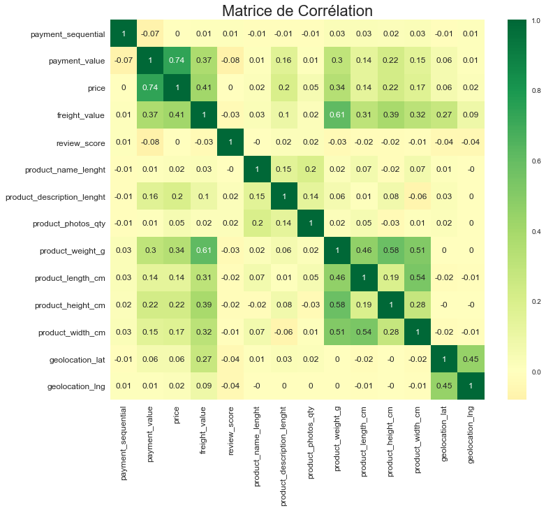

```python
plt.figure(figsize=(12,10))
sns.heatmap(master_df_quant.corr().round(2),
            xticklabels=master_df_quant.corr().columns,
            yticklabels=master_df_quant.corr().columns,
            cmap='RdYlGn', center=0, annot=True)

plt.title('Matrice de Corrélation', fontsize=22)
plt.xticks(fontsize=12)
plt.yticks(fontsize=12)
plt.show()
```

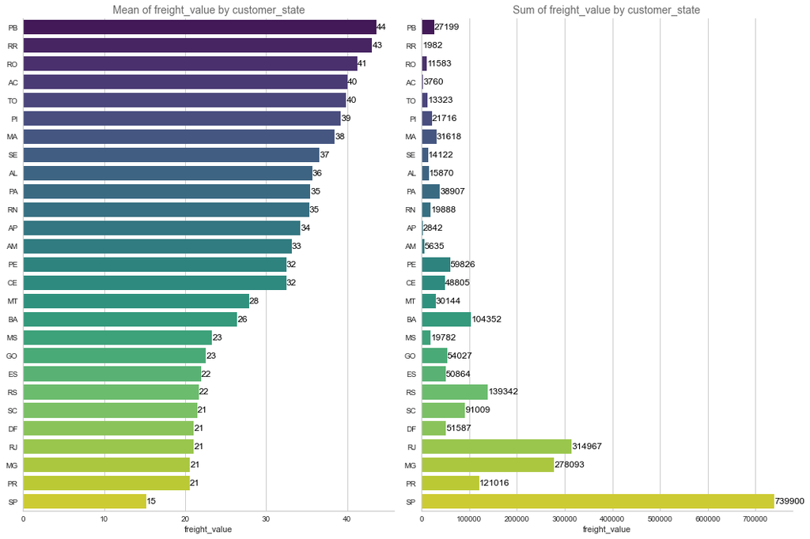

```python
mean_sum_analysis(master_df, 'customer_state', 'freight_value', palette='viridis', figsize=(15, 10))
```

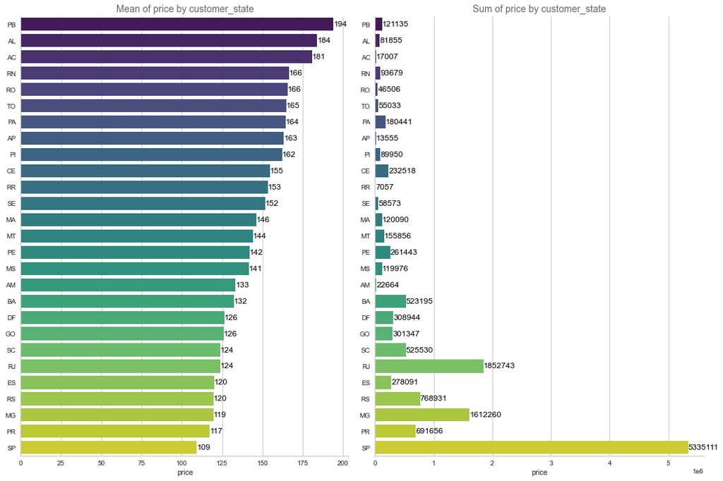

```python
mean_sum_analysis(master_df, 'customer_state', 'price', palette='viridis', figsize=(15, 10))
```

```python
# Changing the data type for date columns
timestamp_cols = ['order_purchase_timestamp', 'order_approved_at', 'order_delivered_carrier_date',
                  'order_estimated_delivery_date']
for col in timestamp_cols:
    master_df[col] = pd.to_datetime(master_df[col])

# Extracting attributes for purchase date - Year and Month
master_df['order_purchase_year'] = master_df['order_purchase_timestamp'].apply(lambda x: x.year)
master_df['order_purchase_month'] = master_df['order_purchase_timestamp'].apply(lambda x: x.month)
master_df['order_purchase_month_name'] = master_df['order_purchase_timestamp'].apply(lambda x: x.strftime('%b'))
master_df['order_purchase_year_month'] = master_df['order_purchase_timestamp'].apply(lambda x: x.strftime('%Y%m'))
master_df['order_purchase_date'] = master_df['order_purchase_timestamp'].apply(lambda x: x.strftime('%Y%m%d'))

# Extracting attributes for purchase date - Day and Day of Week
master_df['order_purchase_day'] = master_df['order_purchase_timestamp'].apply(lambda x: x.day)
master_df['order_purchase_dayofweek'] = master_df['order_purchase_timestamp'].apply(lambda x: x.dayofweek)
master_df['order_purchase_dayofweek_name'] = master_df['order_purchase_timestamp'].apply(lambda x: x.strftime('%a'))

# Extracting attributes for purchase date - Hour and Time of the Day
master_df['order_purchase_hour'] = master_df['order_purchase_timestamp'].apply(lambda x: x.hour)
hours_bins = [-0.1, 6, 12, 18, 23]
hours_labels = ['Dawn', 'Morning', 'Afternoon', 'Night']
master_df['order_purchase_time_day'] = pd.cut(master_df['order_purchase_hour'], hours_bins, labels=hours_labels)

# New DataFrame after transformations
master_df.head()
```

|  | order_id | payment_sequential | payment_type | payment_installments | payment_value | customer_id | order_status | order_purchase_timestamp | order_approved_at | order_delivered_carrier_date | order_delivered_customer_date | order_estimated_delivery_date | order_item_id | product_id | seller_id | shipping_limit_date | price | freight_value | review_id | review_score | review_comment_title | review_comment_message | review_creation_date | review_answer_timestamp | customer_unique_id | customer_zip_code_prefix | customer_city | customer_state | product_category_name | … |
| --- | --- | --- | --- | --- | --- | --- | --- | --- | --- | --- | --- | --- | --- | --- | --- | --- | --- | --- | --- | --- | --- | --- | --- | --- | --- | --- | --- | --- | --- | --- |
| 0 | b81ef226f3fe1789b1e8b2acac839d17 | 1 | credit_card | 8 | 99.33 | 0a8556ac6be836b46b3e89920d59291c | delivered | 2018-04-25 22:01:49 | 2018-04-25 22:15:09 | 2018-05-02 15:20:00 | 2018-05-09 17:36:51 | 2018-05-22 | 1.0 | af74cc53dcffc8384b29e7abfa41902b | 213b25e6f54661939f11710a6fddb871 | 2018-05-02 22:15:09 | 79.80 | 19.53 | 4ce650e117a5b292bf5ea980a61eb61e | 1 | Não recomendo | Produto com qualidade ruim, amassado e descasc... | 2018-05-10 00:00:00 | 2018-05-15 23:38:00 | 708ab75d2a007f0564aedd11139c7708 | 39801 | teofilo otoni | MG | home_construction | … |
| 1 | a9810da82917af2d9aefd1278f1dcfa0 | 1 | credit_card | 1 | 24.39 | f2c7fc58a9de810828715166c672f10a | delivered | 2018-06-26 11:01:38 | 2018-06-26 11:18:58 | 2018-06-28 14:18:00 | 2018-06-29 20:32:09 | 2018-07-16 | 1.0 | a630cc320a8c872f9de830cf121661a3 | eaf6d55068dea77334e8477d3878d89e | 2018-07-02 11:18:58 | 17.00 | 7.39 | ad2036caca61484fc435d7e673c020f2 | 5 | None | None | 2018-06-30 00:00:00 | 2018-07-03 11:23:16 | a8b9d3a27068454b1c98cc67d4e31e6f | 2422 | sao paulo | SP | auto | … |
| 2 | 25e8ea4e93396b6fa0d3dd708e76c1bd | 1 | credit_card | 1 | 65.71 | 25b14b69de0b6e184ae6fe2755e478f9 | delivered | 2017-12-12 11:19:55 | 2017-12-14 09:52:34 | 2017-12-15 20:13:22 | 2017-12-18 17:24:41 | 2018-01-04 | 1.0 | 2028bf1b01cafb2d2b1901fca4083222 | cc419e0650a3c5ba77189a1882b7556a | 2017-12-26 09:52:34 | 56.99 | 8.72 | bcddfa0f7d2e54cfc74bae4f01b84d92 | 5 | None | Aprovada | 2017-12-19 00:00:00 | 2017-12-22 17:55:30 | 6f70c0b2f7552832ba46eb57b1c5651e | 2652 | sao paulo | SP | perfumery | … |
| 3 | ba78997921bbcdc1373bb41e913ab953 | 1 | credit_card | 8 | 107.78 | 7a5d8efaaa1081f800628c30d2b0728f | delivered | 2017-12-06 12:04:06 | 2017-12-06 12:13:20 | 2017-12-07 20:28:28 | 2017-12-21 01:35:51 | 2018-01-04 | 1.0 | 548e5bfe28edceab6b51fa707cc9556f | da8622b14eb17ae2831f4ac5b9dab84a | 2017-12-12 12:13:20 | 89.90 | 17.88 | c37a0e51e5df82bdb55d38ff0ffb6af3 | 5 | None | None | 2017-12-21 00:00:00 | 2017-12-21 21:42:31 | 87695ed086ebd36f20404c82d20fca87 | 36060 | juiz de fora | MG | bed_bath_table | … |
| 4 | ba78997921bbcdc1373bb41e913ab953 | 1 | credit_card | 8 | 107.78 | 7a5d8efaaa1081f800628c30d2b0728f | delivered | 2017-12-06 12:04:06 | 2017-12-06 12:13:20 | 2017-12-07 20:28:28 | 2017-12-21 01:35:51 | 2018-01-04 | 1.0 | 548e5bfe28edceab6b51fa707cc9556f | da8622b14eb17ae2831f4ac5b9dab84a | 2017-12-12 12:13:20 | 89.90 | 17.88 | 5bc7680443b4ef765fec11a8201eeb0c | 5 | None | None | 2017-12-21 00:00:00 | 2017-12-22 01:10:39 | 87695ed086ebd36f20404c82d20fca87 | 36060 | juiz de fora | MG | bed_bath_table | … |

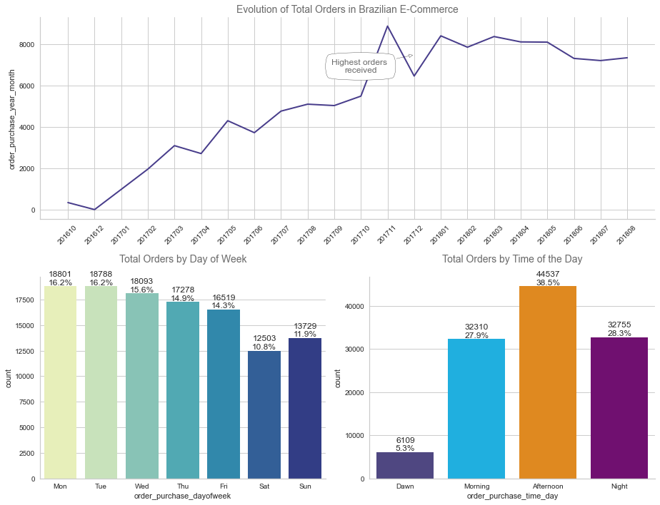

```python
fig = plt.figure(constrained_layout=True, figsize=(13, 10))

# Axis definition
gs = GridSpec(2, 2, figure=fig)
ax1 = fig.add_subplot(gs[0, :])
ax2 = fig.add_subplot(gs[1, 0])
ax3 = fig.add_subplot(gs[1, 1])

# Lineplot - Evolution of e-commerce orders along time
sns.lineplot(data=master_df['order_purchase_year_month'].value_counts().sort_index(), ax=ax1,
             color='darkslateblue', linewidth=2)
ax1.annotate(f'Highest orders \nreceived', (13, 7500), xytext=(-75, -25),
             textcoords='offset points', bbox=dict(boxstyle="round4", fc="w", pad=.8),
             arrowprops=dict(arrowstyle='-|>', fc='w'), color='dimgrey', ha='center')
ax1.annotate(f'Noise on data \n(huge decrease)', (23, 0), xytext=(48, 25),
             textcoords='offset points', bbox=dict(boxstyle="round4", fc="w", pad=.5),
             arrowprops=dict(arrowstyle='-|>', fc='w'), color='dimgrey', ha='center')
format_spines(ax1, right_border=False)
for tick in ax1.get_xticklabels():
    tick.set_rotation(45)
ax1.set_title('Evolution of Total Orders in Brazilian E-Commerce', size=14, color='dimgrey')

# Barchart - Total of orders by day of week
single_countplot(master_df, x='order_purchase_dayofweek', ax=ax2, order=False, palette='YlGnBu')
weekday_label = ['Mon', 'Tue', 'Wed', 'Thu', 'Fri', 'Sat', 'Sun']
ax2.set_xticklabels(weekday_label)
ax2.set_title('Total Orders by Day of Week', size=14, color='dimgrey', pad=20)

# Barchart - Total of orders by time of the day
day_color_list = ['darkslateblue', 'deepskyblue', 'darkorange', 'purple']
single_countplot(master_df, x='order_purchase_time_day', ax=ax3, order=False, palette=day_color_list)
ax3.set_title('Total Orders by Time of the Day', size=14, color='dimgrey', pad=20)

plt.tight_layout()
plt.show()
```

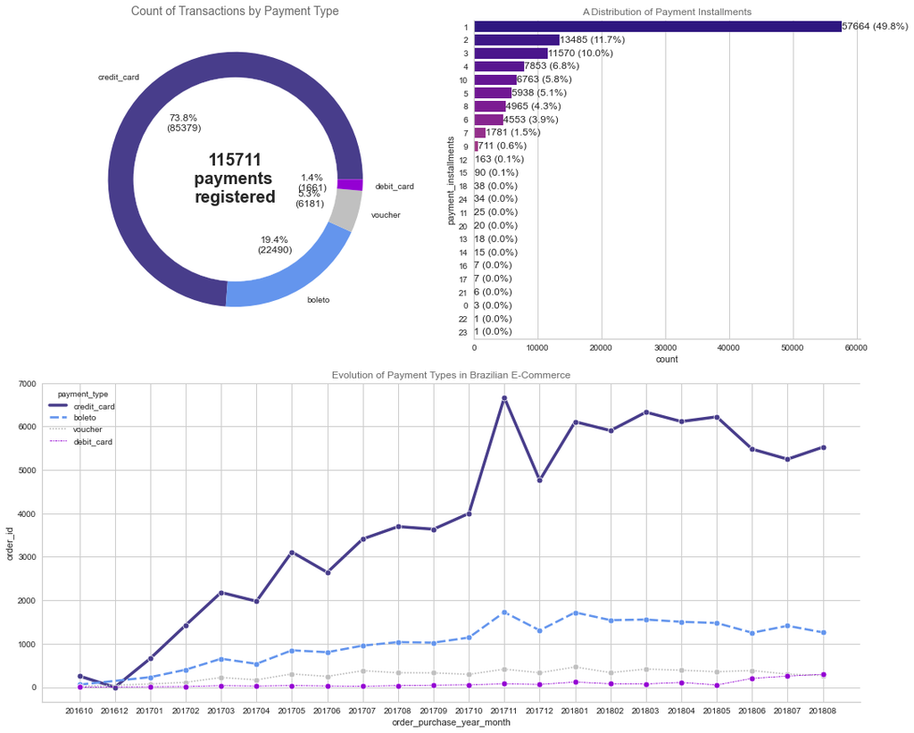

```python
# Creating figure
fig = plt.figure(constrained_layout=True, figsize=(15, 12))

# Axis definition
gs = GridSpec(2, 2, figure=fig)
ax1 = fig.add_subplot(gs[0, 0])
ax2 = fig.add_subplot(gs[0, 1])
ax3 = fig.add_subplot(gs[1, :])

# Plot 1 - Payment types in a donut chart
colors = ['darkslateblue', 'cornflowerblue', 'silver', 'darkviolet']
label_names = master_df['payment_type'].value_counts().index
donut_plot(master_df, col='payment_type', ax=ax1, label_names=label_names, colors=colors,
           title='Count of Transactions by Payment Type', text=f'{len(master_df)}\npayments \nregistered')

# Plot 2 - Payment installments
single_countplot(master_df, ax=ax2, y='payment_installments')
ax2.set_title('A Distribution of Payment Installments', color='dimgrey', size=12)

# Plot 3 - Evolution of payment types
payment_evl = master_df.groupby(by=['order_purchase_year_month', 'payment_type'], as_index=False).count()
payment_evl = payment_evl.loc[:, ['order_purchase_year_month', 'payment_type', 'order_id']]
payment_evl = payment_evl.sort_values(by=['order_purchase_year_month', 'order_id'], ascending=[True, False])
sns.lineplot(x='order_purchase_year_month', y='order_id', data=payment_evl, ax=ax3, hue='payment_type',
             style='payment_type', size='payment_type', palette=colors, marker='o')
format_spines(ax3, right_border=False)
ax3.set_title('Evolution of Payment Types in Brazilian E-Commerce', size=12, color='dimgrey')
plt.show()
```

```python
# Grouping geolocation data for plotting a heatmap
heat_data = geolocationX.groupby(by=['geolocation_lat', 'geolocation_lng'], as_index=False).count().iloc[:, :3]

# Creating a mapa using folium
map1 = folium.Map(
    location=[-15, -50],
    zoom_start=4.0,
    tiles='cartodbdark_matter'
)

# Plugin: HeatMap
HeatMap(
    name='Heat Map',
    data=heat_data,
    radius=10,
    max_zoom=13
).add_to(map1)

#map1
```

```
<folium.plugins.heat_map.HeatMap at 0x7fc352c84730>
```

```python
master_df.shape
```

```
(115711, 51)
```

```python
master_df = master_df.dropna(how='any')
```

```python
master_df
```

|  | order_id | payment_sequential | payment_type | payment_installments | payment_value | customer_id | order_status | order_purchase_timestamp | order_approved_at | order_delivered_carrier_date | order_delivered_customer_date | order_estimated_delivery_date | order_item_id | product_id | seller_id | shipping_limit_date | price | freight_value | review_id | review_score | review_comment_title | review_comment_message | review_creation_date | review_answer_timestamp | customer_unique_id | customer_zip_code_prefix | customer_city | customer_state | product_category_name | … |
| --- | --- | --- | --- | --- | --- | --- | --- | --- | --- | --- | --- | --- | --- | --- | --- | --- | --- | --- | --- | --- | --- | --- | --- | --- | --- | --- | --- | --- | --- | --- |
| 0 | b81ef226f3fe1789b1e8b2acac839d17 | 1 | credit_card | 8 | 99.33 | 0a8556ac6be836b46b3e89920d59291c | delivered | 2018-04-25 22:01:49 | 2018-04-25 22:15:09 | 2018-05-02 15:20:00 | 2018-05-09 17:36:51 | 2018-05-22 | 1.0 | af74cc53dcffc8384b29e7abfa41902b | 213b25e6f54661939f11710a6fddb871 | 2018-05-02 22:15:09 | 79.80 | 19.53 | 4ce650e117a5b292bf5ea980a61eb61e | 1 | Não recomendo | Produto com qualidade ruim, amassado e descasc... | 2018-05-10 00:00:00 | 2018-05-15 23:38:00 | 708ab75d2a007f0564aedd11139c7708 | 39801 | teofilo otoni | MG | home_construction | … |
| 1 | a9810da82917af2d9aefd1278f1dcfa0 | 1 | credit_card | 1 | 24.39 | f2c7fc58a9de810828715166c672f10a | delivered | 2018-06-26 11:01:38 | 2018-06-26 11:18:58 | 2018-06-28 14:18:00 | 2018-06-29 20:32:09 | 2018-07-16 | 1.0 | a630cc320a8c872f9de830cf121661a3 | eaf6d55068dea77334e8477d3878d89e | 2018-07-02 11:18:58 | 17.00 | 7.39 | ad2036caca61484fc435d7e673c020f2 | 5 | None | None | 2018-06-30 00:00:00 | 2018-07-03 11:23:16 | a8b9d3a27068454b1c98cc67d4e31e6f | 2422 | sao paulo | SP | auto | … |
| 2 | 25e8ea4e93396b6fa0d3dd708e76c1bd | 1 | credit_card | 1 | 65.71 | 25b14b69de0b6e184ae6fe2755e478f9 | delivered | 2017-12-12 11:19:55 | 2017-12-14 09:52:34 | 2017-12-15 20:13:22 | 2017-12-18 17:24:41 | 2018-01-04 | 1.0 | 2028bf1b01cafb2d2b1901fca4083222 | cc419e0650a3c5ba77189a1882b7556a | 2017-12-26 09:52:34 | 56.99 | 8.72 | bcddfa0f7d2e54cfc74bae4f01b84d92 | 5 | None | Aprovada | 2017-12-19 00:00:00 | 2017-12-22 17:55:30 | 6f70c0b2f7552832ba46eb57b1c5651e | 2652 | sao paulo | SP | perfumery | … |
| 3 | ba78997921bbcdc1373bb41e913ab953 | 1 | credit_card | 8 | 107.78 | 7a5d8efaaa1081f800628c30d2b0728f | delivered | 2017-12-06 12:04:06 | 2017-12-06 12:13:20 | 2017-12-07 20:28:28 | 2017-12-21 01:35:51 | 2018-01-04 | 1.0 | 548e5bfe28edceab6b51fa707cc9556f | da8622b14eb17ae2831f4ac5b9dab84a | 2017-12-12 12:13:20 | 89.90 | 17.88 | c37a0e51e5df82bdb55d38ff0ffb6af3 | 5 | None | None | 2017-12-21 00:00:00 | 2017-12-21 21:42:31 | 87695ed086ebd36f20404c82d20fca87 | 36060 | juiz de fora | MG | bed_bath_table | … |
| 4 | ba78997921bbcdc1373bb41e913ab953 | 1 | credit_card | 8 | 107.78 | 7a5d8efaaa1081f800628c30d2b0728f | delivered | 2017-12-06 12:04:06 | 2017-12-06 12:13:20 | 2017-12-07 20:28:28 | 2017-12-21 01:35:51 | 2018-01-04 | 1.0 | 548e5bfe28edceab6b51fa707cc9556f | da8622b14eb17ae2831f4ac5b9dab84a | 2017-12-12 12:13:20 | 89.90 | 17.88 | 5bc7680443b4ef765fec11a8201eeb0c | 5 | None | None | 2017-12-21 00:00:00 | 2017-12-22 01:10:39 | 87695ed086ebd36f20404c82d20fca87 | 36060 | juiz de fora | MG | bed_bath_table | … |
| ... | ... | ... | ... | ... | ... | ... | ... | ... | ... | ... | ... | ... | ... | ... | ... | ... | ... | ... | ... | ... | ... | ... | ... | ... | ... | ... | ... | ... | ... | … |
| 115706 | c45067032fd84f4cf408730ff5205568 | 1 | credit_card | 2 | 198.94 | 0fea3afc6a1510c9db75d349d28af974 | delivered | 2018-05-16 12:09:45 | 2018-05-16 12:39:20 | 2018-05-17 12:41:00 | 2018-05-22 17:28:28 | 2018-06-12 | 1.0 | fea2f92877b647dc07ea8e3f4aa2cf3f | 406822777a0b9eb5c50e442dd4cd3ec5 | 2018-05-22 12:30:57 | 179.80 | 19.14 | 9d099d7c7c6f2e00167890928d37c5c7 | 5 | None | None | 2018-05-23 00:00:00 | 2018-05-28 18:52:37 | 13f283df2f4760f22b57830865761d07 | 85869 | foz do iguacu | PR | toys | … |
| 115707 | 0406037ad97740d563a178ecc7a2075c | 1 | boleto | 1 | 363.31 | 5d576cb2dfa3bc05612c392a1ee9c654 | delivered | 2018-03-08 16:57:23 | 2018-03-10 03:55:25 | 2018-03-12 18:19:36 | 2018-03-16 13:09:51 | 2018-04-04 | 1.0 | 1302fd16bdfe85e523940c846370ef2c | a369d693961cb93b61ca2cc518872a85 | 2018-03-15 03:55:25 | 297.00 | 66.31 | 9f402e937d15b4664948410079ab687d | 5 | None | Tudo certo! | 2018-03-17 00:00:00 | 2018-03-20 15:17:08 | b6027ac07fb76ebca8c97b1887865aee | 12954 | atibaia | SP | construction_tools_lights | … |
| 115708 | 7b905861d7c825891d6347454ea7863f | 1 | credit_card | 2 | 96.80 | 2079230c765a88530822a34a4cec2aa0 | delivered | 2017-08-18 09:45:35 | 2017-08-18 10:04:56 | 2017-08-18 18:04:24 | 2017-08-23 22:25:56 | 2017-09-12 | 1.0 | fb55982be901439613a95940feefd9ee | 3d871de0142ce09b7081e2b9d1733cb1 | 2017-08-24 10:04:56 | 79.00 | 17.80 | f78d2909c6c202d3cabb8bac3fc00e75 | 5 | None | None | 2017-08-24 00:00:00 | 2017-08-25 19:38:31 | 53b30ca78efb2b7efcd3f9e461587eb2 | 30210 | belo horizonte | MG | stationery | … |
| 115709 | b8b61059626efa996a60be9bb9320e10 | 1 | credit_card | 5 | 369.54 | 5d719b0d300663188169c6560e243f27 | delivered | 2018-08-07 23:26:13 | 2018-08-07 23:45:00 | 2018-08-09 11:46:00 | 2018-08-21 22:41:46 | 2018-08-24 | 1.0 | e9c1abcc7126360336d8f56d49041a8c | 679769a98cfcc6da877c8486ff1c13f3 | 2018-08-13 23:45:00 | 349.00 | 20.54 | 6c698e5d193ab18db7615ea75a28866e | 5 | None | None | 2018-08-22 00:00:00 | 2018-08-23 15:29:34 | b84dc68f02f122a88d7e7bbd37b06204 | 22733 | rio de janeiro | RJ | health_beauty | … |
| 115710 | 28bbae6599b09d39ca406b747b6632b1 | 1 | boleto | 1 | 191.58 | 4c7f868f43b5cff577b0becb8c8b7860 | delivered | 2017-12-05 08:18:35 | 2017-12-06 02:50:09 | 2017-12-08 00:51:47 | 2018-02-05 14:59:09 | 2017-12-29 | 1.0 | 1cdfaf0cc5abd6063d3a10ae3318f345 | da8622b14eb17ae2831f4ac5b9dab84a | 2017-12-12 02:50:09 | 169.90 | 21.68 | fa9bd3a24482e2dfd0c776446baec09f | 1 | None | Ja passou do prazo e eu ainda nao recebi o pro... | 2018-01-04 00:00:00 | 2018-01-04 10:00:40 | b1f51a4e19da3338e51fbcfabefad1bf | 23059 | rio de janeiro | RJ | bed_bath_table | … |

115711 rows × 51 columns

## Feature Engineering

```python
most_frequent = lambda x:x.mode()[0]
lister = lambda x:list(set(x))
lister_2 = lambda x:list(x)
lister_3 = lambda x:max(list(set(pd.to_datetime(x))))
```

```python
customer_df = master_df.groupby([
  'customer_unique_id',
  'customer_state',
], as_index=False).agg({
  'payment_value': 'sum',
  'payment_type' : most_frequent,
  'product_category_name' : lister,
  'review_score': 'mean',
  'freight_value':'sum',
  'geolocation_lat':'mean',
  'geolocation_lng':'mean',
  'order_purchase_date': lister_3
})
```

```python
customer_df
```

|  | customer_unique_id | customer_state | payment_value | payment_type | product_category_name | review_score | freight_value | geolocation_lat | geolocation_lng | order_purchase_date |
| --- | --- | --- | --- | --- | --- | --- | --- | --- | --- | --- |
| 0 | 0000366f3b9a7992bf8c76cfdf3221e2 | SP | 141.90 | credit_card | [bed_bath_table] | 5.0 | 12.00 | -23.340262 | -46.831085 | 2018-05-10 |
| 1 | 0000b849f77a49e4a4ce2b2a4ca5be3f | SP | 27.19 | credit_card | [health_beauty] | 4.0 | 8.29 | -23.559044 | -46.788516 | 2018-05-07 |
| 2 | 0000f46a3911fa3c0805444483337064 | SC | 86.22 | credit_card | [stationery] | 3.0 | 17.22 | -27.543010 | -48.634938 | 2017-03-10 |
| 3 | 0000f6ccb0745a6a4b88665a16c9f078 | PA | 43.62 | credit_card | [telephony] | 4.0 | 17.63 | -1.312726 | -48.482748 | 2017-10-12 |
| 4 | 0004aac84e0df4da2b147fca70cf8255 | SP | 196.89 | credit_card | [telephony] | 5.0 | 16.89 | -23.505588 | -47.469820 | 2017-11-14 |
| ... | ... | ... | ... | ... | ... | ... | ... | ... | ... | ... |
| 93374 | fffcf5a5ff07b0908bd4e2dbc735a684 | PE | 4134.84 | credit_card | [health_beauty] | 5.0 | 497.42 | -8.362654 | -36.562103 | 2017-06-08 |
| 93375 | fffea47cd6d3cc0a88bd621562a9d061 | BA | 84.58 | credit_card | [baby] | 4.0 | 19.69 | -12.217900 | -38.959237 | 2017-12-10 |
| 93376 | ffff371b4d645b6ecea244b27531430a | MT | 112.46 | credit_card | [auto] | 5.0 | 22.56 | -11.834705 | -55.508145 | 2017-02-07 |
| 93377 | ffff5962728ec6157033ef9805bacc48 | ES | 133.69 | credit_card | [watches_gifts] | 5.0 | 18.69 | -21.126170 | -41.672396 | 2018-05-02 |
| 93378 | ffffd2657e2aad2907e67c3e9daecbeb | PR | 71.56 | credit_card | [perfumery] | 5.0 | 14.57 | -25.445705 | -49.442463 | 2017-05-02 |

93379 rows × 10 columns

```python
customer_df.drop_duplicates(subset=['customer_unique_id'],inplace=True)
customer_df.reset_index(drop=True,inplace=True)
customer_df
```

|  | customer_unique_id | customer_state | payment_value | payment_type | product_category_name | review_score | freight_value | geolocation_lat | geolocation_lng | order_purchase_date |
| --- | --- | --- | --- | --- | --- | --- | --- | --- | --- | --- |
| 0 | 0000366f3b9a7992bf8c76cfdf3221e2 | SP | 141.90 | credit_card | [bed_bath_table] | 5.0 | 12.00 | -23.340262 | -46.831085 | 2018-05-10 |
| 1 | 0000b849f77a49e4a4ce2b2a4ca5be3f | SP | 27.19 | credit_card | [health_beauty] | 4.0 | 8.29 | -23.559044 | -46.788516 | 2018-05-07 |
| 2 | 0000f46a3911fa3c0805444483337064 | SC | 86.22 | credit_card | [stationery] | 3.0 | 17.22 | -27.543010 | -48.634938 | 2017-03-10 |
| 3 | 0000f6ccb0745a6a4b88665a16c9f078 | PA | 43.62 | credit_card | [telephony] | 4.0 | 17.63 | -1.312726 | -48.482748 | 2017-10-12 |
| 4 | 0004aac84e0df4da2b147fca70cf8255 | SP | 196.89 | credit_card | [telephony] | 5.0 | 16.89 | -23.505588 | -47.469820 | 2017-11-14 |
| ... | ... | ... | ... | ... | ... | ... | ... | ... | ... | ... |
| 93336 | fffcf5a5ff07b0908bd4e2dbc735a684 | PE | 4134.84 | credit_card | [health_beauty] | 5.0 | 497.42 | -8.362654 | -36.562103 | 2017-06-08 |
| 93337 | fffea47cd6d3cc0a88bd621562a9d061 | BA | 84.58 | credit_card | [baby] | 4.0 | 19.69 | -12.217900 | -38.959237 | 2017-12-10 |
| 93338 | ffff371b4d645b6ecea244b27531430a | MT | 112.46 | credit_card | [auto] | 5.0 | 22.56 | -11.834705 | -55.508145 | 2017-02-07 |
| 93339 | ffff5962728ec6157033ef9805bacc48 | ES | 133.69 | credit_card | [watches_gifts] | 5.0 | 18.69 | -21.126170 | -41.672396 | 2018-05-02 |
| 93340 | ffffd2657e2aad2907e67c3e9daecbeb | PR | 71.56 | credit_card | [perfumery] | 5.0 | 14.57 | -25.445705 | -49.442463 | 2017-05-02 |

93341 rows × 10 columns

## Transformation pour ML

```python
selected_features = [
  'product_category_name',
]
```

```python
from sklearn.preprocessing import StandardScaler, MultiLabelBinarizer
```

```python
mlb = MultiLabelBinarizer()
mlb.fit_transform(customer_df['product_category_name'])
product_df = pd.DataFrame(mlb.fit_transform(customer_df['product_category_name']),
                   columns=mlb.classes_,
                   index=customer_df['product_category_name'].index)
product_df
```

|  | Other | agro_industry_and_commerce | air_conditioning | art | arts_and_craftmanship | audio | auto | baby | bed_bath_table | books_general_interest | books_imported | books_technical | cds_dvds_musicals | christmas_supplies | cine_photo | computers | computers_accessories | consoles_games | construction_tools_construction | construction_tools_lights | construction_tools_safety | cool_stuff | costruction_tools_garden | costruction_tools_tools | diapers_and_hygiene | drinks | dvds_blu_ray | electronics | fashio_female_clothing | … |
| --- | --- | --- | --- | --- | --- | --- | --- | --- | --- | --- | --- | --- | --- | --- | --- | --- | --- | --- | --- | --- | --- | --- | --- | --- | --- | --- | --- | --- | --- | --- |
| 0 | 0 | 0 | 0 | 0 | 0 | 0 | 0 | 0 | 1 | 0 | 0 | 0 | 0 | 0 | 0 | 0 | 0 | 0 | 0 | 0 | 0 | 0 | 0 | 0 | 0 | 0 | 0 | 0 | 0 | … |
| 1 | 0 | 0 | 0 | 0 | 0 | 0 | 0 | 0 | 0 | 0 | 0 | 0 | 0 | 0 | 0 | 0 | 0 | 0 | 0 | 0 | 0 | 0 | 0 | 0 | 0 | 0 | 0 | 0 | 0 | … |
| 2 | 0 | 0 | 0 | 0 | 0 | 0 | 0 | 0 | 0 | 0 | 0 | 0 | 0 | 0 | 0 | 0 | 0 | 0 | 0 | 0 | 0 | 0 | 0 | 0 | 0 | 0 | 0 | 0 | 0 | … |
| 3 | 0 | 0 | 0 | 0 | 0 | 0 | 0 | 0 | 0 | 0 | 0 | 0 | 0 | 0 | 0 | 0 | 0 | 0 | 0 | 0 | 0 | 0 | 0 | 0 | 0 | 0 | 0 | 0 | 0 | … |
| 4 | 0 | 0 | 0 | 0 | 0 | 0 | 0 | 0 | 0 | 0 | 0 | 0 | 0 | 0 | 0 | 0 | 0 | 0 | 0 | 0 | 0 | 0 | 0 | 0 | 0 | 0 | 0 | 0 | 0 | … |
| ... | ... | ... | ... | ... | ... | ... | ... | ... | ... | ... | ... | ... | ... | ... | ... | ... | ... | ... | ... | ... | ... | ... | ... | ... | ... | ... | ... | ... | ... | … |
| 93336 | 0 | 0 | 0 | 0 | 0 | 0 | 0 | 0 | 0 | 0 | 0 | 0 | 0 | 0 | 0 | 0 | 0 | 0 | 0 | 0 | 0 | 0 | 0 | 0 | 0 | 0 | 0 | 0 | 0 | … |
| 93337 | 0 | 0 | 0 | 0 | 0 | 0 | 0 | 1 | 0 | 0 | 0 | 0 | 0 | 0 | 0 | 0 | 0 | 0 | 0 | 0 | 0 | 0 | 0 | 0 | 0 | 0 | 0 | 0 | 0 | … |
| 93338 | 0 | 0 | 0 | 0 | 0 | 0 | 1 | 0 | 0 | 0 | 0 | 0 | 0 | 0 | 0 | 0 | 0 | 0 | 0 | 0 | 0 | 0 | 0 | 0 | 0 | 0 | 0 | 0 | 0 | … |
| 93339 | 0 | 0 | 0 | 0 | 0 | 0 | 0 | 0 | 0 | 0 | 0 | 0 | 0 | 0 | 0 | 0 | 0 | 0 | 0 | 0 | 0 | 0 | 0 | 0 | 0 | 0 | 0 | 0 | 0 | … |
| 93340 | 0 | 0 | 0 | 0 | 0 | 0 | 0 | 0 | 0 | 0 | 0 | 0 | 0 | 0 | 0 | 0 | 0 | 0 | 0 | 0 | 0 | 0 | 0 | 0 | 0 | 0 | 0 | 0 | 0 | … |

93341 rows × 73 columns

## PCA sur Product category

```python
from sklearn.decomposition import PCA
pca = PCA()
```

```python
pca.fit(product_df)
```

```
PCA()
```

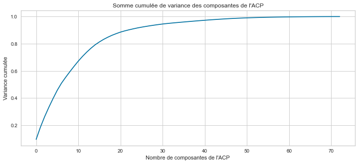

```python
plt.figure(figsize=(12,5))
plt.title('Somme cumulée de variance des composantes de l\'ACP')
plt.xlabel('Nombre de composantes de l\'ACP')
plt.ylabel('Variance cumulée')
plt.plot(list(range(product_df.shape[1])),
         np.cumsum(pca.explained_variance_ratio_));
```

```python
pca_opt = 15

np.cumsum(pca.explained_variance_ratio_)[pca_opt]
```

```
0.8133175941318829
```

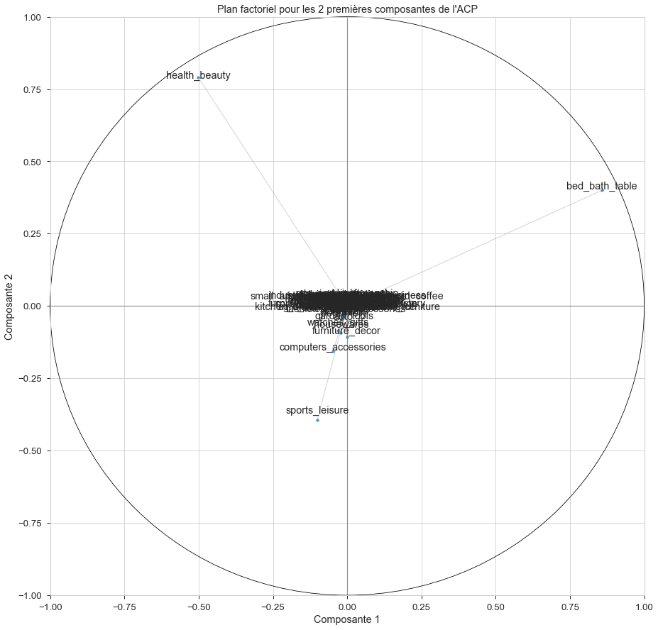

```python
colonnes_pca = product_df.columns

from matplotlib.patches import Circle
sns.set_context("paper", font_scale=1.5)
plt.figure(figsize=(15,15))
chaine = "Plan factoriel pour les 2 premières composantes de l'ACP"
plt.title(chaine)
plt.xlabel('Composante 1')
plt.ylabel('Composante 2')
ax = plt.gca()
ax.add_patch(Circle([0,0], radius=1, color='black', fill=False, linestyle='-',
                    clip_on=False))
ax.set_xlim(-1,1)
ax.set_ylim(-1,1)
x_pca = pca.components_[0,:]
y_pca = pca.components_[1,:]

sns.scatterplot(x = x_pca,
                y = y_pca,
               alpha = 0.7)
plt.plot([-1,1],[0,0], color='grey', alpha=0.8)
plt.plot([0,0],[-1,1], color='grey', alpha=0.8)

i = 0
for x,y,colonne in zip(x_pca,y_pca, colonnes_pca):

    plt.annotate(colonne,
                 (x,y),
                 textcoords="offset points",
                 xytext=(0,5+np.random.randint(-10,10)),
                 ha='center')
    ax.arrow(0, 0, x, y, head_width=0, head_length=0, fc='grey', ec='grey',
             alpha=0.2)


sns.set_context("paper", font_scale=1)
```

```python
product_pca = pca.transform(product_df)[:,:pca_opt]
```

```python
product_pca
```

```
array([[ 0.83749278,  0.35834058,  0.14309886, ..., -0.01334617,
        -0.00754329, -0.00718713],
       [-0.52056368,  0.74986693,  0.15419116, ..., -0.01073008,
        -0.01162263, -0.01094327],
       [-0.02608468, -0.05590305, -0.05173432, ...,  0.11406914,
         0.21134341,  0.90665367],
       ...,
       [-0.03165563, -0.0764357 , -0.07553536, ..., -0.0803735 ,
        -0.06458497, -0.04331912],
       [-0.04988482, -0.12586208, -0.14894729, ..., -0.02743477,
        -0.02741145, -0.02081753],
       [-0.03014731, -0.06329429, -0.05984948, ..., -0.36463677,
        -0.16903535, -0.09088126]])
```

```python
product_pca.shape
```

```
(93341, 15)
```

```python
x_show, y_show = product_pca[:,0],product_pca[:,1]
```

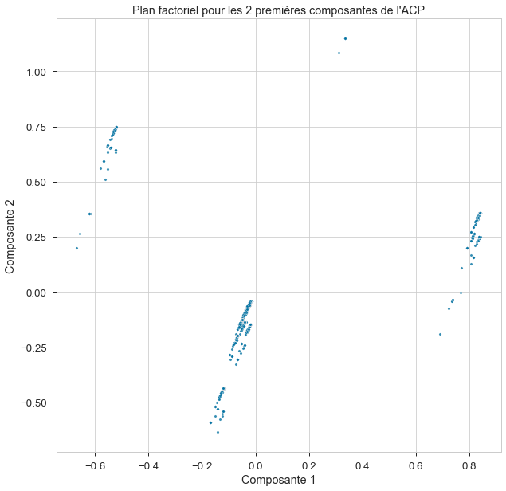

```python
sns.set_context("paper", font_scale=1.5)
plt.figure(figsize=(10,10))
chaine = "Plan factoriel pour les 2 premières composantes de l'ACP"
plt.title(chaine)
plt.xlabel('Composante 1')
plt.ylabel('Composante 2')
ax = plt.gca()

sns.scatterplot(x = x_show,
                y = y_show,
                #hue = hue_show,
                alpha=0.8, s=10)

sns.set_context("paper", font_scale=1)
```

```python
pca_labels =[]
n = product_pca.shape[1]

for x in range(n):
    pca_labels.append('pca_comp'+str(x))
```

```python
product_pca_df = pd.DataFrame(product_pca, columns=pca_labels)
```

```python
product_pca_df
```

|  | pca_comp0 | pca_comp1 | pca_comp2 | pca_comp3 | pca_comp4 | pca_comp5 | pca_comp6 | pca_comp7 | pca_comp8 | pca_comp9 | pca_comp10 | pca_comp11 | pca_comp12 | pca_comp13 | pca_comp14 |
| --- | --- | --- | --- | --- | --- | --- | --- | --- | --- | --- | --- | --- | --- | --- | --- |
| 0 | 0.837493 | 0.358341 | 0.143099 | 0.060319 | 0.029797 | 0.012406 | 0.062032 | 0.012884 | 0.000182 | -0.010682 | -0.005460 | -0.012353 | -0.013346 | -0.007543 | -0.007187 |
| 1 | -0.520564 | 0.749867 | 0.154191 | 0.036222 | 0.058078 | 0.031399 | 0.081124 | 0.014441 | 0.000469 | -0.012099 | -0.007424 | -0.018176 | -0.010730 | -0.011623 | -0.010943 |
| 2 | -0.026085 | -0.055903 | -0.051734 | -0.020163 | -0.044972 | -0.028402 | -0.124212 | -0.042481 | -0.004955 | 0.038741 | 0.033974 | 0.095662 | 0.114069 | 0.211343 | 0.906654 |
| 3 | -0.034814 | -0.081859 | -0.083444 | -0.029173 | -0.085498 | -0.066438 | -0.442752 | 0.836703 | -0.010257 | -0.134980 | -0.068456 | -0.092887 | -0.060119 | -0.051837 | -0.035532 |
| 4 | -0.034814 | -0.081859 | -0.083444 | -0.029173 | -0.085498 | -0.066438 | -0.442752 | 0.836703 | -0.010257 | -0.134980 | -0.068456 | -0.092887 | -0.060119 | -0.051837 | -0.035532 |
| ... | ... | ... | ... | ... | ... | ... | ... | ... | ... | ... | ... | ... | ... | ... | ... |
| 93336 | -0.520564 | 0.749867 | 0.154191 | 0.036222 | 0.058078 | 0.031399 | 0.081124 | 0.014441 | 0.000469 | -0.012099 | -0.007424 | -0.018176 | -0.010730 | -0.011623 | -0.010943 |
| 93337 | -0.023087 | -0.061196 | -0.058397 | -0.025320 | -0.051132 | -0.031586 | -0.160690 | -0.067731 | -0.016735 | 0.079939 | 0.036648 | 0.189756 | 0.864938 | -0.357007 | -0.127811 |
| 93338 | -0.031656 | -0.076436 | -0.075535 | -0.030553 | -0.074995 | -0.055374 | -0.320835 | -0.335125 | 0.719195 | -0.401721 | -0.145773 | -0.133821 | -0.080374 | -0.064585 | -0.043319 |
| 93339 | -0.049885 | -0.125862 | -0.148947 | -0.103308 | -0.328705 | -0.742299 | 0.467357 | 0.046128 | 0.001239 | -0.031136 | -0.019891 | -0.036878 | -0.027435 | -0.027411 | -0.020818 |
| 93340 | -0.030147 | -0.063294 | -0.059849 | -0.027328 | -0.054586 | -0.037055 | -0.180952 | -0.074576 | -0.002801 | 0.101151 | 0.096462 | 0.857753 | -0.364637 | -0.169035 | -0.090881 |

93341 rows × 15 columns

## Scaling des features numériques

```python
numerics = [
  'payment_value',
  'review_score',
  'freight_value',
  'geolocation_lat',
  'geolocation_lng'
]
```

```python
ss = StandardScaler()
customer_df_ss = customer_df.copy()
customer_df_ss[numerics] = ss.fit_transform(customer_df_ss[numerics])
```

```python
customer_df_ss
```

|  | customer_unique_id | customer_state | payment_value | payment_type | product_category_name | review_score | freight_value | geolocation_lat | geolocation_lng | order_purchase_date |
| --- | --- | --- | --- | --- | --- | --- | --- | --- | --- | --- |
| 0 | 0000366f3b9a7992bf8c76cfdf3221e2 | SP | -0.109922 | credit_card | [bed_bath_table] | 0.665636 | -0.467108 | -0.385188 | -0.158598 | 2018-05-10 |
| 1 | 0000b849f77a49e4a4ce2b2a4ca5be3f | SP | -0.287416 | credit_card | [health_beauty] | -0.108233 | -0.602918 | -0.424141 | -0.148105 | 2018-05-07 |
| 2 | 0000f46a3911fa3c0805444483337064 | SC | -0.196078 | credit_card | [stationery] | -0.882101 | -0.276022 | -1.133464 | -0.603268 | 2017-03-10 |
| 3 | 0000f6ccb0745a6a4b88665a16c9f078 | PA | -0.261994 | credit_card | [telephony] | -0.108233 | -0.261013 | 3.536694 | -0.565752 | 2017-10-12 |
| 4 | 0004aac84e0df4da2b147fca70cf8255 | SP | -0.024835 | credit_card | [telephony] | 0.665636 | -0.288102 | -0.414623 | -0.316054 | 2017-11-14 |
| ... | ... | ... | ... | ... | ... | ... | ... | ... | ... | ... |
| 93336 | fffcf5a5ff07b0908bd4e2dbc735a684 | PE | 6.068458 | credit_card | [health_beauty] | 0.665636 | 17.302417 | 2.281493 | 2.372823 | 2017-06-08 |
| 93337 | fffea47cd6d3cc0a88bd621562a9d061 | BA | -0.198615 | credit_card | [baby] | -0.108233 | -0.185604 | 1.595088 | 1.781902 | 2017-12-10 |
| 93338 | ffff371b4d645b6ecea244b27531430a | MT | -0.155476 | credit_card | [auto] | 0.665636 | -0.080543 | 1.663314 | -2.297592 | 2017-02-07 |
| 93339 | ffff5962728ec6157033ef9805bacc48 | ES | -0.122626 | credit_card | [watches_gifts] | 0.665636 | -0.222210 | 0.009019 | 1.113077 | 2018-05-02 |
| 93340 | ffffd2657e2aad2907e67c3e9daecbeb | PR | -0.218761 | credit_card | [perfumery] | 0.665636 | -0.373029 | -0.760050 | -0.802333 | 2017-05-02 |

93341 rows × 10 columns

```python
customer_df_ss['order_purchase_date'] = customer_df['order_purchase_date']
```

```python
customer_df_ss
```

|  | customer_unique_id | customer_state | payment_value | payment_type | product_category_name | review_score | freight_value | geolocation_lat | geolocation_lng | order_purchase_date |
| --- | --- | --- | --- | --- | --- | --- | --- | --- | --- | --- |
| 0 | 0000366f3b9a7992bf8c76cfdf3221e2 | SP | -0.109922 | credit_card | [bed_bath_table] | 0.665636 | -0.467108 | -0.385188 | -0.158598 | 2018-05-10 |
| 1 | 0000b849f77a49e4a4ce2b2a4ca5be3f | SP | -0.287416 | credit_card | [health_beauty] | -0.108233 | -0.602918 | -0.424141 | -0.148105 | 2018-05-07 |
| 2 | 0000f46a3911fa3c0805444483337064 | SC | -0.196078 | credit_card | [stationery] | -0.882101 | -0.276022 | -1.133464 | -0.603268 | 2017-03-10 |
| 3 | 0000f6ccb0745a6a4b88665a16c9f078 | PA | -0.261994 | credit_card | [telephony] | -0.108233 | -0.261013 | 3.536694 | -0.565752 | 2017-10-12 |
| 4 | 0004aac84e0df4da2b147fca70cf8255 | SP | -0.024835 | credit_card | [telephony] | 0.665636 | -0.288102 | -0.414623 | -0.316054 | 2017-11-14 |
| ... | ... | ... | ... | ... | ... | ... | ... | ... | ... | ... |
| 93336 | fffcf5a5ff07b0908bd4e2dbc735a684 | PE | 6.068458 | credit_card | [health_beauty] | 0.665636 | 17.302417 | 2.281493 | 2.372823 | 2017-06-08 |
| 93337 | fffea47cd6d3cc0a88bd621562a9d061 | BA | -0.198615 | credit_card | [baby] | -0.108233 | -0.185604 | 1.595088 | 1.781902 | 2017-12-10 |
| 93338 | ffff371b4d645b6ecea244b27531430a | MT | -0.155476 | credit_card | [auto] | 0.665636 | -0.080543 | 1.663314 | -2.297592 | 2017-02-07 |
| 93339 | ffff5962728ec6157033ef9805bacc48 | ES | -0.122626 | credit_card | [watches_gifts] | 0.665636 | -0.222210 | 0.009019 | 1.113077 | 2018-05-02 |
| 93340 | ffffd2657e2aad2907e67c3e9daecbeb | PR | -0.218761 | credit_card | [perfumery] | 0.665636 | -0.373029 | -0.760050 | -0.802333 | 2017-05-02 |

93341 rows × 10 columns

```python
product_pca_df['customer_unique_id'] = customer_df_ss['customer_unique_id']
```

```python
product_pca_df
```

|  | pca_comp0 | pca_comp1 | pca_comp2 | pca_comp3 | pca_comp4 | pca_comp5 | pca_comp6 | pca_comp7 | pca_comp8 | pca_comp9 | pca_comp10 | pca_comp11 | pca_comp12 | pca_comp13 | pca_comp14 | customer_unique_id |
| --- | --- | --- | --- | --- | --- | --- | --- | --- | --- | --- | --- | --- | --- | --- | --- | --- |
| 0 | 0.837493 | 0.358341 | 0.143099 | 0.060319 | 0.029797 | 0.012406 | 0.062032 | 0.012884 | 0.000182 | -0.010682 | -0.005460 | -0.012353 | -0.013346 | -0.007543 | -0.007187 | 0000366f3b9a7992bf8c76cfdf3221e2 |
| 1 | -0.520564 | 0.749867 | 0.154191 | 0.036222 | 0.058078 | 0.031399 | 0.081124 | 0.014441 | 0.000469 | -0.012099 | -0.007424 | -0.018176 | -0.010730 | -0.011623 | -0.010943 | 0000b849f77a49e4a4ce2b2a4ca5be3f |
| 2 | -0.026085 | -0.055903 | -0.051734 | -0.020163 | -0.044972 | -0.028402 | -0.124212 | -0.042481 | -0.004955 | 0.038741 | 0.033974 | 0.095662 | 0.114069 | 0.211343 | 0.906654 | 0000f46a3911fa3c0805444483337064 |
| 3 | -0.034814 | -0.081859 | -0.083444 | -0.029173 | -0.085498 | -0.066438 | -0.442752 | 0.836703 | -0.010257 | -0.134980 | -0.068456 | -0.092887 | -0.060119 | -0.051837 | -0.035532 | 0000f6ccb0745a6a4b88665a16c9f078 |
| 4 | -0.034814 | -0.081859 | -0.083444 | -0.029173 | -0.085498 | -0.066438 | -0.442752 | 0.836703 | -0.010257 | -0.134980 | -0.068456 | -0.092887 | -0.060119 | -0.051837 | -0.035532 | 0004aac84e0df4da2b147fca70cf8255 |
| ... | ... | ... | ... | ... | ... | ... | ... | ... | ... | ... | ... | ... | ... | ... | ... | ... |
| 93336 | -0.520564 | 0.749867 | 0.154191 | 0.036222 | 0.058078 | 0.031399 | 0.081124 | 0.014441 | 0.000469 | -0.012099 | -0.007424 | -0.018176 | -0.010730 | -0.011623 | -0.010943 | fffcf5a5ff07b0908bd4e2dbc735a684 |
| 93337 | -0.023087 | -0.061196 | -0.058397 | -0.025320 | -0.051132 | -0.031586 | -0.160690 | -0.067731 | -0.016735 | 0.079939 | 0.036648 | 0.189756 | 0.864938 | -0.357007 | -0.127811 | fffea47cd6d3cc0a88bd621562a9d061 |
| 93338 | -0.031656 | -0.076436 | -0.075535 | -0.030553 | -0.074995 | -0.055374 | -0.320835 | -0.335125 | 0.719195 | -0.401721 | -0.145773 | -0.133821 | -0.080374 | -0.064585 | -0.043319 | ffff371b4d645b6ecea244b27531430a |
| 93339 | -0.049885 | -0.125862 | -0.148947 | -0.103308 | -0.328705 | -0.742299 | 0.467357 | 0.046128 | 0.001239 | -0.031136 | -0.019891 | -0.036878 | -0.027435 | -0.027411 | -0.020818 | ffff5962728ec6157033ef9805bacc48 |
| 93340 | -0.030147 | -0.063294 | -0.059849 | -0.027328 | -0.054586 | -0.037055 | -0.180952 | -0.074576 | -0.002801 | 0.101151 | 0.096462 | 0.857753 | -0.364637 | -0.169035 | -0.090881 | ffffd2657e2aad2907e67c3e9daecbeb |

93341 rows × 16 columns

```python
final_df = pd.merge(customer_df_ss,product_pca_df,on='customer_unique_id',how='left')
```

```python
final_df
```

|  | customer_unique_id | customer_state | payment_value | payment_type | product_category_name | review_score | freight_value | geolocation_lat | geolocation_lng | order_purchase_date | pca_comp0 | pca_comp1 | pca_comp2 | pca_comp3 | pca_comp4 | pca_comp5 | pca_comp6 | pca_comp7 | pca_comp8 | pca_comp9 | pca_comp10 | pca_comp11 | pca_comp12 | pca_comp13 | pca_comp14 |
| --- | --- | --- | --- | --- | --- | --- | --- | --- | --- | --- | --- | --- | --- | --- | --- | --- | --- | --- | --- | --- | --- | --- | --- | --- | --- |
| 0 | 0000366f3b9a7992bf8c76cfdf3221e2 | SP | -0.109922 | credit_card | [bed_bath_table] | 0.665636 | -0.467108 | -0.385188 | -0.158598 | 2018-05-10 | 0.837493 | 0.358341 | 0.143099 | 0.060319 | 0.029797 | 0.012406 | 0.062032 | 0.012884 | 0.000182 | -0.010682 | -0.005460 | -0.012353 | -0.013346 | -0.007543 | -0.007187 |
| 1 | 0000b849f77a49e4a4ce2b2a4ca5be3f | SP | -0.287416 | credit_card | [health_beauty] | -0.108233 | -0.602918 | -0.424141 | -0.148105 | 2018-05-07 | -0.520564 | 0.749867 | 0.154191 | 0.036222 | 0.058078 | 0.031399 | 0.081124 | 0.014441 | 0.000469 | -0.012099 | -0.007424 | -0.018176 | -0.010730 | -0.011623 | -0.010943 |
| 2 | 0000f46a3911fa3c0805444483337064 | SC | -0.196078 | credit_card | [stationery] | -0.882101 | -0.276022 | -1.133464 | -0.603268 | 2017-03-10 | -0.026085 | -0.055903 | -0.051734 | -0.020163 | -0.044972 | -0.028402 | -0.124212 | -0.042481 | -0.004955 | 0.038741 | 0.033974 | 0.095662 | 0.114069 | 0.211343 | 0.906654 |
| 3 | 0000f6ccb0745a6a4b88665a16c9f078 | PA | -0.261994 | credit_card | [telephony] | -0.108233 | -0.261013 | 3.536694 | -0.565752 | 2017-10-12 | -0.034814 | -0.081859 | -0.083444 | -0.029173 | -0.085498 | -0.066438 | -0.442752 | 0.836703 | -0.010257 | -0.134980 | -0.068456 | -0.092887 | -0.060119 | -0.051837 | -0.035532 |
| 4 | 0004aac84e0df4da2b147fca70cf8255 | SP | -0.024835 | credit_card | [telephony] | 0.665636 | -0.288102 | -0.414623 | -0.316054 | 2017-11-14 | -0.034814 | -0.081859 | -0.083444 | -0.029173 | -0.085498 | -0.066438 | -0.442752 | 0.836703 | -0.010257 | -0.134980 | -0.068456 | -0.092887 | -0.060119 | -0.051837 | -0.035532 |
| ... | ... | ... | ... | ... | ... | ... | ... | ... | ... | ... | ... | ... | ... | ... | ... | ... | ... | ... | ... | ... | ... | ... | ... | ... | ... |
| 93336 | fffcf5a5ff07b0908bd4e2dbc735a684 | PE | 6.068458 | credit_card | [health_beauty] | 0.665636 | 17.302417 | 2.281493 | 2.372823 | 2017-06-08 | -0.520564 | 0.749867 | 0.154191 | 0.036222 | 0.058078 | 0.031399 | 0.081124 | 0.014441 | 0.000469 | -0.012099 | -0.007424 | -0.018176 | -0.010730 | -0.011623 | -0.010943 |
| 93337 | fffea47cd6d3cc0a88bd621562a9d061 | BA | -0.198615 | credit_card | [baby] | -0.108233 | -0.185604 | 1.595088 | 1.781902 | 2017-12-10 | -0.023087 | -0.061196 | -0.058397 | -0.025320 | -0.051132 | -0.031586 | -0.160690 | -0.067731 | -0.016735 | 0.079939 | 0.036648 | 0.189756 | 0.864938 | -0.357007 | -0.127811 |
| 93338 | ffff371b4d645b6ecea244b27531430a | MT | -0.155476 | credit_card | [auto] | 0.665636 | -0.080543 | 1.663314 | -2.297592 | 2017-02-07 | -0.031656 | -0.076436 | -0.075535 | -0.030553 | -0.074995 | -0.055374 | -0.320835 | -0.335125 | 0.719195 | -0.401721 | -0.145773 | -0.133821 | -0.080374 | -0.064585 | -0.043319 |
| 93339 | ffff5962728ec6157033ef9805bacc48 | ES | -0.122626 | credit_card | [watches_gifts] | 0.665636 | -0.222210 | 0.009019 | 1.113077 | 2018-05-02 | -0.049885 | -0.125862 | -0.148947 | -0.103308 | -0.328705 | -0.742299 | 0.467357 | 0.046128 | 0.001239 | -0.031136 | -0.019891 | -0.036878 | -0.027435 | -0.027411 | -0.020818 |
| 93340 | ffffd2657e2aad2907e67c3e9daecbeb | PR | -0.218761 | credit_card | [perfumery] | 0.665636 | -0.373029 | -0.760050 | -0.802333 | 2017-05-02 | -0.030147 | -0.063294 | -0.059849 | -0.027328 | -0.054586 | -0.037055 | -0.180952 | -0.074576 | -0.002801 | 0.101151 | 0.096462 | 0.857753 | -0.364637 | -0.169035 | -0.090881 |

93341 rows × 25 columns

```python
customer_df
```

|  | customer_unique_id | customer_state | payment_value | payment_type | product_category_name | review_score | freight_value | geolocation_lat | geolocation_lng | order_purchase_date |
| --- | --- | --- | --- | --- | --- | --- | --- | --- | --- | --- |
| 0 | 0000366f3b9a7992bf8c76cfdf3221e2 | SP | 141.90 | credit_card | [bed_bath_table] | 5.0 | 12.00 | -23.340262 | -46.831085 | 2018-05-10 |
| 1 | 0000b849f77a49e4a4ce2b2a4ca5be3f | SP | 27.19 | credit_card | [health_beauty] | 4.0 | 8.29 | -23.559044 | -46.788516 | 2018-05-07 |
| 2 | 0000f46a3911fa3c0805444483337064 | SC | 86.22 | credit_card | [stationery] | 3.0 | 17.22 | -27.543010 | -48.634938 | 2017-03-10 |
| 3 | 0000f6ccb0745a6a4b88665a16c9f078 | PA | 43.62 | credit_card | [telephony] | 4.0 | 17.63 | -1.312726 | -48.482748 | 2017-10-12 |
| 4 | 0004aac84e0df4da2b147fca70cf8255 | SP | 196.89 | credit_card | [telephony] | 5.0 | 16.89 | -23.505588 | -47.469820 | 2017-11-14 |
| ... | ... | ... | ... | ... | ... | ... | ... | ... | ... | ... |
| 93336 | fffcf5a5ff07b0908bd4e2dbc735a684 | PE | 4134.84 | credit_card | [health_beauty] | 5.0 | 497.42 | -8.362654 | -36.562103 | 2017-06-08 |
| 93337 | fffea47cd6d3cc0a88bd621562a9d061 | BA | 84.58 | credit_card | [baby] | 4.0 | 19.69 | -12.217900 | -38.959237 | 2017-12-10 |
| 93338 | ffff371b4d645b6ecea244b27531430a | MT | 112.46 | credit_card | [auto] | 5.0 | 22.56 | -11.834705 | -55.508145 | 2017-02-07 |
| 93339 | ffff5962728ec6157033ef9805bacc48 | ES | 133.69 | credit_card | [watches_gifts] | 5.0 | 18.69 | -21.126170 | -41.672396 | 2018-05-02 |
| 93340 | ffffd2657e2aad2907e67c3e9daecbeb | PR | 71.56 | credit_card | [perfumery] | 5.0 | 14.57 | -25.445705 | -49.442463 | 2017-05-02 |

93341 rows × 10 columns

```python
master_df
```

|  | order_id | payment_sequential | payment_type | payment_installments | payment_value | customer_id | order_status | order_purchase_timestamp | order_approved_at | order_delivered_carrier_date | order_delivered_customer_date | order_estimated_delivery_date | order_item_id | product_id | seller_id | shipping_limit_date | price | freight_value | review_id | review_score | review_comment_title | review_comment_message | review_creation_date | review_answer_timestamp | customer_unique_id | customer_zip_code_prefix | customer_city | customer_state | product_category_name | … |
| --- | --- | --- | --- | --- | --- | --- | --- | --- | --- | --- | --- | --- | --- | --- | --- | --- | --- | --- | --- | --- | --- | --- | --- | --- | --- | --- | --- | --- | --- | --- |
| 0 | b81ef226f3fe1789b1e8b2acac839d17 | 1 | credit_card | 8 | 99.33 | 0a8556ac6be836b46b3e89920d59291c | delivered | 2018-04-25 22:01:49 | 2018-04-25 22:15:09 | 2018-05-02 15:20:00 | 2018-05-09 17:36:51 | 2018-05-22 | 1.0 | af74cc53dcffc8384b29e7abfa41902b | 213b25e6f54661939f11710a6fddb871 | 2018-05-02 22:15:09 | 79.80 | 19.53 | 4ce650e117a5b292bf5ea980a61eb61e | 1 | Não recomendo | Produto com qualidade ruim, amassado e descasc... | 2018-05-10 00:00:00 | 2018-05-15 23:38:00 | 708ab75d2a007f0564aedd11139c7708 | 39801 | teofilo otoni | MG | home_construction | … |
| 1 | a9810da82917af2d9aefd1278f1dcfa0 | 1 | credit_card | 1 | 24.39 | f2c7fc58a9de810828715166c672f10a | delivered | 2018-06-26 11:01:38 | 2018-06-26 11:18:58 | 2018-06-28 14:18:00 | 2018-06-29 20:32:09 | 2018-07-16 | 1.0 | a630cc320a8c872f9de830cf121661a3 | eaf6d55068dea77334e8477d3878d89e | 2018-07-02 11:18:58 | 17.00 | 7.39 | ad2036caca61484fc435d7e673c020f2 | 5 | None | None | 2018-06-30 00:00:00 | 2018-07-03 11:23:16 | a8b9d3a27068454b1c98cc67d4e31e6f | 2422 | sao paulo | SP | auto | … |
| 2 | 25e8ea4e93396b6fa0d3dd708e76c1bd | 1 | credit_card | 1 | 65.71 | 25b14b69de0b6e184ae6fe2755e478f9 | delivered | 2017-12-12 11:19:55 | 2017-12-14 09:52:34 | 2017-12-15 20:13:22 | 2017-12-18 17:24:41 | 2018-01-04 | 1.0 | 2028bf1b01cafb2d2b1901fca4083222 | cc419e0650a3c5ba77189a1882b7556a | 2017-12-26 09:52:34 | 56.99 | 8.72 | bcddfa0f7d2e54cfc74bae4f01b84d92 | 5 | None | Aprovada | 2017-12-19 00:00:00 | 2017-12-22 17:55:30 | 6f70c0b2f7552832ba46eb57b1c5651e | 2652 | sao paulo | SP | perfumery | … |
| 3 | ba78997921bbcdc1373bb41e913ab953 | 1 | credit_card | 8 | 107.78 | 7a5d8efaaa1081f800628c30d2b0728f | delivered | 2017-12-06 12:04:06 | 2017-12-06 12:13:20 | 2017-12-07 20:28:28 | 2017-12-21 01:35:51 | 2018-01-04 | 1.0 | 548e5bfe28edceab6b51fa707cc9556f | da8622b14eb17ae2831f4ac5b9dab84a | 2017-12-12 12:13:20 | 89.90 | 17.88 | c37a0e51e5df82bdb55d38ff0ffb6af3 | 5 | None | None | 2017-12-21 00:00:00 | 2017-12-21 21:42:31 | 87695ed086ebd36f20404c82d20fca87 | 36060 | juiz de fora | MG | bed_bath_table | … |
| 4 | ba78997921bbcdc1373bb41e913ab953 | 1 | credit_card | 8 | 107.78 | 7a5d8efaaa1081f800628c30d2b0728f | delivered | 2017-12-06 12:04:06 | 2017-12-06 12:13:20 | 2017-12-07 20:28:28 | 2017-12-21 01:35:51 | 2018-01-04 | 1.0 | 548e5bfe28edceab6b51fa707cc9556f | da8622b14eb17ae2831f4ac5b9dab84a | 2017-12-12 12:13:20 | 89.90 | 17.88 | 5bc7680443b4ef765fec11a8201eeb0c | 5 | None | None | 2017-12-21 00:00:00 | 2017-12-22 01:10:39 | 87695ed086ebd36f20404c82d20fca87 | 36060 | juiz de fora | MG | bed_bath_table | … |
| ... | ... | ... | ... | ... | ... | ... | ... | ... | ... | ... | ... | ... | ... | ... | ... | ... | ... | ... | ... | ... | ... | ... | ... | ... | ... | ... | ... | ... | ... | … |
| 115706 | c45067032fd84f4cf408730ff5205568 | 1 | credit_card | 2 | 198.94 | 0fea3afc6a1510c9db75d349d28af974 | delivered | 2018-05-16 12:09:45 | 2018-05-16 12:39:20 | 2018-05-17 12:41:00 | 2018-05-22 17:28:28 | 2018-06-12 | 1.0 | fea2f92877b647dc07ea8e3f4aa2cf3f | 406822777a0b9eb5c50e442dd4cd3ec5 | 2018-05-22 12:30:57 | 179.80 | 19.14 | 9d099d7c7c6f2e00167890928d37c5c7 | 5 | None | None | 2018-05-23 00:00:00 | 2018-05-28 18:52:37 | 13f283df2f4760f22b57830865761d07 | 85869 | foz do iguacu | PR | toys | … |
| 115707 | 0406037ad97740d563a178ecc7a2075c | 1 | boleto | 1 | 363.31 | 5d576cb2dfa3bc05612c392a1ee9c654 | delivered | 2018-03-08 16:57:23 | 2018-03-10 03:55:25 | 2018-03-12 18:19:36 | 2018-03-16 13:09:51 | 2018-04-04 | 1.0 | 1302fd16bdfe85e523940c846370ef2c | a369d693961cb93b61ca2cc518872a85 | 2018-03-15 03:55:25 | 297.00 | 66.31 | 9f402e937d15b4664948410079ab687d | 5 | None | Tudo certo! | 2018-03-17 00:00:00 | 2018-03-20 15:17:08 | b6027ac07fb76ebca8c97b1887865aee | 12954 | atibaia | SP | construction_tools_lights | … |
| 115708 | 7b905861d7c825891d6347454ea7863f | 1 | credit_card | 2 | 96.80 | 2079230c765a88530822a34a4cec2aa0 | delivered | 2017-08-18 09:45:35 | 2017-08-18 10:04:56 | 2017-08-18 18:04:24 | 2017-08-23 22:25:56 | 2017-09-12 | 1.0 | fb55982be901439613a95940feefd9ee | 3d871de0142ce09b7081e2b9d1733cb1 | 2017-08-24 10:04:56 | 79.00 | 17.80 | f78d2909c6c202d3cabb8bac3fc00e75 | 5 | None | None | 2017-08-24 00:00:00 | 2017-08-25 19:38:31 | 53b30ca78efb2b7efcd3f9e461587eb2 | 30210 | belo horizonte | MG | stationery | … |
| 115709 | b8b61059626efa996a60be9bb9320e10 | 1 | credit_card | 5 | 369.54 | 5d719b0d300663188169c6560e243f27 | delivered | 2018-08-07 23:26:13 | 2018-08-07 23:45:00 | 2018-08-09 11:46:00 | 2018-08-21 22:41:46 | 2018-08-24 | 1.0 | e9c1abcc7126360336d8f56d49041a8c | 679769a98cfcc6da877c8486ff1c13f3 | 2018-08-13 23:45:00 | 349.00 | 20.54 | 6c698e5d193ab18db7615ea75a28866e | 5 | None | None | 2018-08-22 00:00:00 | 2018-08-23 15:29:34 | b84dc68f02f122a88d7e7bbd37b06204 | 22733 | rio de janeiro | RJ | health_beauty | … |
| 115710 | 28bbae6599b09d39ca406b747b6632b1 | 1 | boleto | 1 | 191.58 | 4c7f868f43b5cff577b0becb8c8b7860 | delivered | 2017-12-05 08:18:35 | 2017-12-06 02:50:09 | 2017-12-08 00:51:47 | 2018-02-05 14:59:09 | 2017-12-29 | 1.0 | 1cdfaf0cc5abd6063d3a10ae3318f345 | da8622b14eb17ae2831f4ac5b9dab84a | 2017-12-12 02:50:09 | 169.90 | 21.68 | fa9bd3a24482e2dfd0c776446baec09f | 1 | None | Ja passou do prazo e eu ainda nao recebi o pro... | 2018-01-04 00:00:00 | 2018-01-04 10:00:40 | b1f51a4e19da3338e51fbcfabefad1bf | 23059 | rio de janeiro | RJ | bed_bath_table | … |

115711 rows × 51 columns

# Machine Learning Notebook

```python
import pandas as pd
from pandas import Timestamp
import datetime
from sklearn.metrics.cluster import adjusted_rand_score
import numpy as np
from random import sample
import matplotlib.pyplot as plt
import seaborn as sns
pd.set_option('display.max_columns', None)
```

```python
df = final_df.copy()
```

```python
#n = len(df)
#index_rand_selection = sample(list(range(0,n)),50000)
```

```python
#df = df.iloc[index_rand_selection]
#customer_df = customer_df.iloc[index_rand_selection]
```

```python
df_clean = df.drop(columns=['customer_unique_id','customer_state','payment_type','product_category_name', 'order_purchase_date'])
df_clean.reset_index(inplace=True,drop=True)
customer_df.reset_index(inplace=True,drop=True)
```

```python
df_clean
```

|  | payment_value | review_score | freight_value | geolocation_lat | geolocation_lng | pca_comp0 | pca_comp1 | pca_comp2 | pca_comp3 | pca_comp4 | pca_comp5 | pca_comp6 | pca_comp7 | pca_comp8 | pca_comp9 | pca_comp10 | pca_comp11 | pca_comp12 | pca_comp13 | pca_comp14 |
| --- | --- | --- | --- | --- | --- | --- | --- | --- | --- | --- | --- | --- | --- | --- | --- | --- | --- | --- | --- | --- |
| 0 | -0.109922 | 0.665636 | -0.467108 | -0.385188 | -0.158598 | 0.837493 | 0.358341 | 0.143099 | 0.060319 | 0.029797 | 0.012406 | 0.062032 | 0.012884 | 0.000182 | -0.010682 | -0.005460 | -0.012353 | -0.013346 | -0.007543 | -0.007187 |
| 1 | -0.287416 | -0.108233 | -0.602918 | -0.424141 | -0.148105 | -0.520564 | 0.749867 | 0.154191 | 0.036222 | 0.058078 | 0.031399 | 0.081124 | 0.014441 | 0.000469 | -0.012099 | -0.007424 | -0.018176 | -0.010730 | -0.011623 | -0.010943 |
| 2 | -0.196078 | -0.882101 | -0.276022 | -1.133464 | -0.603268 | -0.026085 | -0.055903 | -0.051734 | -0.020163 | -0.044972 | -0.028402 | -0.124212 | -0.042481 | -0.004955 | 0.038741 | 0.033974 | 0.095662 | 0.114069 | 0.211343 | 0.906654 |
| 3 | -0.261994 | -0.108233 | -0.261013 | 3.536694 | -0.565752 | -0.034814 | -0.081859 | -0.083444 | -0.029173 | -0.085498 | -0.066438 | -0.442752 | 0.836703 | -0.010257 | -0.134980 | -0.068456 | -0.092887 | -0.060119 | -0.051837 | -0.035532 |
| 4 | -0.024835 | 0.665636 | -0.288102 | -0.414623 | -0.316054 | -0.034814 | -0.081859 | -0.083444 | -0.029173 | -0.085498 | -0.066438 | -0.442752 | 0.836703 | -0.010257 | -0.134980 | -0.068456 | -0.092887 | -0.060119 | -0.051837 | -0.035532 |
| ... | ... | ... | ... | ... | ... | ... | ... | ... | ... | ... | ... | ... | ... | ... | ... | ... | ... | ... | ... | ... |
| 93336 | 6.068458 | 0.665636 | 17.302417 | 2.281493 | 2.372823 | -0.520564 | 0.749867 | 0.154191 | 0.036222 | 0.058078 | 0.031399 | 0.081124 | 0.014441 | 0.000469 | -0.012099 | -0.007424 | -0.018176 | -0.010730 | -0.011623 | -0.010943 |
| 93337 | -0.198615 | -0.108233 | -0.185604 | 1.595088 | 1.781902 | -0.023087 | -0.061196 | -0.058397 | -0.025320 | -0.051132 | -0.031586 | -0.160690 | -0.067731 | -0.016735 | 0.079939 | 0.036648 | 0.189756 | 0.864938 | -0.357007 | -0.127811 |
| 93338 | -0.155476 | 0.665636 | -0.080543 | 1.663314 | -2.297592 | -0.031656 | -0.076436 | -0.075535 | -0.030553 | -0.074995 | -0.055374 | -0.320835 | -0.335125 | 0.719195 | -0.401721 | -0.145773 | -0.133821 | -0.080374 | -0.064585 | -0.043319 |
| 93339 | -0.122626 | 0.665636 | -0.222210 | 0.009019 | 1.113077 | -0.049885 | -0.125862 | -0.148947 | -0.103308 | -0.328705 | -0.742299 | 0.467357 | 0.046128 | 0.001239 | -0.031136 | -0.019891 | -0.036878 | -0.027435 | -0.027411 | -0.020818 |
| 93340 | -0.218761 | 0.665636 | -0.373029 | -0.760050 | -0.802333 | -0.030147 | -0.063294 | -0.059849 | -0.027328 | -0.054586 | -0.037055 | -0.180952 | -0.074576 | -0.002801 | 0.101151 | 0.096462 | 0.857753 | -0.364637 | -0.169035 | -0.090881 |

93341 rows × 20 columns

```python
customer_df
```

|  | customer_unique_id | customer_state | payment_value | payment_type | product_category_name | review_score | freight_value | geolocation_lat | geolocation_lng | order_purchase_date |
| --- | --- | --- | --- | --- | --- | --- | --- | --- | --- | --- |
| 0 | 0000366f3b9a7992bf8c76cfdf3221e2 | SP | 141.90 | credit_card | [bed_bath_table] | 5.0 | 12.00 | -23.340262 | -46.831085 | 2018-05-10 |
| 1 | 0000b849f77a49e4a4ce2b2a4ca5be3f | SP | 27.19 | credit_card | [health_beauty] | 4.0 | 8.29 | -23.559044 | -46.788516 | 2018-05-07 |
| 2 | 0000f46a3911fa3c0805444483337064 | SC | 86.22 | credit_card | [stationery] | 3.0 | 17.22 | -27.543010 | -48.634938 | 2017-03-10 |
| 3 | 0000f6ccb0745a6a4b88665a16c9f078 | PA | 43.62 | credit_card | [telephony] | 4.0 | 17.63 | -1.312726 | -48.482748 | 2017-10-12 |
| 4 | 0004aac84e0df4da2b147fca70cf8255 | SP | 196.89 | credit_card | [telephony] | 5.0 | 16.89 | -23.505588 | -47.469820 | 2017-11-14 |
| ... | ... | ... | ... | ... | ... | ... | ... | ... | ... | ... |
| 93336 | fffcf5a5ff07b0908bd4e2dbc735a684 | PE | 4134.84 | credit_card | [health_beauty] | 5.0 | 497.42 | -8.362654 | -36.562103 | 2017-06-08 |
| 93337 | fffea47cd6d3cc0a88bd621562a9d061 | BA | 84.58 | credit_card | [baby] | 4.0 | 19.69 | -12.217900 | -38.959237 | 2017-12-10 |
| 93338 | ffff371b4d645b6ecea244b27531430a | MT | 112.46 | credit_card | [auto] | 5.0 | 22.56 | -11.834705 | -55.508145 | 2017-02-07 |
| 93339 | ffff5962728ec6157033ef9805bacc48 | ES | 133.69 | credit_card | [watches_gifts] | 5.0 | 18.69 | -21.126170 | -41.672396 | 2018-05-02 |
| 93340 | ffffd2657e2aad2907e67c3e9daecbeb | PR | 71.56 | credit_card | [perfumery] | 5.0 | 14.57 | -25.445705 | -49.442463 | 2017-05-02 |

93341 rows × 10 columns

## K-means Analysis

```python
from sklearn.cluster import KMeans
from yellowbrick.cluster import KElbowVisualizer, SilhouetteVisualizer
```

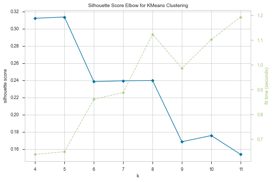

```python
model = KMeans()
visualizer = KElbowVisualizer(model, k=(4,12),metric='silhouette',locate_elbow=False)

visualizer.fit(df_clean)    # Fit the data to the visualizer
visualizer.poof()    # Draw/show/poof the data
```

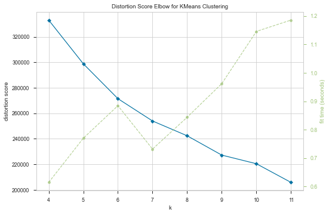

```python
visualizer = KElbowVisualizer(model, k=(4,12),locate_elbow=False)
visualizer.fit(df_clean)    # Fit the data to the visualizer
visualizer.poof()
```

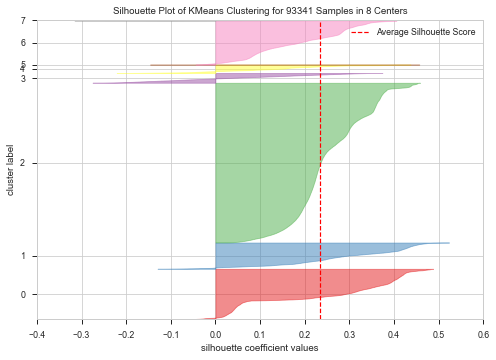

```python
optimal_parameter = 8

model = KMeans(optimal_parameter)
visualizer = SilhouetteVisualizer(model)

visualizer.fit(df_clean)    # Fit the data to the visualizer
visualizer.poof()
```

```python
from sklearn.manifold import TSNE
```

```python
k_means = KMeans(optimal_parameter)
k_means.fit(df_clean.copy())
clusters_k_means = k_means.labels_
```

```python
#tsne = TSNE()
#T = tsne.fit_transform(df_clean.copy())
```

```python
#plt.figure(figsize=(8,8))
#plt.title('Représentation du jeu de données via T-SNE')
#sns.scatterplot(T[:,0], T[:,1],hue=clusters_k_means,legend='full',palette="hls")
```

## DBSCAN: Not working well

```python
from sklearn.cluster import DBSCAN
from sklearn.metrics import silhouette_score
```

```python
dbs = DBSCAN(eps = 1,
             min_samples=5).fit(df_clean.copy())
```

```python
dbs.labels_
```

```
array([0, 0, 0, ..., 0, 0, 0])
```

```python
silhouette_score(df_clean,dbs.labels_)
```

```
0.2439758892515649
```

```python
from collections import Counter

Counter(dbs.labels_)
```

```
Counter({0: 90801,
         -1: 2354,
         1: 106,
         2: 7,
         16: 5,
         3: 5,
         4: 5,
         14: 4,
         5: 5,
         12: 6,
         17: 4,
         10: 5,
         13: 4,
         6: 6,
         11: 4,
         7: 6,
         8: 6,
         9: 4,
         15: 4})
```

```python
# We put this section in comments to save in computing time, as this visualisation
# is not very insightful for our project

#tsne = TSNE()
#T = tsne.fit_transform(df_clean.copy())
```

```python
#plt.figure(figsize=(8,8))
#plt.title('Représentation du jeu de données via T-SNE')
#sns.scatterplot(T[:,0], T[:,1],hue=dbs.labels_,legend='full',palette="hls")
```

```python
cat_df_clean = df_clean.assign(Cluster=dbs.labels_)
```

```python
cat_df_clean['Cluster'].value_counts().sort_values()
```

```
 9         4
 15        4
 14        4
 13        4
 11        4
 17        4
 4         5
 5         5
 10        5
 16        5
 3         5
 8         6
 7         6
 6         6
 12        6
 2         7
 1       106
-1      2354
 0     90801
Name: Cluster, dtype: int64
```

```python
df.reset_index(drop=True,inplace=True)
df
```

|  | customer_unique_id | customer_state | payment_value | payment_type | product_category_name | review_score | freight_value | geolocation_lat | geolocation_lng | order_purchase_date | pca_comp0 | pca_comp1 | pca_comp2 | pca_comp3 | pca_comp4 | pca_comp5 | pca_comp6 | pca_comp7 | pca_comp8 | pca_comp9 | pca_comp10 | pca_comp11 | pca_comp12 | pca_comp13 | pca_comp14 |
| --- | --- | --- | --- | --- | --- | --- | --- | --- | --- | --- | --- | --- | --- | --- | --- | --- | --- | --- | --- | --- | --- | --- | --- | --- | --- |
| 0 | 0000366f3b9a7992bf8c76cfdf3221e2 | SP | -0.109922 | credit_card | [bed_bath_table] | 0.665636 | -0.467108 | -0.385188 | -0.158598 | 2018-05-10 | 0.837493 | 0.358341 | 0.143099 | 0.060319 | 0.029797 | 0.012406 | 0.062032 | 0.012884 | 0.000182 | -0.010682 | -0.005460 | -0.012353 | -0.013346 | -0.007543 | -0.007187 |
| 1 | 0000b849f77a49e4a4ce2b2a4ca5be3f | SP | -0.287416 | credit_card | [health_beauty] | -0.108233 | -0.602918 | -0.424141 | -0.148105 | 2018-05-07 | -0.520564 | 0.749867 | 0.154191 | 0.036222 | 0.058078 | 0.031399 | 0.081124 | 0.014441 | 0.000469 | -0.012099 | -0.007424 | -0.018176 | -0.010730 | -0.011623 | -0.010943 |
| 2 | 0000f46a3911fa3c0805444483337064 | SC | -0.196078 | credit_card | [stationery] | -0.882101 | -0.276022 | -1.133464 | -0.603268 | 2017-03-10 | -0.026085 | -0.055903 | -0.051734 | -0.020163 | -0.044972 | -0.028402 | -0.124212 | -0.042481 | -0.004955 | 0.038741 | 0.033974 | 0.095662 | 0.114069 | 0.211343 | 0.906654 |
| 3 | 0000f6ccb0745a6a4b88665a16c9f078 | PA | -0.261994 | credit_card | [telephony] | -0.108233 | -0.261013 | 3.536694 | -0.565752 | 2017-10-12 | -0.034814 | -0.081859 | -0.083444 | -0.029173 | -0.085498 | -0.066438 | -0.442752 | 0.836703 | -0.010257 | -0.134980 | -0.068456 | -0.092887 | -0.060119 | -0.051837 | -0.035532 |
| 4 | 0004aac84e0df4da2b147fca70cf8255 | SP | -0.024835 | credit_card | [telephony] | 0.665636 | -0.288102 | -0.414623 | -0.316054 | 2017-11-14 | -0.034814 | -0.081859 | -0.083444 | -0.029173 | -0.085498 | -0.066438 | -0.442752 | 0.836703 | -0.010257 | -0.134980 | -0.068456 | -0.092887 | -0.060119 | -0.051837 | -0.035532 |
| ... | ... | ... | ... | ... | ... | ... | ... | ... | ... | ... | ... | ... | ... | ... | ... | ... | ... | ... | ... | ... | ... | ... | ... | ... | ... |
| 93336 | fffcf5a5ff07b0908bd4e2dbc735a684 | PE | 6.068458 | credit_card | [health_beauty] | 0.665636 | 17.302417 | 2.281493 | 2.372823 | 2017-06-08 | -0.520564 | 0.749867 | 0.154191 | 0.036222 | 0.058078 | 0.031399 | 0.081124 | 0.014441 | 0.000469 | -0.012099 | -0.007424 | -0.018176 | -0.010730 | -0.011623 | -0.010943 |
| 93337 | fffea47cd6d3cc0a88bd621562a9d061 | BA | -0.198615 | credit_card | [baby] | -0.108233 | -0.185604 | 1.595088 | 1.781902 | 2017-12-10 | -0.023087 | -0.061196 | -0.058397 | -0.025320 | -0.051132 | -0.031586 | -0.160690 | -0.067731 | -0.016735 | 0.079939 | 0.036648 | 0.189756 | 0.864938 | -0.357007 | -0.127811 |
| 93338 | ffff371b4d645b6ecea244b27531430a | MT | -0.155476 | credit_card | [auto] | 0.665636 | -0.080543 | 1.663314 | -2.297592 | 2017-02-07 | -0.031656 | -0.076436 | -0.075535 | -0.030553 | -0.074995 | -0.055374 | -0.320835 | -0.335125 | 0.719195 | -0.401721 | -0.145773 | -0.133821 | -0.080374 | -0.064585 | -0.043319 |
| 93339 | ffff5962728ec6157033ef9805bacc48 | ES | -0.122626 | credit_card | [watches_gifts] | 0.665636 | -0.222210 | 0.009019 | 1.113077 | 2018-05-02 | -0.049885 | -0.125862 | -0.148947 | -0.103308 | -0.328705 | -0.742299 | 0.467357 | 0.046128 | 0.001239 | -0.031136 | -0.019891 | -0.036878 | -0.027435 | -0.027411 | -0.020818 |
| 93340 | ffffd2657e2aad2907e67c3e9daecbeb | PR | -0.218761 | credit_card | [perfumery] | 0.665636 | -0.373029 | -0.760050 | -0.802333 | 2017-05-02 | -0.030147 | -0.063294 | -0.059849 | -0.027328 | -0.054586 | -0.037055 | -0.180952 | -0.074576 | -0.002801 | 0.101151 | 0.096462 | 0.857753 | -0.364637 | -0.169035 | -0.090881 |

93341 rows × 25 columns

```python
customer_df = customer_df.assign(Cluster_k_means=k_means.labels_)
customer_df
```

|  | customer_unique_id | customer_state | payment_value | payment_type | product_category_name | review_score | freight_value | geolocation_lat | geolocation_lng | order_purchase_date | Cluster_k_means |
| --- | --- | --- | --- | --- | --- | --- | --- | --- | --- | --- | --- |
| 0 | 0000366f3b9a7992bf8c76cfdf3221e2 | SP | 141.90 | credit_card | [bed_bath_table] | 5.0 | 12.00 | -23.340262 | -46.831085 | 2018-05-10 | 5 |
| 1 | 0000b849f77a49e4a4ce2b2a4ca5be3f | SP | 27.19 | credit_card | [health_beauty] | 4.0 | 8.29 | -23.559044 | -46.788516 | 2018-05-07 | 5 |
| 2 | 0000f46a3911fa3c0805444483337064 | SC | 86.22 | credit_card | [stationery] | 3.0 | 17.22 | -27.543010 | -48.634938 | 2017-03-10 | 1 |
| 3 | 0000f6ccb0745a6a4b88665a16c9f078 | PA | 43.62 | credit_card | [telephony] | 4.0 | 17.63 | -1.312726 | -48.482748 | 2017-10-12 | 7 |
| 4 | 0004aac84e0df4da2b147fca70cf8255 | SP | 196.89 | credit_card | [telephony] | 5.0 | 16.89 | -23.505588 | -47.469820 | 2017-11-14 | 5 |
| ... | ... | ... | ... | ... | ... | ... | ... | ... | ... | ... | ... |
| 93336 | fffcf5a5ff07b0908bd4e2dbc735a684 | PE | 4134.84 | credit_card | [health_beauty] | 5.0 | 497.42 | -8.362654 | -36.562103 | 2017-06-08 | 3 |
| 93337 | fffea47cd6d3cc0a88bd621562a9d061 | BA | 84.58 | credit_card | [baby] | 4.0 | 19.69 | -12.217900 | -38.959237 | 2017-12-10 | 2 |
| 93338 | ffff371b4d645b6ecea244b27531430a | MT | 112.46 | credit_card | [auto] | 5.0 | 22.56 | -11.834705 | -55.508145 | 2017-02-07 | 7 |
| 93339 | ffff5962728ec6157033ef9805bacc48 | ES | 133.69 | credit_card | [watches_gifts] | 5.0 | 18.69 | -21.126170 | -41.672396 | 2018-05-02 | 5 |
| 93340 | ffffd2657e2aad2907e67c3e9daecbeb | PR | 71.56 | credit_card | [perfumery] | 5.0 | 14.57 | -25.445705 | -49.442463 | 2017-05-02 | 0 |

93341 rows × 11 columns

## Cluster characteristics

```python
clustered_cust_df = customer_df.groupby('Cluster_k_means')
clustered_cust_df.agg({
    'customer_unique_id': 'count',
    'payment_value':'mean',
    'review_score' :'mean',
    'freight_value' :'mean',
    'geolocation_lat' :'mean',
    'geolocation_lng' :'mean',
  })
```

| Cluster_k_means | customer_unique_id | payment_value | review_score | freight_value | geolocation_lat | geolocation_lng |
| --- | --- | --- | --- | --- | --- | --- |
| 0 | 13843 | 168.474467 | 4.632429 | 22.846107 | -26.249855 | -51.063124 |
| 1 | 15835 | 195.698708 | 1.874290 | 22.165011 | -22.586112 | -46.205155 |
| 2 | 8234 | 204.999581 | 3.990205 | 33.979863 | -8.757256 | -38.476960 |
| 3 | 62 | 12312.965161 | 2.943241 | 454.990806 | -20.438585 | -46.212246 |
| 4 | 2201 | 1510.557088 | 3.831688 | 126.394489 | -20.021071 | -45.845977 |
| 5 | 50537 | 157.790174 | 4.754151 | 18.998171 | -22.105484 | -45.733408 |
| 6 | 1 | 109312.640000 | 1.000000 | 224.080000 | -22.900792 | -43.185126 |
| 7 | 2628 | 222.722173 | 4.139872 | 37.053010 | -8.002244 | -53.583751 |

## Etude de la sensibilité temporelle

Nous allons faire une analyse en regardant 0, 3, 6, 9, et 12 mois d'offset, avec des datasets couvrant 12 mois à chaque fois. Cela nous permettra d'éviter des problèmes de saisonnalité

```python
customer_df
```

|  | customer_unique_id | customer_state | payment_value | payment_type | product_category_name | review_score | freight_value | geolocation_lat | geolocation_lng | order_purchase_date | Cluster_k_means |
| --- | --- | --- | --- | --- | --- | --- | --- | --- | --- | --- | --- |
| 0 | 0000366f3b9a7992bf8c76cfdf3221e2 | SP | 141.90 | credit_card | [bed_bath_table] | 5.0 | 12.00 | -23.340262 | -46.831085 | 2018-05-10 | 5 |
| 1 | 0000b849f77a49e4a4ce2b2a4ca5be3f | SP | 27.19 | credit_card | [health_beauty] | 4.0 | 8.29 | -23.559044 | -46.788516 | 2018-05-07 | 5 |
| 2 | 0000f46a3911fa3c0805444483337064 | SC | 86.22 | credit_card | [stationery] | 3.0 | 17.22 | -27.543010 | -48.634938 | 2017-03-10 | 1 |
| 3 | 0000f6ccb0745a6a4b88665a16c9f078 | PA | 43.62 | credit_card | [telephony] | 4.0 | 17.63 | -1.312726 | -48.482748 | 2017-10-12 | 7 |
| 4 | 0004aac84e0df4da2b147fca70cf8255 | SP | 196.89 | credit_card | [telephony] | 5.0 | 16.89 | -23.505588 | -47.469820 | 2017-11-14 | 5 |
| ... | ... | ... | ... | ... | ... | ... | ... | ... | ... | ... | ... |
| 93336 | fffcf5a5ff07b0908bd4e2dbc735a684 | PE | 4134.84 | credit_card | [health_beauty] | 5.0 | 497.42 | -8.362654 | -36.562103 | 2017-06-08 | 3 |
| 93337 | fffea47cd6d3cc0a88bd621562a9d061 | BA | 84.58 | credit_card | [baby] | 4.0 | 19.69 | -12.217900 | -38.959237 | 2017-12-10 | 2 |
| 93338 | ffff371b4d645b6ecea244b27531430a | MT | 112.46 | credit_card | [auto] | 5.0 | 22.56 | -11.834705 | -55.508145 | 2017-02-07 | 7 |
| 93339 | ffff5962728ec6157033ef9805bacc48 | ES | 133.69 | credit_card | [watches_gifts] | 5.0 | 18.69 | -21.126170 | -41.672396 | 2018-05-02 | 5 |
| 93340 | ffffd2657e2aad2907e67c3e9daecbeb | PR | 71.56 | credit_card | [perfumery] | 5.0 | 14.57 | -25.445705 | -49.442463 | 2017-05-02 | 0 |

93341 rows × 11 columns

La date d'achat la plus récente est la suivante:

```python
customer_df['order_purchase_date'] = customer_df['order_purchase_date'].astype(
    'datetime64')
```

```python
max(customer_df['order_purchase_date'])
```

```
Timestamp('2018-08-29 00:00:00')
```

```python
# Initializing the last twelve months
start_date_0 = Timestamp('2018-08-29 00:00:00')
time_delta = datetime.timedelta(days=365)
date_minus_12m_0 = start_date_0 - time_delta

#Offsetter going to be used to move the calculus window
off_setter = datetime.timedelta(days=90)

# Initializing the last twelve months + 3 months offset
start_date_3m = start_date_0 - off_setter
date_minus_12m_1 = start_date_3m - time_delta

# Initializing the twelve months + 6 months offset
start_date_6m = start_date_3m - off_setter
date_minus_12m_2 = start_date_6m - time_delta

# Initializing the twelve months + 9 months offset
start_date_9m = start_date_6m - off_setter
date_minus_12m_3 = start_date_9m - time_delta

# Initializing the twelve months + 12 months offset
start_date_12m = start_date_9m - off_setter
date_minus_12m_4 = start_date_12m - time_delta
```

```python
# In the code below, we are initializing the start and end date fir each of the data windows
LTM_mask1 = customer_df['order_purchase_date'] < start_date_0
LTM_mask2 = customer_df['order_purchase_date'] > date_minus_12m_0
LTM1 = LTM_mask1 & LTM_mask2

LTM_mask3 = customer_df['order_purchase_date'] < start_date_3m
LTM_mask4 = customer_df['order_purchase_date'] > date_minus_12m_1
LTM3 = LTM_mask3 & LTM_mask4

LTM_mask5 = customer_df['order_purchase_date'] < start_date_6m
LTM_mask6 = customer_df['order_purchase_date'] > date_minus_12m_2
LTM5 = LTM_mask5 & LTM_mask6

LTM_mask7 = customer_df['order_purchase_date'] < start_date_9m
LTM_mask8 = customer_df['order_purchase_date'] > date_minus_12m_3
LTM7 = LTM_mask7 & LTM_mask8

LTM_mask9 = customer_df['order_purchase_date'] < start_date_12m
LTM_mask10 = customer_df['order_purchase_date'] > date_minus_12m_4
LTM9 = LTM_mask9 & LTM_mask10
```

```python
#We are initializing the windows with loc function
customer_df_0m = customer_df.loc[LTM1]
customer_df_3m = customer_df.loc[LTM3]
customer_df_6m = customer_df.loc[LTM5]
customer_df_9m = customer_df.loc[LTM7]
customer_df_12m = customer_df.loc[LTM9]

customer_df_0m.reset_index(drop = True, inplace=True)
customer_df_3m.reset_index(inplace=True, drop = True)
customer_df_6m.reset_index(inplace=True, drop = True)
customer_df_9m.reset_index(inplace=True, drop = True)
customer_df_12m.reset_index(inplace=True, drop = True)
```

Ecrivons une fonction générique pour faire les différentes transformations dont nous avons besoin.

```python
def full_prep(df_to_ml):
    """Takes a dataframe to be prepared for Machine Learning. Returns a new dataframe that is full prepared
    for Machine Learning. We use Multilabel binarizer, PCA and Standard Scalers"""
    #1 - Using Multilabel binarizer on product_category for each of the data windows
    mlb = MultiLabelBinarizer()
    mlb.fit_transform(df_to_ml['product_category_name'])
    prod_df = pd.DataFrame(mlb.fit_transform(df_to_ml['product_category_name']),
                   columns=mlb.classes_,
                   index=df_to_ml['product_category_name'].index)

    #2 - PCA on the output binary features of Binarizer
    pca = PCA(n_components = 0.8)
    prod_pca = pca.fit_transform(prod_df)
    n_comp = prod_pca.shape[1]
    print("Number of components is: " + str(n_comp))

    pca_labels =[]
    for x in range(n_comp):
        pca_labels.append('pca_comp'+str(x))
    prod_pca_df = pd.DataFrame(prod_pca, columns=pca_labels)

    #3 - Scaling of numerical features
    numerics = ['payment_value','review_score','freight_value','geolocation_lat','geolocation_lng']
    ss = StandardScaler()
    df_to_ml_ss = df_to_ml.copy()
    df_to_ml_ss[numerics] = ss.fit_transform(df_to_ml_ss[numerics])
    prod_pca_df['customer_unique_id'] = df_to_ml_ss['customer_unique_id']

    #4 - Merging the two outputs
    final_df_to_ml = pd.merge(df_to_ml_ss,prod_pca_df,on='customer_unique_id',how='left')
    return final_df_to_ml
```

```python
def full_viz(df_to_ml):
    """Takes a pre-processed database as input. Returns a database containing the data that is useful
    for clustering only. Prints out the graphs that shows the optimal k_mean parameter"""
    df = df_to_ml.copy()
    n = len(df)

    #We are dropping the useless columns
    df_cleaned = df.drop(columns=['customer_unique_id','customer_state','payment_type','product_category_name', 'order_purchase_date'])
    df_cleaned.reset_index(inplace=True,drop=True)

    #Initialising the graphs that allow to find the optimal parameters
    model = KMeans()
    visualizer = KElbowVisualizer(model, k=(4,12),metric='silhouette',locate_elbow=False)

    visualizer.fit(df_cleaned)    # Fit the data to the visualizer
    visualizer.poof()

    visualizer = KElbowVisualizer(model, k=(4,12),locate_elbow=False)
    visualizer.fit(df_cleaned)    # Fit the data to the visualizer
    visualizer.poof()

    return df_cleaned
```

```python
def full_clusters(cleaned_df, opt_k_means, original_df):
    """
    Takes a ready for clustering dataFrame, an optimal k_means parameter, and the original df before preprocessing
    Returns a clustered_df containing the clusters for each ID, and the customer_unique_ID.
    """
    k_means = KMeans(opt_k_means)

    #Showing the silhouette graph for the k_means model
    visualizer = SilhouetteVisualizer(k_means)
    visualizer.fit(cleaned_df)    # Fit the data to the visualizer
    visualizer.poof()

    #We are adding the labels of the cluster to the df, and we add also the customer_unique_id
    k_means.fit(cleaned_df.copy())
    clusters_k_means = k_means.labels_
    clustered_df_clean = cleaned_df.assign(Cluster=clusters_k_means, customer_unique_id=original_df['customer_unique_id'])
    return clustered_df_clean
```

```python
def comparison(clustered_df_1, clustered_df_2):
    """
    Takes two clustered dataframe as input, and returns the value of the adj rand score that is calculated
    on the intersection of the two dataFrames.
    """
    #We calculate the intersection of the two dataframes thanks to customer_unique_id. This will be our base
    # to calculate the adj rand score
    extraction1 = clustered_df_1[clustered_df_1['customer_unique_id'].isin(clustered_df_2['customer_unique_id'])]
    extraction2 = clustered_df_2[clustered_df_2['customer_unique_id'].isin(clustered_df_1['customer_unique_id'])]
    value = adjusted_rand_score(extraction1['Cluster'],extraction2['Cluster'])
    return value
```

```python
def sensitivity(df,opt_param):
    temp1 = full_prep(df)
    temp2 = full_viz(temp1)
    temp3 = full_clusters(temp2, opt_param, df)
    return temp3
```

```
Number of components is: 16
```

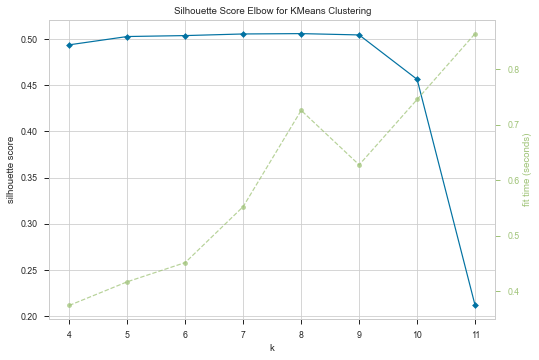

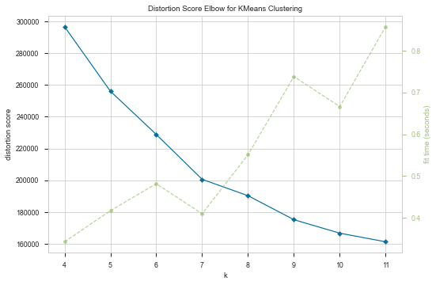

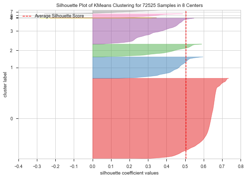

```python
df_1 = sensitivity(customer_df_0m, 8)
```

```
Number of components is: 15
```

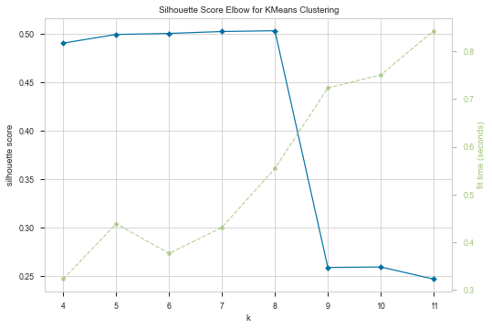

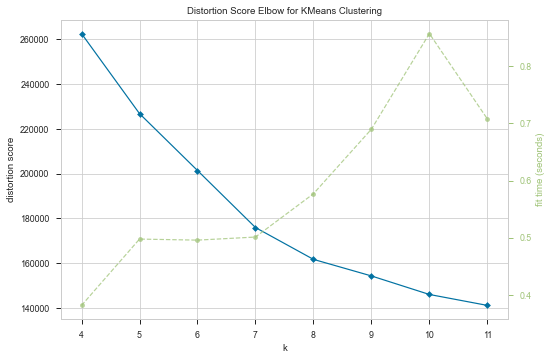

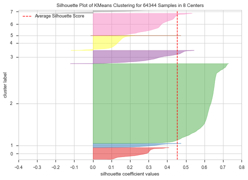

```python
df_2 = sensitivity(customer_df_3m, 8)
```

```
Number of components is: 15
```

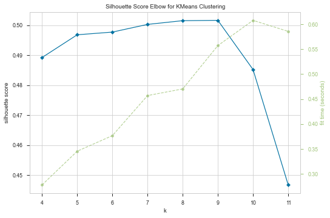

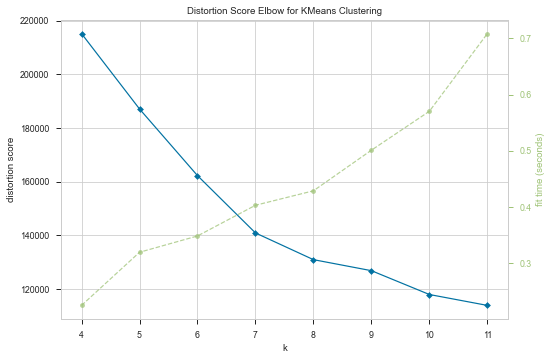

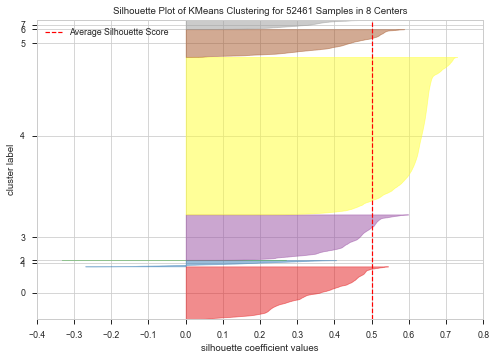

```python
df_3 = sensitivity(customer_df_6m, 8)
```

```
Number of components is: 15
```

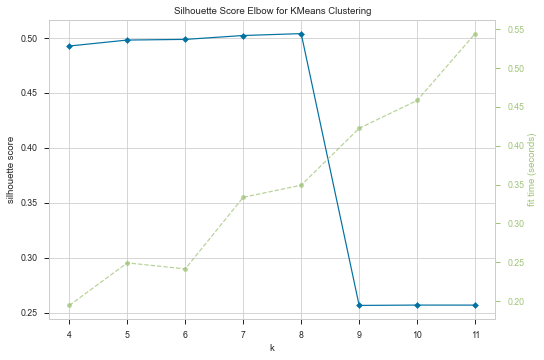

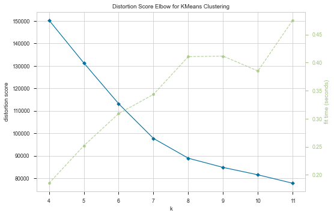

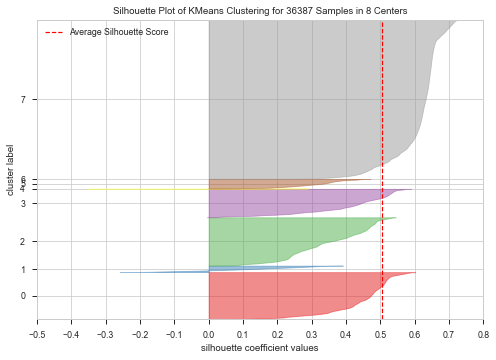

```python
df_4 = sensitivity(customer_df_9m, 8)
```

```
Number of components is: 16
```

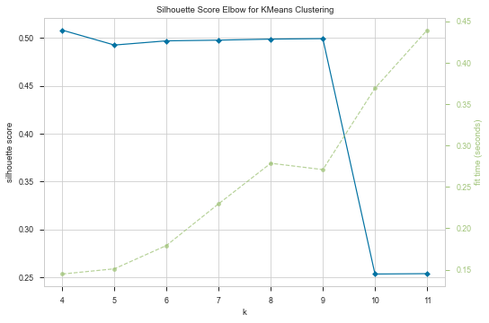

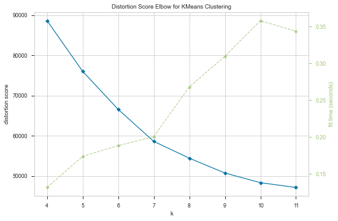

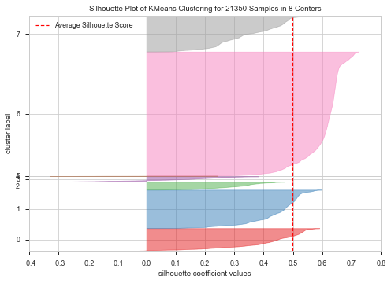

```python
df_5 = sensitivity(customer_df_12m, 8)
```

```python
df_list = [df_1, df_2, df_3, df_4, df_5]
```

```python
res = []
```

```python
for dataf in df_list:
    for datag in df_list:
        res.append(comparison(dataf,datag))
```

```python
x = np.reshape(res, (5, 5)).T
x
```

```
array([[1.        , 0.99988486, 0.99910223, 0.99932355, 0.6305803 ],
       [0.99988486, 1.        , 0.99916221, 0.99923115, 0.66096922],
       [0.99910223, 0.99916221, 1.        , 0.99985267, 0.66412294],
       [0.99932355, 0.99923115, 0.99985267, 1.        , 0.66533352],
       [0.6305803 , 0.66096922, 0.66412294, 0.66533352, 1.        ]])
```

```python
labels = ['df_1_0m', 'df_2_3m', 'df_3_6m', 'df_4_9m', 'df_5_12m']

res_matrix = pd.DataFrame(
    data=x,
    index=labels,
    columns=labels
)
```

```python
res_matrix
# Adj rand score matrix
```

|  | df_1_0m | df_2_3m | df_3_6m | df_4_9m | df_5_12m |
| --- | --- | --- | --- | --- | --- |
| df_1_0m | 1.000000 | 0.999885 | 0.999102 | 0.999324 | 0.630580 |
| df_2_3m | 0.999885 | 1.000000 | 0.999162 | 0.999231 | 0.660969 |
| df_3_6m | 0.999102 | 0.999162 | 1.000000 | 0.999853 | 0.664123 |
| df_4_9m | 0.999324 | 0.999231 | 0.999853 | 1.000000 | 0.665334 |
| df_5_12m | 0.630580 | 0.660969 | 0.664123 | 0.665334 | 1.000000 |